# Cypripedium candidum raw and function-based MPMs: long-format vignette

Richard P. Shefferson, Shun Kurokawa, and Johan Ehrlén

This document was built in Markdown in R 4.1.1 and compiled on 02 September 2021. It covers package `lefko3` version 3.7.0.9001. This is a long-format vignette, meaning that we have tried to include a good deal more code and output than is permissible in the standard CRAN-packaged vignette. Note, however, that code that results in dramatically long output has been hashtagged to prevent the inclusion of tens of pages of output that may confuse the user. In these cases, please remove the hashtag to see the output.

## CASE STUDIES OF AMERICAN *Cypripedium candidum* POPULATION

In this vignette, we use the `cypdata` and `cypvert` datasets to illustrate the estimation of **raw MPMs** and **function-based MPMs**. Please see the other vignettes included in package `lefko3`, as well as further vignettes posted online on [the projects page](http://www.sheffersonlab.com/projects) of the Shefferson lab website, for further demonstrations of raw MPMs, function-based MPMs, IPMs, and age-by-stage MPMs.

### ORGANISM AND POPULATION

The white lady’s slipper, *Cypripedium candidum*, is a North American perennial herb in the family Orchidaceae. It is long-lived and of conservation concern. This plant begins life by germinating from a dust seed, and becoming a protocorm, which is a special subterranean life stage found in orchids. During this stage, the plant is non-photosynthetic and completely parasitic on its mycorrhizal fungi. It spends several years as a protocorm, and previous studies suggest that it typically spends 3 years before becoming a seedling. As a seedling, it may or may not produce aboveground sprouts, often remaining entirely subterranean and coninuing its parasitic lifestyle. It may continue doing this for many years before attaining adult size, at which point it may sprout with or without flowers, or may remain underground in a condition referred to as **vegetative dormancy**. The latter condition may continue for many years, with over a decade of continuous dormancy documented in the literature (Shefferson et al. 2018).

The population from which the dataset originates is located within a state nature preserve located in northeastern Illinois, USA. The population was monitored annually from 2004 to 2009, with two monitoring sessions per year. Monitoring sessions took roughly 2 weeks each, and included complete censuses of the population divided into sections referred to as patches. Each monitoring session consisted of searches for previously recorded individuals, which were located according to coordinates relative to fixed stakes at the site, followed by a search for new individuals. Data recorded per individual included: the location, the number of non-flowering sprouts, the number of flowering sprouts, the number of flowers per flowering sprout, and the number of fruit pods per sprout (only in the second monitoring session per year, once fruiting had occurred). Location was used to infer individual identity. More information about this population and its characteristics is given in Shefferson et al. (2001) and Shefferson et al. (2017).

### OVERALL GOALS AND INITIAL CONSIDERATIONS

Our goal in this exercise will be to produce ahistorical and historical raw and function-based matrices for full comparison. We will assess the influence of history, and showcase the pros and cons of all four of these styles of MPMs. We will also illustrate the use of multiple demographic data formats via comparisons of the `cypdata` and `cypvert` datasets, which present the same information but in different input format. Where appropriate, we will provide commentary to illustrate where analyses may be shortened or altered for more typical analyses.

The horizontal dataset `cypdata`, and the ahistorical vertical dataset `cypvert` which is the same as `cypdata` but is structured differently, both include only data for the adult stages because the monitoring protocol did not include monitoring of juveniles. This is a result of the life history of these organisms, which includes substantial time belowground where individuals cannot be tracked and identified. Let’s begin by clearing the memory, loading the package, and loading the vertical and horizontal datasets.

```r
rm(list=ls(all=TRUE))
library(lefko3)

data(cypdata)
data(cypvert)
```

The dataset `cypdata` is organized in horizontal format, meaning that rows correspond to unique individuals and columns correspond to stage in particular years. Looking at the original Excel spreadsheet (below), you will note a repeating pattern in the names of the columns. Package `lefko3` includes functions to handle data in horizontal format, as well as functions to handle vertically formatted data (i.e. data for individuals is broken up across rows, where each row is a unique combination of individual and year in time *t*).

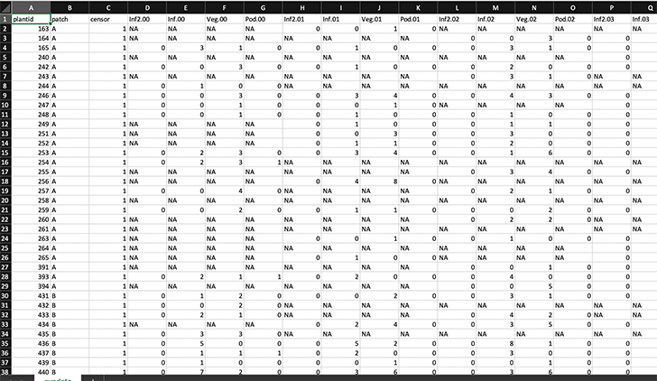

**Figure 3L.1.** Organization of the *Cypripedium candidum* horizontal dataset, as viewed in Microsoft Excel.

When we imported the dataset into R, we utilized this structure, and R handles the variables accordingly. We can see this in the summary for the dataset, as below (we also use `dim()` to calculate the dimensions of the dataset).

```r
dim(cypdata)
```

```
#> [1] 77 27
```

```r
summary(cypdata)
```

```
#>     plantid       patch      censor     Inf2.04       Inf.04
#>  Min.   : 164.0   A:23   Min.   :1   Min.   :0    Min.   :0.0000
#>  1st Qu.: 265.0   B:35   1st Qu.:1   1st Qu.:0    1st Qu.:0.0000
#>  Median : 455.0   C:19   Median :1   Median :0    Median :0.0000
#>  Mean   : 669.1          Mean   :1   Mean   :0    Mean   :0.6923
#>  3rd Qu.: 829.0          3rd Qu.:1   3rd Qu.:0    3rd Qu.:1.0000
#>  Max.   :1560.0          Max.   :1   Max.   :0    Max.   :8.0000
#>                                      NA's   :12   NA's   :12
#>      Veg.04           Pod.04       Inf2.05            Inf.05
#>  Min.   : 0.000   Min.   :0.0   Min.   :0.00000   Min.   : 0.000
#>  1st Qu.: 1.000   1st Qu.:0.0   1st Qu.:0.00000   1st Qu.: 0.000
#>  Median : 2.000   Median :0.0   Median :0.00000   Median : 0.000
#>  Mean   : 2.923   Mean   :0.2   Mean   :0.04478   Mean   : 1.537
#>  3rd Qu.: 4.000   3rd Qu.:0.0   3rd Qu.:0.00000   3rd Qu.: 2.000
#>  Max.   :12.000   Max.   :3.0   Max.   :1.00000   Max.   :18.000
#>  NA's   :12       NA's   :12    NA's   :10        NA's   :10
#>      Veg.05          Pod.05          Inf2.06       Inf.06
#>  Min.   :0.000   Min.   :0.0000   Min.   :0    Min.   : 0.0000
#>  1st Qu.:1.000   1st Qu.:0.0000   1st Qu.:0    1st Qu.: 0.0000
#>  Median :1.000   Median :0.0000   Median :0    Median : 0.0000
#>  Mean   :2.134   Mean   :0.6567   Mean   :0    Mean   : 0.9016
#>  3rd Qu.:3.000   3rd Qu.:1.0000   3rd Qu.:0    3rd Qu.: 1.0000
#>  Max.   :9.000   Max.   :7.0000   Max.   :0    Max.   :18.0000
#>  NA's   :10      NA's   :10       NA's   :16   NA's   :16
#>      Veg.06           Pod.06          Inf2.07      Inf.07
#>  Min.   : 0.000   Min.   :0.0000   Min.   :0   Min.   :0.0000
#>  1st Qu.: 1.000   1st Qu.:0.0000   1st Qu.:0   1st Qu.:0.0000
#>  Median : 2.000   Median :0.0000   Median :0   Median :0.0000
#>  Mean   : 2.213   Mean   :0.3934   Mean   :0   Mean   :0.6271
#>  3rd Qu.: 3.000   3rd Qu.:0.0000   3rd Qu.:0   3rd Qu.:1.0000
#>  Max.   :13.000   Max.   :4.0000   Max.   :0   Max.   :7.0000
#>  NA's   :16       NA's   :16                   NA's   :18
#>      Veg.07           Pod.07          Inf2.08       Inf.08
#>  Min.   : 0.000   Min.   :0.0000   Min.   :0    Min.   : 0.0000
#>  1st Qu.: 1.000   1st Qu.:0.0000   1st Qu.:0    1st Qu.: 0.0000
#>  Median : 2.000   Median :0.0000   Median :0    Median : 0.0000
#>  Mean   : 2.627   Mean   :0.0678   Mean   :0    Mean   : 0.8868
#>  3rd Qu.: 4.000   3rd Qu.:0.0000   3rd Qu.:0    3rd Qu.: 1.0000
#>  Max.   :13.000   Max.   :1.0000   Max.   :0    Max.   :11.0000
#>  NA's   :18       NA's   :18       NA's   :24   NA's   :24
#>      Veg.08          Pod.08          Inf2.09       Inf.09
#>  Min.   : 0.00   Min.   :0.0000   Min.   :0    Min.   : 0.000
#>  1st Qu.: 1.00   1st Qu.:0.0000   1st Qu.:0    1st Qu.: 0.000
#>  Median : 2.00   Median :0.0000   Median :0    Median : 1.000
#>  Mean   : 2.83   Mean   :0.1509   Mean   :0    Mean   : 1.833
#>  3rd Qu.: 4.00   3rd Qu.:0.0000   3rd Qu.:0    3rd Qu.: 2.000
#>  Max.   :13.00   Max.   :2.0000   Max.   :0    Max.   :11.000
#>  NA's   :24      NA's   :24       NA's   :17   NA's   :17
#>      Veg.09           Pod.09
#>  Min.   : 0.000   Min.   :0.000
#>  1st Qu.: 1.000   1st Qu.:0.000
#>  Median : 1.000   Median :1.000
#>  Mean   : 2.233   Mean   :1.133
#>  3rd Qu.: 3.000   3rd Qu.:1.000
#>  Max.   :10.000   Max.   :8.000
#>  NA's   :17       NA's   :17
```

Although this dataset is in horizontal structure, many demographers prefer to keep their data in a vertical structure. Data `cypvert` is essentially the same dataset as `cypdata`, but supplied in vertical structure. Let’s look at a screenshot of the Excel spreadsheet.

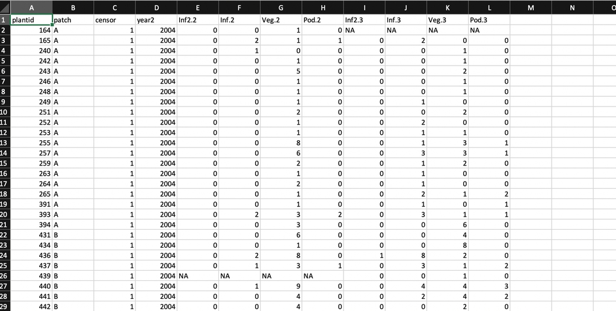

**Figure 3L.2.** Organization of the *Cypripedium candidum* vertical dataset, as viewed in Microsoft Excel.

We can see a number of key differences from the horizontal dataset. One key difference is that each row includes not just identifying information for the individual, but also there is a column identifying the year that each datum was recorded. Here. the column `year2` represents the monitoring occasion in time *t*. Some demographers include a single year of data per row, while others include two years in order to use the dataset directly in matrix estimation. Package `lefko3` can handle all of these variations.

Here we view the vertical dataset’s dimensions and summary.

```r
dim(cypvert)
```

```
#> [1] 331  12
```

```r
summary(cypvert)
```

```
#>     plantid          patch               censor      year2
#>  Min.   : 164.0   Length:331         Min.   :1   Min.   :2004
#>  1st Qu.: 391.0   Class :character   1st Qu.:1   1st Qu.:2005
#>  Median : 454.0   Mode  :character   Median :1   Median :2006
#>  Mean   : 662.8                      Mean   :1   Mean   :2006
#>  3rd Qu.: 664.0                      3rd Qu.:1   3rd Qu.:2007
#>  Max.   :1560.0                      Max.   :1   Max.   :2008
#>
#>      Inf2.2             Inf.2            Veg.2            Pod.2
#>  Min.   :0.000000   Min.   : 0.000   Min.   : 0.000   Min.   :0.0000
#>  1st Qu.:0.000000   1st Qu.: 0.000   1st Qu.: 1.000   1st Qu.:0.0000
#>  Median :0.000000   Median : 0.000   Median : 2.000   Median :0.0000
#>  Mean   :0.009646   Mean   : 0.941   Mean   : 2.534   Mean   :0.3049
#>  3rd Qu.:0.000000   3rd Qu.: 1.000   3rd Qu.: 3.000   3rd Qu.:0.0000
#>  Max.   :1.000000   Max.   :18.000   Max.   :13.000   Max.   :7.0000
#>  NA's   :20         NA's   :26       NA's   :26       NA's   :26
#>      Inf2.3             Inf.3            Veg.3           Pod.3
#>  Min.   :0.000000   Min.   : 0.000   Min.   : 0.00   Min.   :0.0000
#>  1st Qu.:0.000000   1st Qu.: 0.000   1st Qu.: 1.00   1st Qu.:0.0000
#>  Median :0.000000   Median : 0.000   Median : 1.00   Median :0.0000
#>  Mean   :0.009804   Mean   : 1.173   Mean   : 2.39   Mean   :0.4933
#>  3rd Qu.:0.000000   3rd Qu.: 1.000   3rd Qu.: 3.00   3rd Qu.:0.0000
#>  Max.   :1.000000   Max.   :18.000   Max.   :13.00   Max.   :8.0000
#>  NA's   :25         NA's   :31       NA's   :31      NA's   :31
```

This dataset is longer and narrower, with more rows and fewer columns. This is because we constructed the dataset by splitting the data for each individual across multiple rows. After three columns of identifying information (`plantid`, `patch`, and `censor`), a single column designates the time of occasion *t*, given as `year2`. This dataset then includes columns showing individual state in pairs of consecutive years corresponding to occasions *t* and *t*+1. State in occasion *t*-1 is not presented because this is an ahistorical dataset. This dataset includes the `plantid` variable, which is an individual identity term that allows us to associate rows with their individuals and so allows conversion. The `historicalize3()` function uses individual identity to reorganize datasets into historical vertical format.

Regardless of the approach used, each dataset must conform to some basic rules to make sure that R can properly process them. One important convention is to include the name of the variable only in the very first row of the spreadsheet, because name terms in rows below the first will likely change the variable definitions upon import. Another convention is to avoid including blank rows, as these are typically interpreted as extra blank data points. The most important convention, however, is consistency of data type within variables. This generally means that variables should not include both numbers and text unless ALL entries are to be interpreted as text rather than true numbers. Basically, R interprets any variable with a single text entry as being purely text, and a variable cannot include a combination of true numbers and text. So, if you wish a variable to include true numbers for use in calculations, such as size measurements or binomial indicators of reproduction, then these variables must include ONLY NUMBERS.

Before going further and standardizing our datasets, let’s consider the life history model(s) that we will be using.

#### Step 1. Life history model development

Our first key decision is how to model the life history of the organism. We generally use the **life cycle graph** approach, and encourage its use as it simplifies the process of life history model development. The decision of the life history model, however, may be more complicated than simply diagramming the life cycle of the organism. Particularly, we must decide what life stages to include, how these life stages will be defined, and how these life stages are connected to one another via survival and fecundity transitions. These considerations will be strongly influenced by whether we wish to create a raw MPM or a function-based MPM.

It might be easiest to begin our discussion with consideration of the function-based MPM, and what sort of life history model works best if we choose this approach. With a function-based MPM (which includes the integral projection model, or IPM), there are really only two considerations that we need to be concerned about. First, what stages should be included based on a purely biological understanding of the organism’s life history? Some stages may never be monitored, and so these will have to be included but dealt with via proxy rates later. In our case, for example, we never monitored germinated seeds, protocorms, and seedlings, because it is essentially impossible to do so. We will include these stages in our life history model, but we will use proxy rates for their survival transitions, since we cannot use our dataset to estimate them. Second, what is the range of stages and/or sizes that actually occur in the dataset? This question is really focused on determining which survival and fecundity transitions we CAN estimate given our dataset. One key consideration here is to assess the complete range of sizes occurring within our dataset, since we do not wish to create stages in our life cycle model that go beyond the limits of what was actually observed.

Let’s explore the range of sizes actually occurring in our dataset. There is no one variable that encapsulates the entire size of the individual in our dataset, so we will create a series of vectors that sums the numbers of sprouts that are single-flowered flowering, double-flowered flowering, and non-flowering, and use these sums as plant sizes. If we use the horizontal dataset for this purpose, then we get the following exploration.

```r
size.04 <- cypdata$Inf2.04 + cypdata$Inf.04 + cypdata$Veg.04
size.05 <- cypdata$Inf2.05 + cypdata$Inf.05 + cypdata$Veg.05
size.06 <- cypdata$Inf2.06 + cypdata$Inf.06 + cypdata$Veg.06
size.07 <- cypdata$Inf2.07 + cypdata$Inf.07 + cypdata$Veg.07
size.08 <- cypdata$Inf2.08 + cypdata$Inf.08 + cypdata$Veg.08
size.09 <- cypdata$Inf2.09 + cypdata$Inf.09 + cypdata$Veg.09

summary(c(size.04, size.05, size.06, size.07, size.08, size.09))
```

```
#>    Min. 1st Qu.  Median    Mean 3rd Qu.    Max.    NA's
#>   1.000   1.000   2.000   3.581   5.000  24.000      97
```

The summary shows that the smallest recorded size is a single sprout, and the largest is 24 sprouts. The 97 NAs are a combination of vegetative dormancy and instances of individuals being dead or simply not alive (i.e. not yet born). Given this, we might utilize the following life history model for our function-based MPMs.

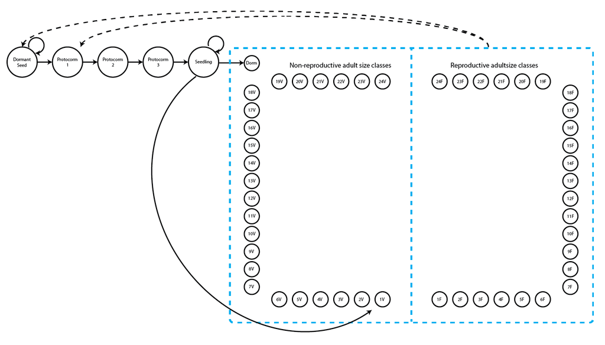

**Figure 3L.3.** Life history model of *Cypripedium candidum* for use in function-based MPMs.

We can see a variety of transitions within this figure. The juvenile stages have fairly simple transitions. New recruits may enter the population directly from germination of a seed produced the previous year, in which case they start in the protocorm 1 stage, or they may begin as dormant seed. Dormant seed may remain dormant, die, or germinate into the protocorm 1 stage. Protocorms exist for up to 3 years, yielding the protocorm 1, 2, and 3 stages, without any possibility of staying within each of these stages for more than a single year. Protocorm 3 leads to a seedling stage, in which the plant may persist for many years before becoming mature. Here, maturity does not really refer to reproduction *per se*, but rather to a morphology indistinguishable from a reproductive plant except for the lack of a flower. The first mature stage is usually either vegetative dormancy (dorm), during which time the plant does not sprout, or a small, non-flowering adult (1V). Once in this portion of the life history, the plant may transition among 49 mature stages, including vegetative dormancy, 1-24 shoots without flowers, or 1-24 shoots with at least one flower.

Now that we have our life history model, we will need to describe the life history characterizing the dataset, matching it to our analyses properly with a `stageframe` for our *Cypripedium candidum* dataset. This is a vitally important step, and most instances of errors occurring in the use of `lefko3` originate from an inappropriate `stageframe` being used in an analysis. Since this analysis will be function-based, we will include all possible size classes here. If constructing raw matrices, all sizes that occur in the dataset need to be accounted for in a way that is both natural and parsimonious with respect to the numbers of individuals moving through actual transitions. If constructing function-based matrices, such as IPMs, then representative sizes at systematic increments will be satisfactory. Since size is count-based in the *Cypripedium candidum* case, we will use all numbers of stems that might occur from 0 to the maximum in the dataset, representing the life history diagram shown in the beginning of this chapter.

```r
sizevector <- c(0, 0, 0, 0, 0, seq(from = 0, t = 24), seq(from = 1, to = 24))
stagevector <- c("SD", "P1", "P2", "P3", "SL", "D", "V1", "V2", "V3", "V4", "V5",
  "V6", "V7", "V8", "V9", "V10", "V11", "V12", "V13", "V14", "V15", "V16", "V17",
  "V18", "V19", "V20", "V21", "V22", "V23", "V24", "F1", "F2", "F3", "F4", "F5",
  "F6", "F7", "F8", "F9", "F10", "F11", "F12", "F13", "F14", "F15", "F16", "F17",
  "F18", "F19", "F20", "F21", "F22", "F23", "F24")
repvector <- c(0, 0, 0, 0, 0, rep(0, 25), rep(1, 24))
obsvector <- c(0, 0, 0, 0, 0, 0, rep(1, 48))
matvector <- c(0, 0, 0, 0, 0, rep(1, 49))
immvector <- c(0, 1, 1, 1, 1, rep(0, 49))
propvector <- c(1, rep(0, 53))
indataset <- c(0, 0, 0, 0, 0, rep(1, 49))
comments <- c("Dormant seed", "Yr1 protocorm", "Yr2 protocorm", "Yr3 protocorm",
  "Seedling", "Veg dorm", "Veg adult 1 stem", "Veg adult 2 stems",
  "Veg adult 3 stems", "Veg adult 4 stems", "Veg adult 5 stems",
  "Veg adult 6 stems", "Veg adult 7 stems", "Veg adult 8 stems",
  "Veg adult 9 stems", "Veg adult 10 stems", "Veg adult 11 stems",
  "Veg adult 12 stems", "Veg adult 13 stems", "Veg adult 14 stems",
  "Veg adult 15 stems", "Veg adult 16 stems", "Veg adult 17 stems",
  "Veg adult 18 stems", "Veg adult 19 stems", "Veg adult 20 stems",
  "Veg adult 21 stems", "Veg adult 22 stems", "Veg adult 23 stems",
  "Veg adult 24 stems", "Flo adult 1 stem", "Flo adult 2 stems",
  "Flo adult 3 stems", "Flo adult 4 stems", "Flo adult 5 stems",
  "Flo adult 6 stems", "Flo adult 7 stems", "Flo adult 8 stems",
  "Flo adult 9 stems", "Flo adult 10 stems", "Flo adult 11 stems",
  "Flo adult 12 stems", "Flo adult 13 stems", "Flo adult 14 stems",
  "Flo adult 15 stems", "Flo adult 16 stems", "Flo adult 17 stems",
  "Flo adult 18 stems", "Flo adult 19 stems", "Flo adult 20 stems",
  "Flo adult 21 stems", "Flo adult 22 stems", "Flo adult 23 stems",
  "Flo adult 24 stems")

cypframe_fb <- sf_create(sizes = sizevector, stagenames = stagevector,
  repstatus = repvector, obsstatus = obsvector, matstatus = matvector,
  propstatus = propvector, immstatus = immvector, indataset = indataset,
  comments = comments)
cypframe_fb
```

```
#>    stage size repstatus obsstatus propstatus immstatus matstatus indataset
#> 1     SD    0         0         0          1         0         0         0
#> 2     P1    0         0         0          0         1         0         0
#> 3     P2    0         0         0          0         1         0         0
#> 4     P3    0         0         0          0         1         0         0
#> 5     SL    0         0         0          0         1         0         0
#> 6      D    0         0         0          0         0         1         1
#> 7     V1    1         0         1          0         0         1         1
#> 8     V2    2         0         1          0         0         1         1
#> 9     V3    3         0         1          0         0         1         1
#> 10    V4    4         0         1          0         0         1         1
#> 11    V5    5         0         1          0         0         1         1
#> 12    V6    6         0         1          0         0         1         1
#> 13    V7    7         0         1          0         0         1         1
#> 14    V8    8         0         1          0         0         1         1
```

[output cut: 150 more lines]

A close look at the resulting object, `cypframe`, shows a data frame that includes the following information in order for each stage: the stage’s name, the associated size, its reproductive status, its status as an observable stage, its status as a propagule stage, its status as an immature stage, its status as a mature stage, whether it occurs in the dataset, the half-width of its size class bin, the minimum and maximum ages associated with the stage, the minimum and maximum of its size class bin, the centroid of its size class bin (currently the arithmetic mean), its full size class bin width, and a comments field describing the stage. Stage names and combinations of characteristics must be unique to prevent estimation errors, and the comments field may be edited to include any information deemed pertinent.

How does the life history model differ if we wish to develop a raw MPM? The key difference is that we need to consider how large our dataset is, and to create only as many stages as can be routinely transitioned to and from based on the data. The life history model above in Fig. 3L.3, for example, is not useable for raw MPMs because we have cut the size bins too finely - it is likely that in a typical year, only some of these stages will have individuals actually transitioning between them. The impact of this is that we will end up with many 0s for transitions that, in a sufficiently large population, should not equal 0.

To deal with this problem we need to explore the dataset to determine a reasonable number of life history stages and on where the breaks should occur between these stages. A number of means exist to do this, and users should see Caswell (2001) and Kendall et al. (2019) for good discussions of the topic. Here, we advocate plotting a size distribution, and assessing natural breaks using the Jenks natural breaks algorithm (Jenks 1967). Let’s take a look at a distribution plot of size.

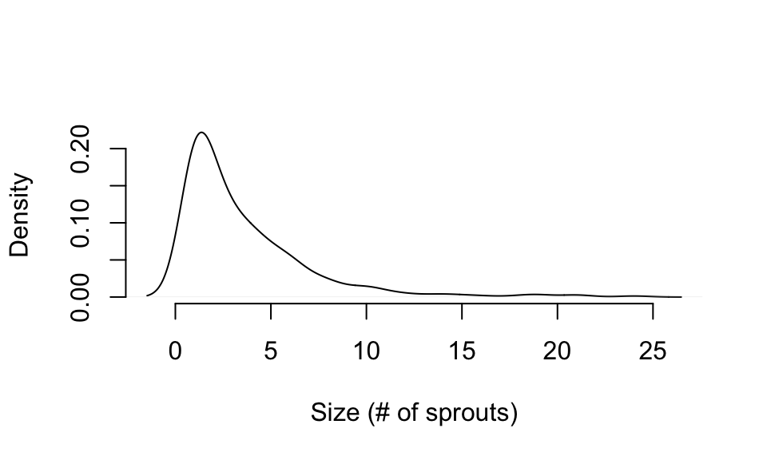

Figure 3L.4. Distribution of size in Cypripedium candidum

```r
plot(density(c(size.04, size.05, size.06, size.07, size.08, size.09), na.rm = TRUE),
  main = "", xlab = "Size (# of sprouts)", bty = "n")
```

We can see here that most individuals are small, and so our size data is densest around 1-2 sprouts or so. Large individuals are rare, so we will need to make size bins larger for big plants than for small plants. Let’s try finding some natural breaks with the Jenks algorithm. We will try to separate the data into 5 stages, which would result in 11 total life history stages in our like history (1 dormant seed, 3 protocorms, 1 seedling, 1 vegatative dormant stage, and 5 size-classified adult stages). To separate the size data into 5 stages, we need to identify a total of 6 breaks including the minimum and maximum. Please make sure that you have installed the `BAMMtools` package for this to work properly.

```r
BAMMtools::getJenksBreaks(c(size.04, size.05, size.06, size.07, size.08, size.09),
  k = 6)
```

```
#> [1]  1  2  5  8 15 24
```

The Jenks method gave us a series of natural breaks in our dataset. We should now build a stageframe using these breaks.

```r
sizevector <- c(0, 0, 0, 0, 0, 0, 1, 3, 6, 11, 19.5)
stagevector <- c("SD", "P1", "P2", "P3", "SL", "D", "XSm", "Sm", "Md", "Lg",
  "XLg")
repvector <- c(0, 0, 0, 0, 0, 0, 1, 1, 1, 1, 1)
obsvector <- c(0, 0, 0, 0, 0, 0, 1, 1, 1, 1, 1)
matvector <- c(0, 0, 0, 0, 0, 1, 1, 1, 1, 1, 1)
immvector <- c(0, 1, 1, 1, 1, 0, 0, 0, 0, 0, 0)
propvector <- c(1, 0, 0, 0, 0, 0, 0, 0, 0, 0, 0)
indataset <- c(0, 0, 0, 0, 0, 1, 1, 1, 1, 1, 1)
binvec <- c(0, 0, 0, 0, 0, 0.5, 0.5, 1.5, 1.5, 3.5, 5)

comments <- c("Dormant seed", "1st yr protocorm", "2nd yr protocorm",
  "3rd yr protocorm", "Seedling", "Dormant adult",
  "Extra small adult (1 shoot)", "Small adult (2-4 shoots)",
  "Medium adult (5-7 shoots)", "Large adult (8-14 shoots)",
  "Extra large adult (>14 shoots)")

cypframe_raw <- sf_create(sizes = sizevector, stagenames = stagevector,
  repstatus = repvector, obsstatus = obsvector, matstatus = matvector,
  propstatus = propvector, immstatus = immvector, indataset = indataset,
  binhalfwidth = binvec, comments = comments)

cypframe_raw
```

```
#>    stage size repstatus obsstatus propstatus immstatus matstatus indataset
#> 1     SD  0.0         0         0          1         0         0         0
#> 2     P1  0.0         0         0          0         1         0         0
#> 3     P2  0.0         0         0          0         1         0         0
#> 4     P3  0.0         0         0          0         1         0         0
#> 5     SL  0.0         0         0          0         1         0         0
#> 6      D  0.0         0         0          0         0         1         1
#> 7    XSm  1.0         1         1          0         0         1         1
#> 8     Sm  3.0         1         1          0         0         1         1
#> 9     Md  6.0         1         1          0         0         1         1
#> 10    Lg 11.0         1         1          0         0         1         1
#> 11   XLg 19.5         1         1          0         0         1         1
#>    binhalfwidth_raw min_age max_age sizebin_min sizebin_max sizebin_center
#> 1               0.0      NA      NA         0.0         0.0            0.0
#> 2               0.0      NA      NA         0.0         0.0            0.0
```

[output cut: 21 more lines]

The life history model corresponding to this stageframe is different than in the previous case, primarily in that it has fewer adult stages. Further, all adult stages are now treated as reproductive, whereas we could separate reproductive and non-reproductive stages in the function-based case. Here is our new life history model:

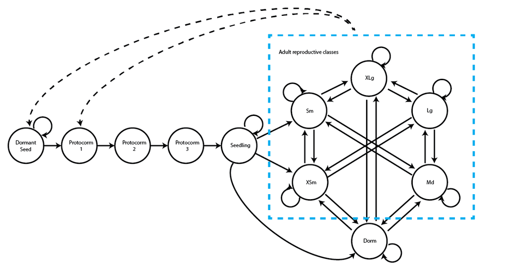

**Figure 3L.5.** Life history model of *Cypripedium candidum* for use in raw-based MPMs.

```r
cypraw_v1 <- verticalize3(data = cypdata, noyears = 6, firstyear = 2004,
  patchidcol = "patch", individcol = "plantid", blocksize = 4,
  sizeacol = "Inf2.04", sizebcol = "Inf.04", sizeccol = "Veg.04",
  repstracol = "Inf.04", repstrbcol = "Inf2.04", fecacol = "Pod.04",
  stageassign = cypframe_raw, stagesize = "sizeadded", NAas0 = TRUE,
  NRasRep = TRUE)

head(cypraw_v1)
```

```
#>   rowid popid patchid individ year2 firstseen lastseen obsage obslifespan
#> 1     1             A     164  2004      2004     2004      0           0
#> 2     2             A     165  2004      2004     2009      0           5
#> 3     3             A     240  2004      2004     2005      0           1
#> 4     4             A     242  2004      2004     2009      0           5
#> 5     5             A     243  2004      2004     2009      0           5
#> 6     6             A     246  2004      2004     2007      0           3
#>   sizea1 sizeb1 sizec1 size1added repstra1 repstrb1 feca1 juvgiven1 obsstatus1
#> 1      0      0      0          0        0        0     0         0          0
#> 2      0      0      0          0        0        0     0         0          0
#> 3      0      0      0          0        0        0     0         0          0
#> 4      0      0      0          0        0        0     0         0          0
#> 5      0      0      0          0        0        0     0         0          0
#> 6      0      0      0          0        0        0     0         0          0
#>   repstatus1 fecstatus1 matstatus1 alive1   stage1 stage1index sizea2 sizeb2
```

[output cut: 34 more lines]

In the code above, we used the `head()` function to take a look at the first 6 rows of the standardized data frame. The variable names and formats work with all functions in `lefko3`, and of course this data frame may be used in other packages, as well. Let’s now take a look at a summary of the full data frame.

```r
summary(cypraw_v1)
```

```
#>      rowid       popid  patchid   individ              year2
#>  Min.   : 1.00   :320   A: 93   Length:320         Min.   :2004
#>  1st Qu.:21.00          B:154   Class :character   1st Qu.:2005
#>  Median :37.50          C: 73   Mode  :character   Median :2006
#>  Mean   :38.45                                     Mean   :2006
#>  3rd Qu.:56.00                                     3rd Qu.:2007
#>  Max.   :77.00                                     Max.   :2008
#>    firstseen       lastseen        obsage       obslifespan
#>  Min.   :2004   Min.   :2004   Min.   :0.000   Min.   :0.000
#>  1st Qu.:2004   1st Qu.:2009   1st Qu.:1.000   1st Qu.:5.000
#>  Median :2004   Median :2009   Median :2.000   Median :5.000
#>  Mean   :2004   Mean   :2009   Mean   :1.853   Mean   :4.556
#>  3rd Qu.:2004   3rd Qu.:2009   3rd Qu.:3.000   3rd Qu.:5.000
#>  Max.   :2008   Max.   :2009   Max.   :4.000   Max.   :5.000
#>      sizea1             sizeb1            sizec1       size1added
#>  Min.   :0.000000   Min.   : 0.0000   Min.   : 0.0   Min.   : 0.000
#>  1st Qu.:0.000000   1st Qu.: 0.0000   1st Qu.: 0.0   1st Qu.: 0.000
#>  Median :0.000000   Median : 0.0000   Median : 1.0   Median : 2.000
#>  Mean   :0.009375   Mean   : 0.7469   Mean   : 1.9   Mean   : 2.656
#>  3rd Qu.:0.000000   3rd Qu.: 1.0000   3rd Qu.: 3.0   3rd Qu.: 4.000
#>  Max.   :1.000000   Max.   :18.0000   Max.   :13.0   Max.   :21.000
#>     repstra1          repstrb1            feca1          juvgiven1
#>  Min.   : 0.0000   Min.   :0.000000   Min.   :0.0000   Min.   :0
#>  1st Qu.: 0.0000   1st Qu.:0.000000   1st Qu.:0.0000   1st Qu.:0
#>  Median : 0.0000   Median :0.000000   Median :0.0000   Median :0
#>  Mean   : 0.7469   Mean   :0.009375   Mean   :0.2656   Mean   :0
#>  3rd Qu.: 1.0000   3rd Qu.:0.000000   3rd Qu.:0.0000   3rd Qu.:0
#>  Max.   :18.0000   Max.   :1.000000   Max.   :7.0000   Max.   :0
#>    obsstatus1       repstatus1       fecstatus1       matstatus1
#>  Min.   :0.0000   Min.   :0.0000   Min.   :0.0000   Min.   :0.0000
#>  1st Qu.:0.0000   1st Qu.:0.0000   1st Qu.:0.0000   1st Qu.:1.0000
#>  Median :1.0000   Median :0.0000   Median :0.0000   Median :1.0000
#>  Mean   :0.7469   Mean   :0.2875   Mean   :0.1344   Mean   :0.7688
#>  3rd Qu.:1.0000   3rd Qu.:1.0000   3rd Qu.:0.0000   3rd Qu.:1.0000
#>  Max.   :1.0000   Max.   :1.0000   Max.   :1.0000   Max.   :1.0000
#>      alive1          stage1           stage1index         sizea2
#>  Min.   :0.0000   Length:320         Min.   : 0.000   Min.   :0.000000
#>  1st Qu.:1.0000   Class :character   1st Qu.: 6.000   1st Qu.:0.000000
#>  Median :1.0000   Mode  :character   Median : 8.000   Median :0.000000
#>  Mean   :0.7688                      Mean   : 6.144   Mean   :0.009375
```

[output cut: 36 more lines]

```
#>  Max.   :24.000   Max.   :18.000   Max.   :1.000000   Max.   :8.0000
#>    juvgiven3   obsstatus3    repstatus3    fecstatus3       matstatus3
#>  Min.   :0   Min.   :0.0   Min.   :0.0   Min.   :0.0000   Min.   :1
#>  1st Qu.:0   1st Qu.:1.0   1st Qu.:0.0   1st Qu.:0.0000   1st Qu.:1
#>  Median :0   Median :1.0   Median :0.0   Median :0.0000   Median :1
#>  Mean   :0   Mean   :0.9   Mean   :0.4   Mean   :0.2219   Mean   :1
#>  3rd Qu.:0   3rd Qu.:1.0   3rd Qu.:1.0   3rd Qu.:0.0000   3rd Qu.:1
#>  Max.   :0   Max.   :1.0   Max.   :1.0   Max.   :1.0000   Max.   :1
#>      alive3          stage3           stage3index
#>  Min.   :0.0000   Length:320         Min.   : 0.000
#>  1st Qu.:1.0000   Class :character   1st Qu.: 7.000
#>  Median :1.0000   Mode  :character   Median : 8.000
#>  Mean   :0.9469                      Mean   : 7.544
#>  3rd Qu.:1.0000                      3rd Qu.: 8.000
#>  Max.   :1.0000                      Max.   :11.000
```

Let’s also create our standardized data for the function-based MPM, as below. Remember that some of the settings need to change here, primarily because we are now going to separate adults not just by size but by reproductive status. So, we will NOT set `NRasRep = TRUE` here.

```r
cypfb_v1 <- verticalize3(data = cypdata, noyears = 6, firstyear = 2004,
  patchidcol = "patch", individcol = "plantid", blocksize = 4,
  sizeacol = "Inf2.04", sizebcol = "Inf.04", sizeccol = "Veg.04",
  repstracol = "Inf.04", repstrbcol = "Inf2.04", fecacol = "Pod.04",
  stageassign = cypframe_fb, stagesize = "sizeadded", NAas0 = TRUE)

summary(cypfb_v1)
```

```
#>      rowid       popid  patchid   individ              year2
#>  Min.   : 1.00   :320   A: 93   Length:320         Min.   :2004
#>  1st Qu.:21.00          B:154   Class :character   1st Qu.:2005
#>  Median :37.50          C: 73   Mode  :character   Median :2006
#>  Mean   :38.45                                     Mean   :2006
#>  3rd Qu.:56.00                                     3rd Qu.:2007
#>  Max.   :77.00                                     Max.   :2008
#>    firstseen       lastseen        obsage       obslifespan
#>  Min.   :2004   Min.   :2004   Min.   :0.000   Min.   :0.000
#>  1st Qu.:2004   1st Qu.:2009   1st Qu.:1.000   1st Qu.:5.000
#>  Median :2004   Median :2009   Median :2.000   Median :5.000
#>  Mean   :2004   Mean   :2009   Mean   :1.853   Mean   :4.556
#>  3rd Qu.:2004   3rd Qu.:2009   3rd Qu.:3.000   3rd Qu.:5.000
#>  Max.   :2008   Max.   :2009   Max.   :4.000   Max.   :5.000
#>      sizea1             sizeb1            sizec1       size1added
#>  Min.   :0.000000   Min.   : 0.0000   Min.   : 0.0   Min.   : 0.000
#>  1st Qu.:0.000000   1st Qu.: 0.0000   1st Qu.: 0.0   1st Qu.: 0.000
#>  Median :0.000000   Median : 0.0000   Median : 1.0   Median : 2.000
#>  Mean   :0.009375   Mean   : 0.7469   Mean   : 1.9   Mean   : 2.656
#>  3rd Qu.:0.000000   3rd Qu.: 1.0000   3rd Qu.: 3.0   3rd Qu.: 4.000
#>  Max.   :1.000000   Max.   :18.0000   Max.   :13.0   Max.   :21.000
#>     repstra1          repstrb1            feca1          juvgiven1
#>  Min.   : 0.0000   Min.   :0.000000   Min.   :0.0000   Min.   :0
#>  1st Qu.: 0.0000   1st Qu.:0.000000   1st Qu.:0.0000   1st Qu.:0
#>  Median : 0.0000   Median :0.000000   Median :0.0000   Median :0
#>  Mean   : 0.7469   Mean   :0.009375   Mean   :0.2656   Mean   :0
#>  3rd Qu.: 1.0000   3rd Qu.:0.000000   3rd Qu.:0.0000   3rd Qu.:0
#>  Max.   :18.0000   Max.   :1.000000   Max.   :7.0000   Max.   :0
#>    obsstatus1       repstatus1       fecstatus1       matstatus1
#>  Min.   :0.0000   Min.   :0.0000   Min.   :0.0000   Min.   :0.0000
#>  1st Qu.:0.0000   1st Qu.:0.0000   1st Qu.:0.0000   1st Qu.:1.0000
#>  Median :1.0000   Median :0.0000   Median :0.0000   Median :1.0000
#>  Mean   :0.7469   Mean   :0.2875   Mean   :0.1344   Mean   :0.7688
#>  3rd Qu.:1.0000   3rd Qu.:1.0000   3rd Qu.:0.0000   3rd Qu.:1.0000
#>  Max.   :1.0000   Max.   :1.0000   Max.   :1.0000   Max.   :1.0000
#>      alive1          stage1           stage1index        sizea2
#>  Min.   :0.0000   Length:320         Min.   : 0.00   Min.   :0.000000
#>  1st Qu.:1.0000   Class :character   1st Qu.: 6.00   1st Qu.:0.000000
#>  Median :1.0000   Mode  :character   Median : 8.00   Median :0.000000
#>  Mean   :0.7688                      Mean   :14.17   Mean   :0.009375
```

[output cut: 36 more lines]

```
#>  Max.   :24.000   Max.   :18.000   Max.   :1.000000   Max.   :8.0000
#>    juvgiven3   obsstatus3    repstatus3    fecstatus3       matstatus3
#>  Min.   :0   Min.   :0.0   Min.   :0.0   Min.   :0.0000   Min.   :1
#>  1st Qu.:0   1st Qu.:1.0   1st Qu.:0.0   1st Qu.:0.0000   1st Qu.:1
#>  Median :0   Median :1.0   Median :0.0   Median :0.0000   Median :1
#>  Mean   :0   Mean   :0.9   Mean   :0.4   Mean   :0.2219   Mean   :1
#>  3rd Qu.:0   3rd Qu.:1.0   3rd Qu.:1.0   3rd Qu.:0.0000   3rd Qu.:1
#>  Max.   :0   Max.   :1.0   Max.   :1.0   Max.   :1.0000   Max.   :1
#>      alive3          stage3           stage3index
#>  Min.   :0.0000   Length:320         Min.   : 0.00
#>  1st Qu.:1.0000   Class :character   1st Qu.: 7.00
#>  Median :1.0000   Mode  :character   Median :10.00
#>  Mean   :0.9469                      Mean   :18.57
#>  3rd Qu.:1.0000                      3rd Qu.:33.00
#>  Max.   :1.0000                      Max.   :54.00
```

#### Step 2b. Vertical dataset organization

We may also wish to see how to proceed if our original dataset is already in vertical, but ahistorical, format. This package also includes dataset `cypvert`, which is the same dataset as `cypdata` but set in ahistorical vertical format. Here, we will use the `historicalize3()` function to deal with this dataset, which uses an individual identity variable in order to put all of the data for each individual together. Here, the vertical dataset includes the `plantid` variable, which is an individual identity term and must be supplied for conversion. Here is the raw MPM dataset.

```r
cypraw_v2 <- historicalize3(data = cypvert, patchidcol = "patch",
  individcol = "plantid", year2col = "year2", sizea2col = "Inf2.2",
  sizea3col = "Inf2.3", sizeb2col = "Inf.2", sizeb3col = "Inf.3",
  sizec2col = "Veg.2", sizec3col = "Veg.3", repstra2col = "Inf2.2",
  repstra3col = "Inf2.3", repstrb2col = "Inf.2", repstrb3col = "Inf.3",
  feca2col = "Pod.2", feca3col = "Pod.3", repstrrel = 2,
  stageassign = cypframe_raw, stagesize = "sizeadded", censorcol = "censor",
  censorkeep = 1, censor = FALSE, NAas0 = TRUE, NRasRep = TRUE, reduce = TRUE)

summary(cypraw_v2)
```

```
#>      rowid           popid             patchid            individ
#>  Min.   :  0.00   Length:320         Length:320         Length:320
#>  1st Qu.: 82.75   Class :character   Class :character   Class :character
#>  Median :162.50   Mode  :character   Mode  :character   Mode  :character
#>  Mean   :163.70
#>  3rd Qu.:245.25
#>  Max.   :330.00
#>      year2        firstseen       lastseen        obsage       obslifespan
#>  Min.   :2004   Min.   :2004   Min.   :2004   Min.   :0.000   Min.   :0.000
#>  1st Qu.:2005   1st Qu.:2004   1st Qu.:2009   1st Qu.:1.000   1st Qu.:5.000
#>  Median :2006   Median :2004   Median :2009   Median :2.000   Median :5.000
#>  Mean   :2006   Mean   :2004   Mean   :2009   Mean   :1.853   Mean   :4.556
#>  3rd Qu.:2007   3rd Qu.:2004   3rd Qu.:2009   3rd Qu.:3.000   3rd Qu.:5.000
#>  Max.   :2008   Max.   :2008   Max.   :2009   Max.   :4.000   Max.   :5.000
#>      sizea1             sizeb1            sizec1       size1added
#>  Min.   :0.000000   Min.   : 0.0000   Min.   : 0.0   Min.   : 0.000
#>  1st Qu.:0.000000   1st Qu.: 0.0000   1st Qu.: 0.0   1st Qu.: 0.000
#>  Median :0.000000   Median : 0.0000   Median : 1.0   Median : 2.000
#>  Mean   :0.009375   Mean   : 0.7469   Mean   : 1.9   Mean   : 2.656
#>  3rd Qu.:0.000000   3rd Qu.: 1.0000   3rd Qu.: 3.0   3rd Qu.: 4.000
#>  Max.   :1.000000   Max.   :18.0000   Max.   :13.0   Max.   :21.000
#>     repstra1           repstrb1           feca1          juvgiven1
#>  Min.   :0.000000   Min.   : 0.0000   Min.   :0.0000   Min.   :0
#>  1st Qu.:0.000000   1st Qu.: 0.0000   1st Qu.:0.0000   1st Qu.:0
#>  Median :0.000000   Median : 0.0000   Median :0.0000   Median :0
#>  Mean   :0.009375   Mean   : 0.7469   Mean   :0.2656   Mean   :0
#>  3rd Qu.:0.000000   3rd Qu.: 1.0000   3rd Qu.:0.0000   3rd Qu.:0
#>  Max.   :1.000000   Max.   :18.0000   Max.   :7.0000   Max.   :0
#>    obsstatus1       repstatus1       fecstatus1       matstatus1
#>  Min.   :0.0000   Min.   :0.0000   Min.   :0.0000   Min.   :0.0000
#>  1st Qu.:0.0000   1st Qu.:0.0000   1st Qu.:0.0000   1st Qu.:1.0000
#>  Median :1.0000   Median :0.0000   Median :0.0000   Median :1.0000
#>  Mean   :0.7469   Mean   :0.2875   Mean   :0.1344   Mean   :0.7688
#>  3rd Qu.:1.0000   3rd Qu.:1.0000   3rd Qu.:0.0000   3rd Qu.:1.0000
#>  Max.   :1.0000   Max.   :1.0000   Max.   :1.0000   Max.   :1.0000
#>      alive1          stage1           stage1index         sizea2
#>  Min.   :0.0000   Length:320         Min.   : 0.000   Min.   :0.000000
#>  1st Qu.:1.0000   Class :character   1st Qu.: 6.000   1st Qu.:0.000000
#>  Median :1.0000   Mode  :character   Median : 8.000   Median :0.000000
#>  Mean   :0.7688                      Mean   : 6.144   Mean   :0.009375
```

[output cut: 36 more lines]

```
#>  Max.   :24.000   Max.   :1.000000   Max.   :18.000   Max.   :8.0000
#>    juvgiven3   obsstatus3    repstatus3    fecstatus3       matstatus3
#>  Min.   :0   Min.   :0.0   Min.   :0.0   Min.   :0.0000   Min.   :1
#>  1st Qu.:0   1st Qu.:1.0   1st Qu.:0.0   1st Qu.:0.0000   1st Qu.:1
#>  Median :0   Median :1.0   Median :0.0   Median :0.0000   Median :1
#>  Mean   :0   Mean   :0.9   Mean   :0.4   Mean   :0.2219   Mean   :1
#>  3rd Qu.:0   3rd Qu.:1.0   3rd Qu.:1.0   3rd Qu.:0.0000   3rd Qu.:1
#>  Max.   :0   Max.   :1.0   Max.   :1.0   Max.   :1.0000   Max.   :1
#>      alive3          stage3           stage3index
#>  Min.   :0.0000   Length:320         Min.   : 0.000
#>  1st Qu.:1.0000   Class :character   1st Qu.: 7.000
#>  Median :1.0000   Mode  :character   Median : 8.000
#>  Mean   :0.9469                      Mean   : 7.544
#>  3rd Qu.:1.0000                      3rd Qu.: 8.000
#>  Max.   :1.0000                      Max.   :11.000
```

Let’s also create the function-based MPM version.

```r
cypfb_v2 <- historicalize3(data = cypvert, patchidcol = "patch",
  individcol = "plantid", year2col = "year2", sizea2col = "Inf2.2",
  sizea3col = "Inf2.3", sizeb2col = "Inf.2", sizeb3col = "Inf.3",
  sizec2col = "Veg.2", sizec3col = "Veg.3", repstra2col = "Inf2.2",
  repstra3col = "Inf2.3", repstrb2col = "Inf.2", repstrb3col = "Inf.3",
  feca2col = "Pod.2", feca3col = "Pod.3", repstrrel = 2,
  stageassign = cypframe_fb, stagesize = "sizeadded", censorcol = "censor",
  censorkeep = 1, censor = FALSE, NAas0 = TRUE, reduce = TRUE)

summary(cypfb_v2)
```

```
#>      rowid           popid             patchid            individ
#>  Min.   :  0.00   Length:320         Length:320         Length:320
#>  1st Qu.: 82.75   Class :character   Class :character   Class :character
#>  Median :162.50   Mode  :character   Mode  :character   Mode  :character
#>  Mean   :163.70
#>  3rd Qu.:245.25
#>  Max.   :330.00
#>      year2        firstseen       lastseen        obsage       obslifespan
#>  Min.   :2004   Min.   :2004   Min.   :2004   Min.   :0.000   Min.   :0.000
#>  1st Qu.:2005   1st Qu.:2004   1st Qu.:2009   1st Qu.:1.000   1st Qu.:5.000
#>  Median :2006   Median :2004   Median :2009   Median :2.000   Median :5.000
#>  Mean   :2006   Mean   :2004   Mean   :2009   Mean   :1.853   Mean   :4.556
#>  3rd Qu.:2007   3rd Qu.:2004   3rd Qu.:2009   3rd Qu.:3.000   3rd Qu.:5.000
#>  Max.   :2008   Max.   :2008   Max.   :2009   Max.   :4.000   Max.   :5.000
#>      sizea1             sizeb1            sizec1       size1added
#>  Min.   :0.000000   Min.   : 0.0000   Min.   : 0.0   Min.   : 0.000
#>  1st Qu.:0.000000   1st Qu.: 0.0000   1st Qu.: 0.0   1st Qu.: 0.000
#>  Median :0.000000   Median : 0.0000   Median : 1.0   Median : 2.000
#>  Mean   :0.009375   Mean   : 0.7469   Mean   : 1.9   Mean   : 2.656
#>  3rd Qu.:0.000000   3rd Qu.: 1.0000   3rd Qu.: 3.0   3rd Qu.: 4.000
#>  Max.   :1.000000   Max.   :18.0000   Max.   :13.0   Max.   :21.000
#>     repstra1           repstrb1           feca1          juvgiven1
#>  Min.   :0.000000   Min.   : 0.0000   Min.   :0.0000   Min.   :0
#>  1st Qu.:0.000000   1st Qu.: 0.0000   1st Qu.:0.0000   1st Qu.:0
#>  Median :0.000000   Median : 0.0000   Median :0.0000   Median :0
#>  Mean   :0.009375   Mean   : 0.7469   Mean   :0.2656   Mean   :0
#>  3rd Qu.:0.000000   3rd Qu.: 1.0000   3rd Qu.:0.0000   3rd Qu.:0
#>  Max.   :1.000000   Max.   :18.0000   Max.   :7.0000   Max.   :0
#>    obsstatus1       repstatus1       fecstatus1       matstatus1
#>  Min.   :0.0000   Min.   :0.0000   Min.   :0.0000   Min.   :0.0000
#>  1st Qu.:0.0000   1st Qu.:0.0000   1st Qu.:0.0000   1st Qu.:1.0000
#>  Median :1.0000   Median :0.0000   Median :0.0000   Median :1.0000
#>  Mean   :0.7469   Mean   :0.2875   Mean   :0.1344   Mean   :0.7688
#>  3rd Qu.:1.0000   3rd Qu.:1.0000   3rd Qu.:0.0000   3rd Qu.:1.0000
#>  Max.   :1.0000   Max.   :1.0000   Max.   :1.0000   Max.   :1.0000
#>      alive1          stage1           stage1index        sizea2
#>  Min.   :0.0000   Length:320         Min.   : 0.00   Min.   :0.000000
#>  1st Qu.:1.0000   Class :character   1st Qu.: 6.00   1st Qu.:0.000000
#>  Median :1.0000   Mode  :character   Median : 8.00   Median :0.000000
#>  Mean   :0.7688                      Mean   :14.17   Mean   :0.009375
```

[output cut: 36 more lines]

```
#>  Max.   :24.000   Max.   :1.000000   Max.   :18.000   Max.   :8.0000
#>    juvgiven3   obsstatus3    repstatus3    fecstatus3       matstatus3
#>  Min.   :0   Min.   :0.0   Min.   :0.0   Min.   :0.0000   Min.   :1
#>  1st Qu.:0   1st Qu.:1.0   1st Qu.:0.0   1st Qu.:0.0000   1st Qu.:1
#>  Median :0   Median :1.0   Median :0.0   Median :0.0000   Median :1
#>  Mean   :0   Mean   :0.9   Mean   :0.4   Mean   :0.2219   Mean   :1
#>  3rd Qu.:0   3rd Qu.:1.0   3rd Qu.:1.0   3rd Qu.:0.0000   3rd Qu.:1
#>  Max.   :0   Max.   :1.0   Max.   :1.0   Max.   :1.0000   Max.   :1
#>      alive3          stage3           stage3index
#>  Min.   :0.0000   Length:320         Min.   : 0.00
#>  1st Qu.:1.0000   Class :character   1st Qu.: 7.00
#>  Median :1.0000   Mode  :character   Median :10.00
#>  Mean   :0.9469                      Mean   :18.57
#>  3rd Qu.:1.0000                      3rd Qu.:33.00
#>  Max.   :1.0000                      Max.   :54.00
```

We can compare the dimensions of these datasets.

```r
dim(cypraw_v1)
```

```
#> [1] 320  54
```

```r
dim(cypraw_v2)
```

```
#> [1] 320  54
```

```r
dim(cypfb_v1)
```

```
#> [1] 320  54
```

```r
dim(cypfb_v2)
```

```
#> [1] 320  54
```

The lengths of the datasets are the same in terms of rows and columns, and the variables and data are the same although the order of the columns and rows might not match (see the summaries for comparison).

Let’s now move on to supplying R with the proxy transitions that we need to properly parameterize our models.

#### Step 2c. Provide supplemental information for matrix estimation

The next steps involve adding some external data to parameterize the matrices properly. There are two approaches for this:

1. using the `supplemental()` function, or
2. creating a reproductive matrix and using the `overwrite()` function.

We advise the use of the first approach, the `supplemental()` function, which is more holistic and flexible than the other approach. The `supplemental()` function provides a means of inputting three kinds of data into MPM construction:

1. fixed transition values derived from other studies and added as constants to matrices,
2. proxy transition values when data for particular transitions does not exist and other, estimable transitions will be used as proxies, and
3. reproductive multipliers to indicate which stages lead to the production of which stages, and at what level relative to estimated fecundity.

We will start off by creating two supplemental tables taking all of these sorts of data for the function-based MPMs. The first is the supplemental table for the historical analysis, and the second table covers the ahistorical analysis. Each row refers to a specific transition, and in the historical case, there are codes for 19 given transitions (12 for the ahistorical case). The first 9 of the historical transitions are set to specific probabilities, and the next 8 are transitions that will be set to other, estimated transitions (these are the non-NA transitions in `eststage` set below). The final 2 terms of fecundity multipliers. Based on the literature, the proxies for entry into the adult classes are transitions from dormancy, as below. However, in the raw dataset, dormancy is not common enough to use as an effective proxy in raw matrix creation. Hence, we can use different proxies for function-based matrix estimation than for raw matrix estimation. Where necessary, we also use `rep` and `mat` as shorthand to code for all reproductive stages and all mature stages, respectively.

Here is the historical supplemental table.

```r
cypsupp3_fb <- supplemental(stage3 = c("SD", "SD", "P1", "P1", "P2", "P3", "SL",
    "SL", "SL", "D", "V1", "V2", "V3", "D", "V1", "V2", "V3", "SD", "P1"),
  stage2 = c("SD", "SD", "SD", "SD", "P1", "P2", "P3", "SL", "SL", "SL", "SL",
    "SL", "SL", "SL", "SL", "SL", "SL", "rep", "rep"),
  stage1 = c("SD", "rep", "SD", "rep", "SD", "P1", "P2", "P3", "SL", "P3", "P3",
    "P3", "P3", "SL", "SL", "SL", "SL", "mat", "mat"),
  eststage3 = c(NA, NA, NA, NA, NA, NA, NA, NA, NA, "D", "V1", "V2", "V3", "D",
    "V1", "V2", "V3", NA, NA),
  eststage2 = c(NA, NA, NA, NA, NA, NA, NA, NA, NA, "D", "D", "D", "D", "D",
    "D", "D", "D", NA, NA),
  eststage1 = c(NA, NA, NA, NA, NA, NA, NA, NA, NA, "D", "D", "D", "D", "D",
    "D", "D", "D", NA, NA),
  givenrate = c(0.08, 0.08, 0.1, 0.1, 0.1, 0.1, 0.125, 0.2, 0.2, NA, NA, NA, NA,
    NA, NA, NA, NA, NA, NA),
  multiplier = c(NA, NA, NA, NA, NA, NA, NA, NA, NA, NA, NA, NA, NA, NA, NA, NA,
    NA, 0.5, 0.5),
  type = c("S", "S", "S", "S", "S", "S", "S", "S", "S", "S", "S", "S", "S", "S",
    "S", "S", "S", "R", "R"),
  type_t12 = c("S", "F", "S", "F", "S", "S", "S", "S", "S", "S", "S", "S", "S",
    "S", "S", "S", "S", "S", "S"), stageframe = cypframe_fb)

cypsupp3_fb
```

```
#>    stage3 stage2 stage1 eststage3 eststage2 eststage1 givenrate multiplier
#> 1      SD     SD     SD      <NA>      <NA>      <NA>     0.080         NA
#> 2      SD     SD    rep      <NA>      <NA>      <NA>     0.080         NA
#> 3      P1     SD     SD      <NA>      <NA>      <NA>     0.100         NA
#> 4      P1     SD    rep      <NA>      <NA>      <NA>     0.100         NA
#> 5      P2     P1     SD      <NA>      <NA>      <NA>     0.100         NA
#> 6      P3     P2     P1      <NA>      <NA>      <NA>     0.100         NA
#> 7      SL     P3     P2      <NA>      <NA>      <NA>     0.125         NA
#> 8      SL     SL     P3      <NA>      <NA>      <NA>     0.200         NA
#> 9      SL     SL     SL      <NA>      <NA>      <NA>     0.200         NA
#> 10      D     SL     P3         D         D         D        NA         NA
#> 11     V1     SL     P3        V1         D         D        NA         NA
#> 12     V2     SL     P3        V2         D         D        NA         NA
#> 13     V3     SL     P3        V3         D         D        NA         NA
#> 14      D     SL     SL         D         D         D        NA         NA
```

[output cut: 25 more lines]

Now we can input the ahistorical table.

```r
cypsupp2_fb <- supplemental(stage3 = c("SD", "P1", "P2", "P3", "SL", "SL", "D",
    "V1", "V2", "V3", "SD", "P1"),
  stage2 = c("SD", "SD", "P1", "P2", "P3", "SL", "SL", "SL", "SL", "SL", "rep",
    "rep"),
  eststage3 = c(NA, NA, NA, NA, NA, NA, "D", "V1", "V2", "V3", NA, NA),
  eststage2 = c(NA, NA, NA, NA, NA, NA, "D", "D", "D", "D", NA, NA),
  givenrate = c(0.08, 0.1, 0.1, 0.1, 0.125, 0.2, NA, NA, NA, NA, NA, NA),
  multiplier = c(NA, NA, NA, NA, NA, NA, NA, NA, NA, NA, 0.5, 0.5),
  type = c("S", "S", "S", "S", "S", "S", "S", "S", "S", "S", "R", "R"),
  stageframe = cypframe_fb, historical = FALSE)

cypsupp2_fb
```

```
#>    stage3 stage2 stage1 eststage3 eststage2 eststage1 givenrate multiplier
#> 1      SD     SD   <NA>      <NA>      <NA>      <NA>     0.080         NA
#> 2      P1     SD   <NA>      <NA>      <NA>      <NA>     0.100         NA
#> 3      P2     P1   <NA>      <NA>      <NA>      <NA>     0.100         NA
#> 4      P3     P2   <NA>      <NA>      <NA>      <NA>     0.100         NA
#> 5      SL     P3   <NA>      <NA>      <NA>      <NA>     0.125         NA
#> 6      SL     SL   <NA>      <NA>      <NA>      <NA>     0.200         NA
#> 7       D     SL   <NA>         D         D      <NA>        NA         NA
#> 8      V1     SL   <NA>        V1         D      <NA>        NA         NA
#> 9      V2     SL   <NA>        V2         D      <NA>        NA         NA
#> 10     V3     SL   <NA>        V3         D      <NA>        NA         NA
#> 11     SD    rep   <NA>      <NA>      <NA>      <NA>        NA        0.5
#> 12     P1    rep   <NA>      <NA>      <NA>      <NA>        NA        0.5
#>    convtype convtype_t12
#> 1         1            1
#> 2         1            1
#> 3         1            1
#> 4         1            1
#> 5         1            1
#> 6         1            1
#> 7         1            1
#> 8         1            1
#> 9         1            1
#> 10        1            1
#> 11        3            1
#> 12        3            1
```

These supplemental tables provide the best means of adding external data to our MPMs because they allow both specific transitions to be isolated, and because they allow the use of shorthand to identify large groups of transitions (e.g. using `mat`, `rep`, `immat`, `prop`, or `all` to signify all mature stages, reproductive stages, immature stages, propagule stages, or simply all stages, respectively). Let’s now also supply the supplemental tables for the raw MPMs.

```r
cypsupp3_raw <- supplemental(stage3 = c("SD", "SD", "P1", "P1", "P2", "P3", "SL",
    "D", "XSm", "Sm", "D", "XSm", "Sm", "SD", "P1"),
  stage2 = c("SD", "SD", "SD", "SD", "P1", "P2", "P3", "SL", "SL", "SL", "SL",
    "SL", "SL", "rep", "rep"),
  stage1 = c("SD", "rep", "SD", "rep", "SD", "P1", "P2", "P3", "P3", "P3",
    "SL", "SL", "SL", "mat", "mat"),
  eststage3 = c(NA, NA, NA, NA, NA, NA, NA, "D", "XSm", "Sm", "D", "XSm", "Sm",
    NA, NA),
  eststage2 = c(NA, NA, NA, NA, NA, NA, NA, "XSm", "XSm", "XSm", "XSm", "XSm",
    "XSm", NA, NA),
  eststage1 = c(NA, NA, NA, NA, NA, NA, NA, "XSm", "XSm", "XSm", "XSm", "XSm",
    "XSm", NA, NA),
  givenrate = c(0.1, 0.1, 0.2, 0.2, 0.2, 0.2, 0.25, NA, NA, NA, NA, NA, NA,
    NA, NA),
  multiplier = c(NA, NA, NA, NA, NA, NA, NA, NA, NA, NA, NA, NA, NA, 0.5, 0.5),
  type = c(1, 1, 1, 1, 1, 1, 1, 1, 1, 1, 1, 1, 1, 3, 3),
  type_t12 = c(1, 2, 1, 2, 1, 1, 1, 1, 1, 1, 1, 1, 1, 1, 1),
  stageframe = cypframe_raw, historical = TRUE)

cypsupp2_raw <- supplemental(stage3 = c("SD", "P1", "P2", "P3", "SL", "D",
    "XSm", "Sm", "SD", "P1"),
  stage2 = c("SD", "SD", "P1", "P2", "P3", "SL", "SL", "SL", "rep",
    "rep"),
  eststage3 = c(NA, NA, NA, NA, NA, "D", "XSm", "Sm", NA, NA),
  eststage2 = c(NA, NA, NA, NA, NA, "XSm", "XSm", "XSm", NA, NA),
  givenrate = c(0.10, 0.20, 0.20, 0.20, 0.25, NA, NA, NA, NA, NA),
  multiplier = c(NA, NA, NA, NA, NA, NA, NA, NA, 0.5, 0.5),
  type =c(1, 1, 1, 1, 1, 1, 1, 1, 3, 3),
  stageframe = cypframe_raw, historical = FALSE)

cypsupp3_raw
```

```
#>    stage3 stage2 stage1 eststage3 eststage2 eststage1 givenrate multiplier
#> 1      SD     SD     SD      <NA>      <NA>      <NA>      0.10         NA
#> 2      SD     SD    rep      <NA>      <NA>      <NA>      0.10         NA
#> 3      P1     SD     SD      <NA>      <NA>      <NA>      0.20         NA
#> 4      P1     SD    rep      <NA>      <NA>      <NA>      0.20         NA
#> 5      P2     P1     SD      <NA>      <NA>      <NA>      0.20         NA
#> 6      P3     P2     P1      <NA>      <NA>      <NA>      0.20         NA
#> 7      SL     P3     P2      <NA>      <NA>      <NA>      0.25         NA
#> 8       D     SL     P3         D       XSm       XSm        NA         NA
#> 9     XSm     SL     P3       XSm       XSm       XSm        NA         NA
#> 10     Sm     SL     P3        Sm       XSm       XSm        NA         NA
#> 11      D     SL     SL         D       XSm       XSm        NA         NA
#> 12    XSm     SL     SL       XSm       XSm       XSm        NA         NA
#> 13     Sm     SL     SL        Sm       XSm       XSm        NA         NA
#> 14     SD    rep    mat      <NA>      <NA>      <NA>        NA        0.5
```

[output cut: 17 more lines]

```r
cypsupp2_raw
```

```
#>    stage3 stage2 stage1 eststage3 eststage2 eststage1 givenrate multiplier
#> 1      SD     SD   <NA>      <NA>      <NA>      <NA>      0.10         NA
#> 2      P1     SD   <NA>      <NA>      <NA>      <NA>      0.20         NA
#> 3      P2     P1   <NA>      <NA>      <NA>      <NA>      0.20         NA
#> 4      P3     P2   <NA>      <NA>      <NA>      <NA>      0.20         NA
#> 5      SL     P3   <NA>      <NA>      <NA>      <NA>      0.25         NA
#> 6       D     SL   <NA>         D       XSm      <NA>        NA         NA
#> 7     XSm     SL   <NA>       XSm       XSm      <NA>        NA         NA
#> 8      Sm     SL   <NA>        Sm       XSm      <NA>        NA         NA
#> 9      SD    rep   <NA>      <NA>      <NA>      <NA>        NA        0.5
#> 10     P1    rep   <NA>      <NA>      <NA>      <NA>        NA        0.5
#>    convtype convtype_t12
#> 1         1            1
#> 2         1            1
#> 3         1            1
#> 4         1            1
#> 5         1            1
#> 6         1            1
#> 7         1            1
#> 8         1            1
#> 9         3            1
#> 10        3            1
```

The supplemental tables provide all of the information that we need. However, there is an alternative means of supplying this information, and that is through the creation of a reproductive matrix and an `overwrite` table. The reproductive matrix is an **ahistorical** matrix detailing where fecundity rates are set, and at what level. *Cypripedium candidum* produces seeds that germinate by the following growing season (stage P1, or a first year protocorm), or that remain dormant for the next year (stage SD). In the following matrix, we detail that the fecundity of each reproductive stage needs to be split into two between each of these output stages. The actual split places 50% of the fecundity of a reproductive stage into each category of recruit, where the full fecundity is estimated by linear models that we will create. This reproductive matrix can be used in historical MPM construction, and it is assumed that stage at occasion *t*-1 is set to `all`.

```r
rep.assumptions_fb <- matrix(0, 54, 54)
rep.assumptions_fb[1:2,31:54] <- 0.5
rep.assumptions_fb
```

```
#>       [,1] [,2] [,3] [,4] [,5] [,6] [,7] [,8] [,9] [,10] [,11] [,12] [,13]
#>  [1,]    0    0    0    0    0    0    0    0    0     0     0     0     0
#>  [2,]    0    0    0    0    0    0    0    0    0     0     0     0     0
#>  [3,]    0    0    0    0    0    0    0    0    0     0     0     0     0
#>  [4,]    0    0    0    0    0    0    0    0    0     0     0     0     0
#>  [5,]    0    0    0    0    0    0    0    0    0     0     0     0     0
#>  [6,]    0    0    0    0    0    0    0    0    0     0     0     0     0
#>  [7,]    0    0    0    0    0    0    0    0    0     0     0     0     0
#>  [8,]    0    0    0    0    0    0    0    0    0     0     0     0     0
#>  [9,]    0    0    0    0    0    0    0    0    0     0     0     0     0
#> [10,]    0    0    0    0    0    0    0    0    0     0     0     0     0
#> [11,]    0    0    0    0    0    0    0    0    0     0     0     0     0
#> [12,]    0    0    0    0    0    0    0    0    0     0     0     0     0
#> [13,]    0    0    0    0    0    0    0    0    0     0     0     0     0
#> [14,]    0    0    0    0    0    0    0    0    0     0     0     0     0
```

[output cut: 260 more lines]

Next we will create the overwrite tables, which outline transitions that cannot be estimated from the data set and need to be set by other means. Here is an example of two overwrite tables for the *Cypripedium candidum* analysis. Note that they are fundamentally similar to supplemental tables, but do not allow the addition of fecundity multipliers and transition types from occasion *t*-1 to *t*, nor do they involve a check of entered stages against the stage frame.

```r
cypover3_fb <- overwrite(stage3 = c("SD", "SD", "P1", "P1", "P2", "P3", "SL", "SL",
    "SL", "D", "V1", "V2", "V3", "D", "V1", "V2", "V3"),
  stage2 = c("SD", "SD", "SD", "SD", "P1", "P2", "P3", "SL", "SL", "SL", "SL",
    "SL", "SL", "SL", "SL", "SL", "SL"),
  stage1 = c("SD", "rep", "SD", "rep", "SD", "P1", "P2", "P3", "SL", "P3", "P3",
    "P3", "P3", "SL", "SL", "SL", "SL"),
  eststage3 = c(NA, NA, NA, NA, NA, NA, NA, NA, NA, "D", "V1", "V2", "V3", "D",
    "V1", "V2", "V3"),
  eststage2 = c(NA, NA, NA, NA, NA, NA, NA, NA, NA, "D", "D", "D", "D", "D",
    "D", "D", "D"),
  eststage1 = c(NA, NA, NA, NA, NA, NA, NA, NA, NA, "D", "D", "D", "D", "D",
    "D", "D", "D"),
  givenrate = c(0.08, 0.08, 0.1, 0.1, 0.1, 0.1, 0.125, 0.2, 0.2, NA, NA, NA, NA,
    NA, NA, NA, NA),
  type = c("S", "S", "S", "S", "S", "S", "S", "S", "S", "S", "S", "S", "S", "S",
    "S", "S", "S"))

cypover2_fb <- overwrite(stage3 = c("SD", "P1", "P2", "P3", "SL", "SL", "D", "V1",
    "V2", "V3"),
  stage2 = c("SD", "SD", "P1", "P2", "P3", "SL", "SL", "SL", "SL", "SL"),
  eststage3 = c(NA, NA, NA, NA, NA, NA, "D", "V1", "V2", "V3"),
  eststage2 = c(NA, NA, NA, NA, NA, NA, "D", "D", "D", "D"),
  givenrate = c(0.08, 0.1, 0.1, 0.1, 0.125, 0.2, NA, NA, NA, NA),
  type = c("S", "S", "S", "S", "S", "S", "S", "S", "S", "S"))

cypover3_fb
```

```
#>    stage3 stage2 stage1 eststage3 eststage2 eststage1 givenrate convtype
#> 1      SD     SD     SD      <NA>      <NA>      <NA>     0.080        1
#> 2      SD     SD    rep      <NA>      <NA>      <NA>     0.080        1
#> 3      P1     SD     SD      <NA>      <NA>      <NA>     0.100        1
#> 4      P1     SD    rep      <NA>      <NA>      <NA>     0.100        1
#> 5      P2     P1     SD      <NA>      <NA>      <NA>     0.100        1
#> 6      P3     P2     P1      <NA>      <NA>      <NA>     0.100        1
#> 7      SL     P3     P2      <NA>      <NA>      <NA>     0.125        1
#> 8      SL     SL     P3      <NA>      <NA>      <NA>     0.200        1
#> 9      SL     SL     SL      <NA>      <NA>      <NA>     0.200        1
#> 10      D     SL     P3         D         D         D        NA        1
#> 11     V1     SL     P3        V1         D         D        NA        1
#> 12     V2     SL     P3        V2         D         D        NA        1
#> 13     V3     SL     P3        V3         D         D        NA        1
#> 14      D     SL     SL         D         D         D        NA        1
```

[output cut: 21 more lines]

```r
cypover2_fb
```

```
#>    stage3 stage2 stage1 eststage3 eststage2 eststage1 givenrate convtype
#> 1      SD     SD   <NA>      <NA>      <NA>      <NA>     0.080        1
#> 2      P1     SD   <NA>      <NA>      <NA>      <NA>     0.100        1
#> 3      P2     P1   <NA>      <NA>      <NA>      <NA>     0.100        1
#> 4      P3     P2   <NA>      <NA>      <NA>      <NA>     0.100        1
#> 5      SL     P3   <NA>      <NA>      <NA>      <NA>     0.125        1
#> 6      SL     SL   <NA>      <NA>      <NA>      <NA>     0.200        1
#> 7       D     SL   <NA>         D         D      <NA>        NA        1
#> 8      V1     SL   <NA>        V1         D      <NA>        NA        1
#> 9      V2     SL   <NA>        V2         D      <NA>        NA        1
#> 10     V3     SL   <NA>        V3         D      <NA>        NA        1
#>    convtype_t12
#> 1             1
#> 2             1
#> 3             1
#> 4             1
#> 5             1
#> 6             1
#> 7             1
#> 8             1
#> 9             1
#> 10            1
```

Let’s now also supply the overwrite tables and reproductive matrix for the raw MPM approach.

```r
rep_cyp_raw <- matrix(0, 11, 11)
rep_cyp_raw[1:2,7:11] <- 0.5

cypover2_raw <- overwrite(stage3 = c("SD", "P1", "P2", "P3", "SL", "SL", "D",
    "XSm", "Sm"),
  stage2 = c("SD", "SD", "P1", "P2", "P3", "SL", "SL", "SL", "SL"),
  eststage3 = c(NA, NA, NA, NA, NA, NA, "D", "XSm", "Sm"),
  eststage2 = c(NA, NA, NA, NA, NA, NA, "XSm", "XSm", "XSm"),
  givenrate = c(0.1, 0.2, 0.2, 0.2, 0.25, 0.1, NA, NA, NA),
  type = c("S", "S", "S", "S", "S", "S", "S", "S", "S"))

cypover3_raw <- overwrite(stage3 = c("SD", "SD", "P1", "P1", "P2", "P3", "SL",
    "SL", "SL", "D", "XSm", "Sm", "D", "XSm", "Sm"),
  stage2 = c("SD", "SD", "SD", "SD", "P1", "P2", "P3", "SL", "SL", "SL", "SL",
    "SL", "SL", "SL", "SL"),
  stage1 = c("SD", "rep", "SD", "rep", "SD", "P1", "P2", "P3", "SL", "P3",
    "P3", "P3", "SL", "SL", "SL"),
  eststage3 = c(NA, NA, NA, NA, NA, NA, NA, NA, NA, "D", "XSm", "Sm", "D",
    "XSm", "Sm"),
  eststage2 = c(NA, NA, NA, NA, NA, NA, NA, NA, NA, "XSm", "XSm", "XSm",
    "XSm", "XSm", "XSm"),
  eststage1 = c(NA, NA, NA, NA, NA, NA, NA, NA, NA, "XSm", "XSm", "XSm",
    "XSm", "XSm", "XSm"),
  givenrate = c(0.1, 0.1, 0.2, 0.2, 0.2, 0.2, 0.25, 0.1, 0.1, NA, NA, NA, NA,
    NA, NA),
  type = c("S", "S", "S", "S", "S", "S", "S", "S", "S", "S", "S", "S", "S",
    "S", "S"))

rep_cyp_raw
```

```
#>       [,1] [,2] [,3] [,4] [,5] [,6] [,7] [,8] [,9] [,10] [,11]
#>  [1,]    0    0    0    0    0    0  0.5  0.5  0.5   0.5   0.5
#>  [2,]    0    0    0    0    0    0  0.5  0.5  0.5   0.5   0.5
#>  [3,]    0    0    0    0    0    0  0.0  0.0  0.0   0.0   0.0
#>  [4,]    0    0    0    0    0    0  0.0  0.0  0.0   0.0   0.0
#>  [5,]    0    0    0    0    0    0  0.0  0.0  0.0   0.0   0.0
#>  [6,]    0    0    0    0    0    0  0.0  0.0  0.0   0.0   0.0
#>  [7,]    0    0    0    0    0    0  0.0  0.0  0.0   0.0   0.0
#>  [8,]    0    0    0    0    0    0  0.0  0.0  0.0   0.0   0.0
#>  [9,]    0    0    0    0    0    0  0.0  0.0  0.0   0.0   0.0
#> [10,]    0    0    0    0    0    0  0.0  0.0  0.0   0.0   0.0
#> [11,]    0    0    0    0    0    0  0.0  0.0  0.0   0.0   0.0
```

```r
cypover2_raw
```

```
#>   stage3 stage2 stage1 eststage3 eststage2 eststage1 givenrate convtype
#> 1     SD     SD   <NA>      <NA>      <NA>      <NA>      0.10        1
#> 2     P1     SD   <NA>      <NA>      <NA>      <NA>      0.20        1
#> 3     P2     P1   <NA>      <NA>      <NA>      <NA>      0.20        1
#> 4     P3     P2   <NA>      <NA>      <NA>      <NA>      0.20        1
#> 5     SL     P3   <NA>      <NA>      <NA>      <NA>      0.25        1
#> 6     SL     SL   <NA>      <NA>      <NA>      <NA>      0.10        1
#> 7      D     SL   <NA>         D       XSm      <NA>        NA        1
#> 8    XSm     SL   <NA>       XSm       XSm      <NA>        NA        1
#> 9     Sm     SL   <NA>        Sm       XSm      <NA>        NA        1
#>   convtype_t12
#> 1            1
#> 2            1
#> 3            1
#> 4            1
#> 5            1
#> 6            1
#> 7            1
#> 8            1
#> 9            1
```

```r
cypover3_raw
```

```
#>    stage3 stage2 stage1 eststage3 eststage2 eststage1 givenrate convtype
#> 1      SD     SD     SD      <NA>      <NA>      <NA>      0.10        1
#> 2      SD     SD    rep      <NA>      <NA>      <NA>      0.10        1
#> 3      P1     SD     SD      <NA>      <NA>      <NA>      0.20        1
#> 4      P1     SD    rep      <NA>      <NA>      <NA>      0.20        1
#> 5      P2     P1     SD      <NA>      <NA>      <NA>      0.20        1
#> 6      P3     P2     P1      <NA>      <NA>      <NA>      0.20        1
#> 7      SL     P3     P2      <NA>      <NA>      <NA>      0.25        1
#> 8      SL     SL     P3      <NA>      <NA>      <NA>      0.10        1
#> 9      SL     SL     SL      <NA>      <NA>      <NA>      0.10        1
#> 10      D     SL     P3         D       XSm       XSm        NA        1
#> 11    XSm     SL     P3       XSm       XSm       XSm        NA        1
#> 12     Sm     SL     P3        Sm       XSm       XSm        NA        1
#> 13      D     SL     SL         D       XSm       XSm        NA        1
#> 14    XSm     SL     SL       XSm       XSm       XSm        NA        1
```

[output cut: 17 more lines]

These approaches are less powerful than the supplemental table approach, but some might prefer their use. We can now proceed to test whether individual history is likely to be of importance in our analyses.

#### Step 3. Tests of history

Matrix creation can proceed either as raw matrix creation, as initially outlined in Ehrlén (2000), or via the creation of function-based matrices, in many ways equivalent to complex integral projection models per Ellner and Rees (2006) and as further described in the non-Gaussian case in Shefferson et al. (2014). The function-based approach requires the development of vital rate models, and these vital rate models serve not only to parameterize these matrices but also to allow us to test whether history is important to population dynamics in our study system. This is true even in the raw MPM case. We will proceed by developing vital rate models that test for history, and use these both to understand the overall demography of the system and to parameterize our function-based MPMs.

Prior to vital rate estimation, a number of key decisions need to be made regarding the assumptions underlying the vital rates, and their relationships with the factors under investigation. These decisions include the **general modeling strategy**, and the **size and fecundity distributions**.

#### Step 3a. General modeling strategy

Most function-based matrices, whether integral projection models or otherwise, are developed using either a generalized linear modeling (GLM) strategy, or a generalized linear mixed modeling (GLMM) strategy. The former is more common and is simpler, but the latter is more theoretically sound because it provides a means of correcting the lack of independence inherent in datasets incorporating repeated sampling of the same individuals. The difference between the two with regards to vital rate modeling is strongly related to assumptions regarding the individual and spatiotemporal variation in vital rates.

In both GLM and GLMM-based MPMs, the underlying dataset utilized is a vertical dataset. Each row of data gives the state of the individual in either two consecutive occasions (the ahistorical case), or three consecutive occasions (the historical case). Under a GLM framework, time in occasion *t* is a fixed categorical variable, and individual identity is ignored. Treating time as fixed implies that the actual monitoring occasions are the only times for which inference is sought. Thus, if time is treated as fixed, then it would not be correct to infer future population dynamics after 2009 for a dataset collected between 2004 and 2009. Ignoring individual identity treats all transitions as independent, even though data originating from the same sampled individual is clearly not independent of that individual’s previous transitions. This may be interpreted as a form of pseudoreplication because strongly related data is used to create matrices that are assumed to be statistically independent. This might impact demographic modeling by inflating Type 1 error in the linear modeling, yielding more significant terms in the chosen best-fit model and causing the retention of more terms than is warranted.

Under a GLMM (generalized linear mixed model) framework, both time and individual identity can be treated as random categorical terms. This has two major implications. First, both time and individuals can be assumed to be random samples from a broader population of times and individuals for which inference is sought. Thus, sampled monitoring occasions represent a greater universe of years for which inference can be made, and so their associated coefficients can be assumed to come from a normal distribution with $mean = 0$. Second, treating individual as a random categorical term eliminates the pseudoreplication that is inherent in the GLM approach to vital rate estimation when individuals are monitored potentially many times, because each individual is assumed to be randomly drawn and associated with its own response distribution. Subpopulations may also be considered random, in which case they are assumed to have been sampled from all possible spaces that the species might occupy. We encourage researchers to use the GLMM approach in their demographic work, but we have also included easy-to-use GLM functionality, since many will find the GLM approach particularly useful in cases where mixed modeling breaks down.

#### Step 3b. Size and fecundity distributions

Once a general approach is decided upon, the next step is to choose the underlying distributions. The probabilities of survival, observation, and reproductive status are automatically set to the binomial distribution, and this cannot be altered. However, the probability of size transition and the fecundity rate can be set to the Gaussian, Poisson, or negative binomial distributions, with zero-inflated and zero-truncated versions of the Poisson and negative binomial also available. If size or fecundity rate is a continuous variable (i.e., not an integer or count variable), then it should be set to the Gaussian distribution. However, if size or fecundity is a count variable, then it should be set to the Poisson distribution if the mean equals the variance. The negative binomial distribution is provided in cases where the assumption that the mean equals the variance is clearly broken. We do not encourage the use of the negative binomial except in such cases, as the extra parameters estimated for the negative binomial distribution reduce the power of the modeling exercises conducted.

The Poisson and the negative binomial distributions both predict specific numbers of 0s in the response variable. If excess 0s occur within the dataset even after including the observation status and reproductive status as vital rates to absorb 0s, then a zero-inflated Poisson or negative binomial distribution may be used. These modeling approaches work by parameterizing a binomial model, typically with a logit link, to predict 0 responses. The Poisson or negative binomial is then used to predict non-zero responses. This conditional model ends up really acting as two separate models in which 0s are assumed to be predicted under potentially different processes than the remaining counts. Users should be aware that, because an extra model is built to cover 0s, zero-inflated models are much more complex and can include many more parameters than their non-inflated counterparts. The principle of parsimony suggests that they should only be used when there are significantly more 0s than expected.

Cases may arise in which 0s do not exist in either size or fecundity. For these situations, we provide zero-truncated distributions. This may occur in size if all cases of `size = 0` are absorbed by observation status, leaving only positive integers for the size of observed individuals. For example, if an unobservable stage such as vegetative dormancy occurs and absorbs all cases of `size = 0`, then a zero-truncated Poisson or negative binomial distribution will be more appropriate than the equivalent distribution without zero-truncation. It can also occur if all cases of `fecundity = 0` are absorbed by reproductive status. Such distributions only involve the estimation of single, conditional models, and so are simpler than zero-inflated models.

Package `lefko3` includes a function that can help in determining which distributions to use: `sf_distrib()`. Here, we use it to determine that we should use the zero-truncated negative binomial for size, and the zero-inflated Poisson for fecundity:

```r
sf_distrib(cypfb_v1, size3 = "size3added", size2 = "size2added",
  obs3 = "obsstatus3", fec = "feca2", repst = "repstatus2", zisize = FALSE)
```

```
#> The mean size is 3.653
#>
#> The variance in size is 13.41
#>
#> The probability of this dispersion level by chance assuming the true mean size = variance in size, and an alternative hypothesis of overdispersion, is 3.721e-138
#>
#> Size is significantly overdispersed.
#>
#> Mean fecundity is 0.7881
#> The variance in fecundity is 1.536
#> The probability of this dispersion level by chance assuming the true mean fecundity = variance in fecundity, and an alternative hypothesis of overdispersion, is 0.1193
#>
#> Dispersion in fecundity matches expectation.
#>
#>
#> Mean lambda is 0.4547
#> The actual number of 0s in fecundity is 68
#> The expected number of 0s in fecundity under the null hypothesis is 53.65
#> The probability of this deviation in 0s is 5.904e-06
#>
#> Fecundity is significantly zero-inflated.
#> NULL
```

#### Step 3c. Model building and selection

In *lefko3*, the `modelsearch` function is the workhorse that conducts vital rate model estimation. Here, we will create a full suite of vital rate models for the *Cypripedium candidum* dataset. Before proceeding, we need to decide on the linear model building strategy, the correct vital rates to model, the proper statistical distributions for estimated vital rates, the proper parameterizations for each vital rate, and the strategy for determination of the best-fit models.

First, we must determine the model building strategy. In most cases, the best procedure will be through mixed linear models in which monitoring occasion and individual identity are random terms. We will set monitoring occasion as random because we wish to make inferences for the population as a whole and do not wish to restrict ourselves to inference only for the years monitored (i.e. our distribution of monitoring occasions sampled is itself a sample of the population in time). We will set individual identity as random because many or most of the individuals that we have sampled to produce our dataset yield multiple observation data points across time. Thus, we will set `approach = "mixed"`. To make sure that time and individual identity are treated as random, we will set the proper variable names for `indiv` and `year`, corresponding to individual identity (`individ` by default), and to occasion *t* (`year2` by default). The `year.as.random` option is set to random by default, and leaving it this way also means that R will randomly draw coefficient values for years with inestimable coefficients. Setting `year.as.random` to FALSE would make time a fixed categorical variable.

The mixed modeling approach is usually preferable to the GLM approach. However, a mixed modeling strategy results in lower statistical power and a greater time used in estimating models (or, conversely, it yields truer statistical power while the GLM approach inflates Type I error). Users of package `lefko3` wishing to use a standard generalized linear modeling strategy can set `approach = "glm"`. In this case, individual identity is not used, time is a fixed factor, and all observed transitions are treated as independent.

Next, we must determine which vital rates to model. Function `modelsearch()` estimates up to 9 vital rate models:

1. survival probability from occasion *t* to occasion *t*+1,
2. observation probability in occasion *t*+1 assuming survival until that time,
3. size in occasion *t*+1 assuming survival and observation in that time,
4. reproduction status in occasion *t*+1 assuming survival and observation until that time,
5. fecundity rate assuming survival until and observation and reproduction in the occasion of production of offspring (occasion *t* or *t*+1; mature only),
6. juvenile survival probability from occasion *t* to occasion *t*+1,
7. juvenile observation probability in occasion *t*+1 assuming survival until that time,
8. juvenile size in occasion *t*+1 assuming survival and observation in that time, and
9. reproduction status in occasion *t*+1 assuming survival and observation until that time of a juvenile in occasion *t* that is becoming mature in occasion *t*+1.

The default settings for `modelsearch` estimate 1) survival probability, 3) size distribution, and 5) fecundity, which are the minimum 3 vital rates required for a full MPM. Observation probability (option `obs` in `vitalrates`) should only be included when a life history stage or size exists that cannot be observed. For example, in the case of a plant with vegetative dormancy, the observation probability can be thought of as the sprouting probability, which is a biologically meaningful vital rate (Shefferson et al. 2001). Further, reproduction status (option `repst` in `vitalrates`) should only be modeled if size classification needs to be stratified by the ability to reproduce, as when 0 fecundity occurs within stages that also produce offspring. Since *Cypripedium candidum* is capable of long bouts of vegetative dormancy, since we wish to stratify the population into reproductive and non-reproductive adults of the same size classes, and since we have no data derived from juvenile individuals, we will set `vitalrates = c("surv", "obs", "size", "repst", "fec")`.

Third, we need to set the proper statistical distribution for each parameter. Survival probability, observation probability, and reproductive status are all modeled as binomial variables, and this cannot be changed. In the case of this population of *Cypripedium candidum*, size was measured as the number of stems and so is a count variable. Likewise, fecundity is actually estimated as the number of fruits produced per plant, and so is also a count variable. We have already performed tests for overdispersion and zero-inflation, and we are also aware that size in observed stages cannot be 0, requiring zero truncation in that parameter. So we will set size to the zero-truncated negative binomial distribution, and fecundity to the zero-inflated Poisson distribution.

Finally, we need to determine the proper strategy for the determination of the best-fit model. Model building proceeds through the `dredge` function in package `MuMIn` (Bartoń 2014), and each model has an associated AICc value. The default setting in `lefko3` (`bestfit = "AICc&k"`) will compare all models within 2.0 AICc units of the model with $\Delta AICc = 0$, and choose the one with the lowest degrees of freedom. This approach is generally better than the alternative, which simply uses the model with $\Delta AICc = 0$ (`bestfit = "AICc"`), as all models within 2.0 AICc units of that model are equally parsimonious and so fewer degrees of freedom result from fewer parameters estimated (Burnham and Anderson 2002).

In the model building exercise below, we will use the `suite = "main"` option to run all main effects only. Normally we would set to `suite = "full"`, but running all effects including their two-way interactions will likely tie up our computers for a few too many minutes. Once done, we can summarize the output with the `summary()` function.

```r
cypmodels3p <- modelsearch(cypfb_v1, historical = TRUE, approach = "mixed",
  vitalrates = c("surv", "obs", "size", "repst", "fec"), patch = "patchid",
  sizedist = "negbin", size.trunc = TRUE, fecdist = "poisson", fec.zero = TRUE,
  suite = "main", size = c("size3added", "size2added", "size1added"),
  quiet = TRUE)
```

```
#> boundary (singular) fit: see ?isSingular
#> Warning in checkConv(attr(opt, "derivs"), opt$par, ctrl = control$checkConv, :
#> Model failed to converge with max|grad| = 0.0213316 (tol = 0.002, component 1)
#> Warning in fitTMB(TMBStruc): Model convergence problem; false convergence (8).
#> See vignette('troubleshooting')
#> boundary (singular) fit: see ?isSingular
#> Warning in fitTMB(TMBStruc): Model convergence problem; non-positive-definite
#> Hessian matrix. See vignette('troubleshooting')
```

```r
summary(cypmodels3p)
```

```
#> This LefkoMod object includes 5 linear models.
#> Best-fit model criterion used: AICc&k
#>
#> ────────────────────────────────────────────────────────────────────────────────
#> Survival model:
#> Generalized linear mixed model fit by maximum likelihood (Laplace
#>   Approximation) [glmerMod]
#>  Family: binomial  ( logit )
#> Formula: alive3 ~ size2added + (1 | year2) + (1 | patchid) + (1 | individ)
#>    Data: subdata
#>      AIC      BIC   logLik deviance df.resid
#> 130.1321 148.9737 -60.0660 120.1321      315
#> Random effects:
#>  Groups  Name        Std.Dev.
#>  individ (Intercept) 1.199e+00
#>  year2   (Intercept) 5.161e-05
#>  patchid (Intercept) 1.113e-05
#> Number of obs: 320, groups:  individ, 74; year2, 5; patchid, 3
#> Fixed Effects:
#> (Intercept)   size2added
#>      2.0356       0.6343
#> optimizer (Nelder_Mead) convergence code: 0 (OK) ; 0 optimizer warnings; 1 lme4 warnings
#>
#> ────────────────────────────────────────
#>
#> Observation model:
#> Generalized linear mixed model fit by maximum likelihood (Laplace
#>   Approximation) [glmerMod]
#>  Family: binomial  ( logit )
#> Formula: obsstatus3 ~ size2added + (1 | year2) + (1 | patchid) + (1 |
#>     individ)
#>    Data: subdata
#>      AIC      BIC   logLik deviance df.resid
#> 120.2567 138.8254 -55.1284 110.2567      298
#> Random effects:
#>  Groups  Name        Std.Dev.
#>  individ (Intercept) 0.0000
#>  year2   (Intercept) 0.8776
#>  patchid (Intercept) 0.0000
#> Number of obs: 303, groups:  individ, 70; year2, 5; patchid, 3
```

[output cut: 155 more lines]

```
#>
#> ────────────────────────────────────────────────────────────────────────────────
#>
#> Quality control:
#>
#> Survival estimated with 74 individuals and 320 individual transitions.
#> Observation estimated with 70 individuals and 303 individual transitions.
#> Size estimated with 70 individuals and 288 individual transitions.
#> Reproductive status estimated with 70 individuals and 288 individual transitions.
#> Fecundity estimated with 51 individuals and 118 individual transitions.
#> Juvenile survival not estimated.
#> Juvenile observation probability not estimated.
#> Juvenile size transition not estimated.
#> Juvenile reproduction probability not estimated.
#> NULL
```

We can see that historical size and historical reproductive status are included as factors in the fecundity model. This suggests that the historical MPM is the most parsimonious choice. However, in order to compare MPMs for educational purposes, we will also create an ahistorical model set. Note that a vital rate model set that includes historical terms CANNOT be used to make an ahistorical MPM. Here is an ahistorical model set.

```r
cypmodels2p <- modelsearch(cypfb_v1, historical = FALSE, approach = "mixed",
  vitalrates = c("surv", "obs", "size", "repst", "fec"), patch = "patchid",
  sizedist = "negbin", size.trunc = TRUE, fecdist = "poisson", fec.zero = TRUE,
  suite = "main", size = c("size3added", "size2added", "size1added"),
  quiet = TRUE)
```

```
#> boundary (singular) fit: see ?isSingular
#> boundary (singular) fit: see ?isSingular
#> Warning in fitTMB(TMBStruc): Model convergence problem; false convergence (8).
#> See vignette('troubleshooting')
#> Warning in fitTMB(TMBStruc): Model convergence problem; non-positive-definite
#> Hessian matrix. See vignette('troubleshooting')
```

```r
summary(cypmodels2p)
```

```
#> This LefkoMod object includes 5 linear models.
#> Best-fit model criterion used: AICc&k
#>
#> ────────────────────────────────────────────────────────────────────────────────
#> Survival model:
#> Generalized linear mixed model fit by maximum likelihood (Laplace
#>   Approximation) [glmerMod]
#>  Family: binomial  ( logit )
#> Formula: alive3 ~ size2added + (1 | year2) + (1 | patchid) + (1 | individ)
#>    Data: subdata
#>      AIC      BIC   logLik deviance df.resid
#> 130.1321 148.9737 -60.0660 120.1321      315
#> Random effects:
#>  Groups  Name        Std.Dev.
#>  individ (Intercept) 1.199e+00
#>  year2   (Intercept) 5.161e-05
#>  patchid (Intercept) 1.113e-05
#> Number of obs: 320, groups:  individ, 74; year2, 5; patchid, 3
#> Fixed Effects:
#> (Intercept)   size2added
#>      2.0356       0.6343
#> optimizer (Nelder_Mead) convergence code: 0 (OK) ; 0 optimizer warnings; 1 lme4 warnings
#>
#> ────────────────────────────────────────
#>
#> Observation model:
#> Generalized linear mixed model fit by maximum likelihood (Laplace
#>   Approximation) [glmerMod]
#>  Family: binomial  ( logit )
#> Formula: obsstatus3 ~ size2added + (1 | year2) + (1 | patchid) + (1 |
#>     individ)
#>    Data: subdata
#>      AIC      BIC   logLik deviance df.resid
#> 120.2567 138.8254 -55.1284 110.2567      298
#> Random effects:
#>  Groups  Name        Std.Dev.
#>  individ (Intercept) 0.0000
#>  year2   (Intercept) 0.8776
#>  patchid (Intercept) 0.0000
#> Number of obs: 303, groups:  individ, 70; year2, 5; patchid, 3
```

[output cut: 153 more lines]

```
#>
#> ────────────────────────────────────────────────────────────────────────────────
#>
#> Quality control:
#>
#> Survival estimated with 74 individuals and 320 individual transitions.
#> Observation estimated with 70 individuals and 303 individual transitions.
#> Size estimated with 70 individuals and 288 individual transitions.
#> Reproductive status estimated with 70 individuals and 288 individual transitions.
#> Fecundity estimated with 51 individuals and 118 individual transitions.
#> Juvenile survival not estimated.
#> Juvenile observation probability not estimated.
#> Juvenile size transition not estimated.
#> Juvenile reproduction probability not estimated.
#> NULL
```

In the preceding vital rate model sets, we created best-fit models that necessarily included a patch term. This will result necessarily in the creation of matrices at the patch level. To create matrices for the population level only, we remove the `patch` option from the preceding function calls, as below.

```r
cypmodels3 <- modelsearch(cypfb_v1, historical = TRUE, approach = "mixed",
  vitalrates = c("surv", "obs", "size", "repst", "fec"),
  sizedist = "negbin", size.trunc = TRUE, fecdist = "poisson", fec.zero = TRUE,
  suite = "main", size = c("size3added", "size2added", "size1added"),
  quiet = TRUE)
```

```
#> boundary (singular) fit: see ?isSingular
#> boundary (singular) fit: see ?isSingular
#> Warning in fitTMB(TMBStruc): Model convergence problem; non-positive-definite
#> Hessian matrix. See vignette('troubleshooting')
```

```r
cypmodels2 <- modelsearch(cypfb_v1, historical = FALSE, approach = "mixed",
  vitalrates = c("surv", "obs", "size", "repst", "fec"),
  sizedist = "negbin", size.trunc = TRUE, fecdist = "poisson", fec.zero = TRUE,
  suite = "main", size = c("size3added", "size2added"),
  quiet = TRUE)
```

```
#> boundary (singular) fit: see ?isSingular
#> Warning in fitTMB(TMBStruc): Model convergence problem; non-positive-definite
#> Hessian matrix. See vignette('troubleshooting')
#> Warning in fitTMB(TMBStruc): Model convergence problem; false convergence (8).
#> See vignette('troubleshooting')
```

```r
summary(cypmodels3)
```

```
#> This LefkoMod object includes 5 linear models.
#> Best-fit model criterion used: AICc&k
#>
#> ────────────────────────────────────────────────────────────────────────────────
#> Survival model:
#> Generalized linear mixed model fit by maximum likelihood (Laplace
#>   Approximation) [glmerMod]
#>  Family: binomial  ( logit )
#> Formula: alive3 ~ size2added + (1 | year2) + (1 | individ)
#>    Data: subdata
#>      AIC      BIC   logLik deviance df.resid
#> 128.1324 143.2057 -60.0662 120.1324      316
#> Random effects:
#>  Groups  Name        Std.Dev.
#>  individ (Intercept) 1.198361
#>  year2   (Intercept) 0.008826
#> Number of obs: 320, groups:  individ, 74; year2, 5
#> Fixed Effects:
#> (Intercept)   size2added
#>      2.0352       0.6344
#> optimizer (Nelder_Mead) convergence code: 0 (OK) ; 0 optimizer warnings; 1 lme4 warnings
#>
#> ────────────────────────────────────────
#>
#> Observation model:
#> Generalized linear mixed model fit by maximum likelihood (Laplace
#>   Approximation) [glmerMod]
#>  Family: binomial  ( logit )
#> Formula: obsstatus3 ~ size2added + (1 | year2) + (1 | individ)
#>    Data: subdata
#>      AIC      BIC   logLik deviance df.resid
#> 118.2567 133.1117 -55.1284 110.2567      299
#> Random effects:
#>  Groups  Name        Std.Dev.
#>  individ (Intercept) 1.078e-05
#>  year2   (Intercept) 8.776e-01
#> Number of obs: 303, groups:  individ, 70; year2, 5
#> Fixed Effects:
#> (Intercept)   size2added
#>      2.4904       0.3134
```

[output cut: 143 more lines]

```
#>
#> ────────────────────────────────────────────────────────────────────────────────
#>
#> Quality control:
#>
#> Survival estimated with 74 individuals and 320 individual transitions.
#> Observation estimated with 70 individuals and 303 individual transitions.
#> Size estimated with 70 individuals and 288 individual transitions.
#> Reproductive status estimated with 70 individuals and 288 individual transitions.
#> Fecundity estimated with 51 individuals and 118 individual transitions.
#> Juvenile survival not estimated.
#> Juvenile observation probability not estimated.
#> Juvenile size transition not estimated.
#> Juvenile reproduction probability not estimated.
#> NULL
```

```r
summary(cypmodels2)
```

```
#> This LefkoMod object includes 5 linear models.
#> Best-fit model criterion used: AICc&k
#>
#> ────────────────────────────────────────────────────────────────────────────────
#> Survival model:
#> Generalized linear mixed model fit by maximum likelihood (Laplace
#>   Approximation) [glmerMod]
#>  Family: binomial  ( logit )
#> Formula: alive3 ~ size2added + (1 | year2) + (1 | individ)
#>    Data: subdata
#>      AIC      BIC   logLik deviance df.resid
#> 128.1324 143.2057 -60.0662 120.1324      316
#> Random effects:
#>  Groups  Name        Std.Dev.
#>  individ (Intercept) 1.198361
#>  year2   (Intercept) 0.008826
#> Number of obs: 320, groups:  individ, 74; year2, 5
#> Fixed Effects:
#> (Intercept)   size2added
#>      2.0352       0.6344
#> optimizer (Nelder_Mead) convergence code: 0 (OK) ; 0 optimizer warnings; 1 lme4 warnings
#>
#> ────────────────────────────────────────
#>
#> Observation model:
#> Generalized linear mixed model fit by maximum likelihood (Laplace
#>   Approximation) [glmerMod]
#>  Family: binomial  ( logit )
#> Formula: obsstatus3 ~ size2added + (1 | year2) + (1 | individ)
#>    Data: subdata
#>      AIC      BIC   logLik deviance df.resid
#> 118.2567 133.1117 -55.1284 110.2567      299
#> Random effects:
#>  Groups  Name        Std.Dev.
#>  individ (Intercept) 1.078e-05
#>  year2   (Intercept) 8.776e-01
#> Number of obs: 303, groups:  individ, 70; year2, 5
#> Fixed Effects:
#> (Intercept)   size2added
#>      2.4904       0.3134
```

[output cut: 143 more lines]

```
#>
#> ────────────────────────────────────────────────────────────────────────────────
#>
#> Quality control:
#>
#> Survival estimated with 74 individuals and 320 individual transitions.
#> Observation estimated with 70 individuals and 303 individual transitions.
#> Size estimated with 70 individuals and 288 individual transitions.
#> Reproductive status estimated with 70 individuals and 288 individual transitions.
#> Fecundity estimated with 51 individuals and 118 individual transitions.
#> Juvenile survival not estimated.
#> Juvenile observation probability not estimated.
#> Juvenile size transition not estimated.
#> Juvenile reproduction probability not estimated.
#> NULL
```

Note that we now have no patch term in any model, and some of our models have changed in other ways as well.

#### Step 4. MPM estimation

#### Step 4a. Modeling the main MPMs

We will now proceed to create our matrices. Since we have determined that individual history is important, we could settle for simply producing a historical MPM. However, we will produce both historical and ahistorical MPMs for comparison, and we will also produce these in both raw and function-based formats.

We will begin with the creation of a set of ahistorical matrices for the *Cypripedium candidum* dataset. The `rlefko2` function was created to deal with the construction of ahistorical MPMs using raw data. Matrices may strongly differ, particularly if the demographic dataset is somewhat sparse. This happens because there may not be enough individuals per year to encounter all possible transitions, leading to seemingly random shifts in the location of non-zero elements within matrices across time. We strongly advise readers to build life history models that reflect the sample size that they are working with to prevent this issue from causing odd results in MPM analysis.

```r
cypmatrix2rp <- rlefko2(data = cypraw_v1, stageframe = cypframe_raw,
  year = "all", patch = "all", stages = c("stage3", "stage2"),
  size = c("size3added", "size2added"), supplement = cypsupp2_raw,
  yearcol = "year2", patchcol = "patchid", indivcol = "individ")

cypmatrix2rp
```

```
#> $A
#> $A$`1`
#>       [,1] [,2] [,3] [,4]      [,5] [,6]      [,7] [,8]      [,9] [,10] [,11]
#>  [1,]  0.1  0.0  0.0 0.00 0.0000000    0 0.0000000  0.1 0.3333333     0     0
#>  [2,]  0.2  0.0  0.0 0.00 0.0000000    0 0.0000000  0.1 0.3333333     0     0
#>  [3,]  0.0  0.2  0.0 0.00 0.0000000    0 0.0000000  0.0 0.0000000     0     0
#>  [4,]  0.0  0.0  0.2 0.00 0.0000000    0 0.0000000  0.0 0.0000000     0     0
#>  [5,]  0.0  0.0  0.0 0.25 0.0000000    0 0.0000000  0.0 0.0000000     0     0
#>  [6,]  0.0  0.0  0.0 0.00 0.0000000    0 0.0000000  0.0 0.0000000     0     0
#>  [7,]  0.0  0.0  0.0 0.00 0.6363636    0 0.6363636  0.2 0.0000000     0     0
#>  [8,]  0.0  0.0  0.0 0.00 0.2727273    0 0.2727273  0.6 0.6666667     1     0
#>  [9,]  0.0  0.0  0.0 0.00 0.0000000    0 0.0000000  0.2 0.3333333     0     0
#> [10,]  0.0  0.0  0.0 0.00 0.0000000    0 0.0000000  0.0 0.0000000     0     0
#> [11,]  0.0  0.0  0.0 0.00 0.0000000    0 0.0000000  0.0 0.0000000     0     0
#>
```

[output cut: 775 more lines]

The output from this analysis is a `lefkoMat` object, which is a list object with the following elements:

**A**: a list of full population projection matrices, in order of population, patch, and year

**U**: a list of matrices showing only survival-transition elements, in the same order as A

**F**: a list of matrices showing only fecundity elements, in the same order as A

**hstages**: a data frame showing the order of paired stages (given if matrices are historical, otherwise NA)

**agestages**: this is a data frame showing the order of age-stages (if an age-by-stage MPM has been created, otherwise NA)

**ahstages**: this is the stageframe used in analysis, with stages reordered and edited as they occur in the matrix

**labels**: a table showing the order of matrices, according to population, patch, and year

**matrixqc**: a short vector used in `summary` statements to describe the overall quality of each matrix

**dataqc**: a short vector used in `summary` statements to describe key sampling aspects of the dataset (in raw MPMs)

**modelqc**: a short vector used in `summary` statements to describe the vital rate models (in function-based MPMs)

Calling particular values and elements within `lefkoMat` objects is not complicated, once you know the structure. The figure below illustrates how to call a particular element from one of the A matrices, for example.

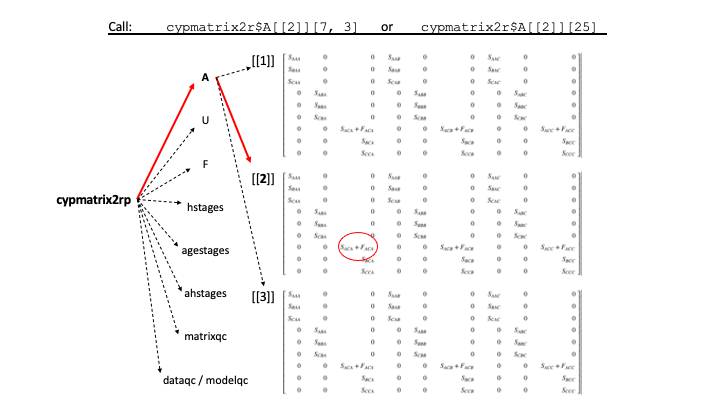

**Figure 3L.6.** Organization of a `lefkoMat` object, and how to call a specific element.

Objects of class `lefkoMat` have their own `summary` statements, which we can use to understand more about them.

```r
summary(cypmatrix2rp)
```

```
#>
#> This ahistorical lefkoMat object contains 15 matrices.
#>
#> Each matrix is a square matrix with 11 rows and columns, and a total of 121 elements.
#> A total of 251 survival transitions were estimated, with 16.733 per matrix.
#> A total of 70 fecundity transitions were estimated, with 4.667 per matrix.
#>
#> The dataset contains a total of 74 unique individuals and 320 unique transitions.
#>
#> Survival probability sum check (each matrix represented by column in order):
#>          [,1]  [,2]  [,3]  [,4]  [,5]  [,6]  [,7]  [,8]  [,9] [,10] [,11] [,12]
#> Min.    0.000 0.000 0.000 0.000 0.000 0.000 0.200 0.200 0.000 0.200 0.000 0.000
#> 1st Qu. 0.200 0.100 0.200 0.100 0.200 0.200 0.275 0.275 0.225 0.275 0.225 0.225
#> Median  0.300 0.250 0.300 0.250 0.300 0.300 0.909 0.778 0.800 0.857 1.000 0.750
#> Mean    0.524 0.427 0.541 0.389 0.484 0.531 0.699 0.672 0.597 0.697 0.632 0.586
#> 3rd Qu. 0.955 0.875 1.000 0.667 0.889 1.000 1.000 1.000 0.955 1.000 1.000 1.000
#> Max.    1.000 1.000 1.000 1.000 1.000 1.000 1.000 1.000 1.000 1.000 1.000 1.000
#>         [,13] [,14] [,15]
#> Min.    0.000 0.000 0.000
#> 1st Qu. 0.200 0.200 0.225
#> Median  0.300 0.300 1.000
#> Mean    0.495 0.511 0.632
#> 3rd Qu. 0.875 1.000 1.000
#> Max.    1.000 1.000 1.000
#> NULL
```

We start off learning that 15 matrices were estimated, and we learn the dimensionality of those matrices. Of note here is the output telling us how many elements were actually estimated, both overall and per matrix, and the number of individuals and transitions the matrices are based on. It is typical for population ecologists to consider the total number of transitions in a dataset as a measure of the statistical power of a matrix, but the number of individuals used is just as important because each transition that an individual experiences is dependent on the other transitions that it also experiences. Indeed, this is the fundamental point that led to the development of historical matrices and of this package - the assumption that the status of an individual in the next time is dependent only on its current state is too simplistic, and may lead to both overparameterization and pseudoreplication (if vital rate models are used). The final bit of the summary shows us the range of survival probabilities of stages in the matrices, where the survival probabilities are calculated as column sums of each `U` matrix. Since there are 15 matrices, there are 15 summaries. It is important to check to see that no stage survives outside the realm of possibility (i.e. no probability should be greater than 1.0 or lower than 0.0).

The input for the `rlefko2()` function includes `patch = "all"` and `year = "all"`, but can be set to focus on any set of patches/subpopulations or years included within the data. Package `lefko3` includes a great deal of flexibility here, and can estimate many matrices covering all of the populations, patches, and years occurring in a specific dataset. For example, if we had wished to skip the patch divisions within the population and instead estimate only annual matrices at the population level, then we could have eliminated the `patch` option altogether from the input, as below.

```r
cypmatrix2r <- rlefko2(data = cypraw_v1, stageframe = cypframe_raw,
  year = "all", stages = c("stage3", "stage2"),
  size = c("size3added", "size2added"), supplement = cypsupp2_raw,
  yearcol = "year2", patchcol = "patchid", indivcol = "individ")

summary(cypmatrix2r)
```

```
#>
#> This ahistorical lefkoMat object contains 5 matrices.
#>
#> Each matrix is a square matrix with 11 rows and columns, and a total of 121 elements.
#> A total of 115 survival transitions were estimated, with 23 per matrix.
#> A total of 40 fecundity transitions were estimated, with 8 per matrix.
#>
#> The dataset contains a total of 74 unique individuals and 320 unique transitions.
#>
#> Survival probability sum check (each matrix represented by column in order):
#>          [,1]  [,2]  [,3]  [,4]  [,5]
#> Min.    0.000 0.200 0.200 0.000 0.200
#> 1st Qu. 0.225 0.275 0.275 0.225 0.275
#> Median  0.913 0.870 0.864 0.800 0.900
#> Mean    0.620 0.696 0.694 0.593 0.694
#> 3rd Qu. 1.000 1.000 1.000 0.960 1.000
#> Max.    1.000 1.000 1.000 1.000 1.000
#> NULL
```

Notice what happened here. The first call to `rlefko2()` yielded 15 matrices, because there are 3 patches in our dataset, and there are a total of 6 years of data, yielding 5 transitions between years (also refered to as time steps or periods). So, there are $3 \times 5 = 15$ matrices. But in the second call, we no longer recognize patches and so have only estimated one set of 5 matrices covering the whole population. We can also focus in on specific patches and specific sets of years, setting the options appropriately.

Now let’s estimate a raw, historical MPM, using the `rlefko3()` function.

```r
cypmatrix3rp <- rlefko3(data = cypraw_v1, stageframe = cypframe_raw,
  year = "all", patch = "all", stages = c("stage3", "stage2", "stage1"),
  size = c("size3added", "size2added", "size1added"), supplement = cypsupp3_raw,
  yearcol = "year2", patchcol = "patchid", indivcol = "individ")

summary(cypmatrix3rp)
```

```
#>
#> This historical lefkoMat object contains 12 matrices.
#>
#> Each matrix is a square matrix with 121 rows and columns, and a total of 14641 elements.
#> A total of 392 survival transitions were estimated, with 32.667 per matrix.
#> A total of 68 fecundity transitions were estimated, with 5.667 per matrix.
#>
#> The dataset contains a total of 74 unique individuals and 320 unique transitions.
#>
#> Survival probability sum check (each matrix represented by column in order):
#>           [,1]   [,2]   [,3]   [,4]  [,5]  [,6]  [,7]  [,8]  [,9]  [,10] [,11]
#> Min.    0.0000 0.0000 0.0000 0.0000 0.000 0.000 0.000 0.000 0.000 0.0000 0.000
#> 1st Qu. 0.0000 0.0000 0.0000 0.0000 0.000 0.000 0.000 0.000 0.000 0.0000 0.000
#> Median  0.0000 0.0000 0.0000 0.0000 0.000 0.000 0.000 0.000 0.000 0.0000 0.000
#> Mean    0.0994 0.0864 0.0781 0.0926 0.141 0.143 0.137 0.152 0.111 0.0864 0.111
#> 3rd Qu. 0.0000 0.0000 0.0000 0.0000 0.000 0.000 0.000 0.000 0.000 0.0000 0.000
#> Max.    1.0000 1.0000 1.0000 1.0000 1.000 1.000 1.000 1.000 1.000 1.0000 1.000
#>         [,12]
#> Min.    0.000
#> 1st Qu. 0.000
#> Median  0.000
#> Mean    0.136
#> 3rd Qu. 0.000
#> Max.    1.000
#> NULL
```

Quikcly scanning this output shows a number of differences. First, there are 3 fewer matrices here than in the ahistorical case. There are 3 patches that we are estimating matrices for, and 6 years of data for each patch, leading to 5 possible ahistorical time steps and 15 possible ahistorical matrices. Since historical matrices require 3 years of transition data, only 4 historical transitions are possible per patch, leading to 12 total historical matrices. Second, the dimensionality of the matrices is the square of the dimensions of the ahistorical matrices. This leads to vastly more matrix elements within each matrix, although it turns out that most of these matrix elements are structural 0s because they reflect impossible transitions. Indeed, in this case, although there are 14,641 elements in each matrix, on average only 38.333 are actually estimated greater than 0.

Let’s look at the first matrix, corresponding to the transition from 2004 and 2005 to 2006 in the first patch. Because this is a huge matrix, we will only look at the top corner, followed by a middle section. The full matrix is not shown here, but we can focus on portions of it if we wish. These matrices may also be exported to Excel or another spreadsheet program to look over in detail. Particularly note the sparseness - most elements are 0s, because most transitions are actually impossible.

```r
cypmatrix3rp$A[[1]][1:20,1:10]
```

```
#>       [,1] [,2] [,3] [,4] [,5] [,6] [,7] [,8] [,9] [,10]
#>  [1,]  0.1  0.0    0    0    0    0    0    0    0     0
#>  [2,]  0.2  0.0    0    0    0    0    0    0    0     0
#>  [3,]  0.0  0.0    0    0    0    0    0    0    0     0
#>  [4,]  0.0  0.0    0    0    0    0    0    0    0     0
#>  [5,]  0.0  0.0    0    0    0    0    0    0    0     0
#>  [6,]  0.0  0.0    0    0    0    0    0    0    0     0
#>  [7,]  0.0  0.0    0    0    0    0    0    0    0     0
#>  [8,]  0.0  0.0    0    0    0    0    0    0    0     0
#>  [9,]  0.0  0.0    0    0    0    0    0    0    0     0
#> [10,]  0.0  0.0    0    0    0    0    0    0    0     0
#> [11,]  0.0  0.0    0    0    0    0    0    0    0     0
#> [12,]  0.0  0.0    0    0    0    0    0    0    0     0
#> [13,]  0.0  0.0    0    0    0    0    0    0    0     0
#> [14,]  0.0  0.2    0    0    0    0    0    0    0     0
#> [15,]  0.0  0.0    0    0    0    0    0    0    0     0
#> [16,]  0.0  0.0    0    0    0    0    0    0    0     0
#> [17,]  0.0  0.0    0    0    0    0    0    0    0     0
#> [18,]  0.0  0.0    0    0    0    0    0    0    0     0
#> [19,]  0.0  0.0    0    0    0    0    0    0    0     0
#> [20,]  0.0  0.0    0    0    0    0    0    0    0     0
```

```r
print(cypmatrix3rp$A[[1]][66:85,73:81], digits = 3)
```

```
#>         [,1]  [,2] [,3] [,4] [,5] [,6] [,7] [,8] [,9]
#>  [1,] 0.0000 0.000    0    0    0    0    0    0    0
#>  [2,] 0.0714 0.000    0    0    0    0    0    0    0
#>  [3,] 0.0714 0.000    0    0    0    0    0    0    0
#>  [4,] 0.0000 0.000    0    0    0    0    0    0    0
#>  [5,] 0.0000 0.000    0    0    0    0    0    0    0
#>  [6,] 0.0000 0.000    0    0    0    0    0    0    0
#>  [7,] 0.1429 0.000    0    0    0    0    0    0    0
#>  [8,] 0.7143 0.000    0    0    0    0    0    0    0
#>  [9,] 0.0000 0.000    0    0    0    0    0    0    0
#> [10,] 0.0000 0.000    0    0    0    0    0    0    0
#> [11,] 0.0000 0.000    0    0    0    0    0    0    0
#> [12,] 0.0000 0.000    0    0    0    0    0    0    0
#> [13,] 0.0000 0.333    0    0    0    0    0    0    0
#> [14,] 0.0000 0.333    0    0    0    0    0    0    0
#> [15,] 0.0000 0.000    0    0    0    0    0    0    0
#> [16,] 0.0000 0.000    0    0    0    0    0    0    0
#> [17,] 0.0000 0.000    0    0    0    0    0    0    0
#> [18,] 0.0000 0.000    0    0    0    0    0    0    0
#> [19,] 0.0000 0.667    0    0    0    0    0    0    0
#> [20,] 0.0000 0.333    0    0    0    0    0    0    0
```

Now let’s estimate the function-based matrices. Let’s start off with the ahistorical function-based matrix.

```r
cypmatrix2fp <- flefko2(stageframe = cypframe_fb, supplement = cypsupp2_fb,
  modelsuite = cypmodels2p, data = cypfb_v1, patch.as.random = TRUE,
  year.as.random = TRUE)

summary(cypmatrix2fp)
```

```
#>
#> This ahistorical lefkoMat object contains 15 matrices.
#>
#> Each matrix is a square matrix with 54 rows and columns, and a total of 2916 elements.
#> A total of 36165 survival transitions were estimated, with 2411 per matrix.
#> A total of 720 fecundity transitions were estimated, with 48 per matrix.
#>
#> Vital rate modeling quality control:
#>
#> Survival estimated with 74 individuals and 320 individual transitions.
#> Observation estimated with 70 individuals and 303 individual transitions.
#> Size estimated with 70 individuals and 288 individual transitions.
#> Reproductive status estimated with 70 individuals and 288 individual transitions.
#> Fecundity estimated with 51 individuals and 118 individual transitions.
#> Juvenile survival not estimated.
#> Juvenile observation probability not estimated.
#> Juvenile size transition not estimated.
#> Juvenile reproduction probability not estimated.
#>
#> Survival probability sum check (each matrix represented by column in order):
#>          [,1]  [,2]  [,3]  [,4]  [,5]  [,6]  [,7]  [,8]  [,9] [,10] [,11] [,12]
#> Min.    0.100 0.100 0.100 0.100 0.100 0.100 0.100 0.100 0.100 0.100 0.100 0.100
#> 1st Qu. 0.991 0.991 0.991 0.991 0.991 0.991 0.991 0.991 0.991 0.991 0.991 0.991
#> Median  1.000 1.000 1.000 1.000 1.000 1.000 1.000 1.000 1.000 1.000 1.000 1.000
#> Mean    0.924 0.927 0.926 0.926 0.922 0.924 0.927 0.926 0.926 0.923 0.922 0.926
#> 3rd Qu. 1.000 1.000 1.000 1.000 1.000 1.000 1.000 1.000 1.000 1.000 1.000 1.000
#> Max.    1.000 1.000 1.000 1.000 1.000 1.000 1.000 1.000 1.000 1.000 1.000 1.000
#>         [,13] [,14] [,15]
#> Min.    0.100 0.100 0.100
#> 1st Qu. 0.991 0.991 0.991
#> Median  1.000 1.000 1.000
#> Mean    0.925 0.924 0.920
#> 3rd Qu. 1.000 1.000 1.000
#> Max.    1.000 1.000 1.000
#> NULL
```

Here we have the same number of patches, and patch-level matrices were estimated without us needing to specify anything because patch was a factor in the vital rate models. The same number of matrices were created as in the raw case, but the raw MPM process yielded an average of 21.4 estimated transitions per matrix and only 11 rows and 11 columns matrix per. In contrast, the function-based MPM process led to 2,459 elements per matrix and 54 rows and 54 columns per matrix. This happens because we are using our vital rate models to propagate every matrix element that is biologically possible, and across a wider number of stages. To see the impact, let’s compare the first raw matrix to the first function-based matrix, as below.

```r
writeLines("First matrix in raw ahMPM:")
```

```
#> First matrix in raw ahMPM:
```

```r
print(cypmatrix2rp$A[[1]], digits = 3)
```

```
#>       [,1] [,2] [,3] [,4]  [,5] [,6]  [,7] [,8]  [,9] [,10] [,11]
#>  [1,]  0.1  0.0  0.0 0.00 0.000    0 0.000  0.1 0.333     0     0
#>  [2,]  0.2  0.0  0.0 0.00 0.000    0 0.000  0.1 0.333     0     0
#>  [3,]  0.0  0.2  0.0 0.00 0.000    0 0.000  0.0 0.000     0     0
#>  [4,]  0.0  0.0  0.2 0.00 0.000    0 0.000  0.0 0.000     0     0
#>  [5,]  0.0  0.0  0.0 0.25 0.000    0 0.000  0.0 0.000     0     0
#>  [6,]  0.0  0.0  0.0 0.00 0.000    0 0.000  0.0 0.000     0     0
#>  [7,]  0.0  0.0  0.0 0.00 0.636    0 0.636  0.2 0.000     0     0
#>  [8,]  0.0  0.0  0.0 0.00 0.273    0 0.273  0.6 0.667     1     0
#>  [9,]  0.0  0.0  0.0 0.00 0.000    0 0.000  0.2 0.333     0     0
#> [10,]  0.0  0.0  0.0 0.00 0.000    0 0.000  0.0 0.000     0     0
#> [11,]  0.0  0.0  0.0 0.00 0.000    0 0.000  0.0 0.000     0     0
```

```r
writeLines("\nFirst matrix in function-based ahMPM:")
```

```
#>
#> First matrix in function-based ahMPM:
```

```r
print(cypmatrix2fp$A[[1]], digits = 3)
```

```
#>       [,1] [,2] [,3]  [,4]  [,5]     [,6]     [,7]     [,8]     [,9]    [,10]
#>  [1,] 0.08  0.0  0.0 0.000 0.000 0.00e+00 0.00e+00 0.00e+00 0.00e+00 0.00e+00
#>  [2,] 0.10  0.0  0.0 0.000 0.000 0.00e+00 0.00e+00 0.00e+00 0.00e+00 0.00e+00
#>  [3,] 0.00  0.1  0.0 0.000 0.000 0.00e+00 0.00e+00 0.00e+00 0.00e+00 0.00e+00
#>  [4,] 0.00  0.0  0.1 0.000 0.000 0.00e+00 0.00e+00 0.00e+00 0.00e+00 0.00e+00
#>  [5,] 0.00  0.0  0.0 0.125 0.200 0.00e+00 0.00e+00 0.00e+00 0.00e+00 0.00e+00
#>  [6,] 0.00  0.0  0.0 0.000 0.047 4.70e-02 3.69e-02 2.81e-02 2.10e-02 1.56e-02
#>  [7,] 0.00  0.0  0.0 0.000 0.244 2.44e-01 2.44e-01 2.36e-01 2.22e-01 2.06e-01
#>  [8,] 0.00  0.0  0.0 0.000 0.206 2.06e-01 2.11e-01 2.08e-01 2.01e-01 1.90e-01
#>  [9,] 0.00  0.0  0.0 0.000 0.117 1.17e-01 1.22e-01 1.23e-01 1.21e-01 1.17e-01
#> [10,] 0.00  0.0  0.0 0.000 0.000 4.94e-02 5.28e-02 5.44e-02 5.48e-02 5.42e-02
#> [11,] 0.00  0.0  0.0 0.000 0.000 1.67e-02 1.83e-02 1.93e-02 1.98e-02 2.00e-02
#> [12,] 0.00  0.0  0.0 0.000 0.000 4.72e-03 5.27e-03 5.68e-03 5.98e-03 6.18e-03
#> [13,] 0.00  0.0  0.0 0.000 0.000 1.14e-03 1.30e-03 1.44e-03 1.54e-03 1.63e-03
#> [14,] 0.00  0.0  0.0 0.000 0.000 2.42e-04 2.82e-04 3.18e-04 3.49e-04 3.77e-04
```

[output cut: 370 more lines]

Finally, let’s estimate the function-based historical MPM.

```r
cypmatrix3fp <- flefko3(stageframe = cypframe_fb, supplement = cypsupp3_fb,
  modelsuite = cypmodels3p, data = cypfb_v1, yearcol = "year2",
  year.as.random = TRUE)

summary(cypmatrix3fp)
```

```
#>
#> This historical lefkoMat object contains 15 matrices.
#>
#> Each matrix is a square matrix with 2916 rows and columns, and a total of 8503056 elements.
#> A total of 1765680 survival transitions were estimated, with 117712 per matrix.
#> A total of 35280 fecundity transitions were estimated, with 2352 per matrix.
#>
#> Vital rate modeling quality control:
#>
#> Survival estimated with 74 individuals and 320 individual transitions.
#> Observation estimated with 70 individuals and 303 individual transitions.
#> Size estimated with 70 individuals and 288 individual transitions.
#> Reproductive status estimated with 70 individuals and 288 individual transitions.
#> Fecundity estimated with 51 individuals and 118 individual transitions.
#> Juvenile survival not estimated.
#> Juvenile observation probability not estimated.
#> Juvenile size transition not estimated.
#> Juvenile reproduction probability not estimated.
#>
#> Survival probability sum check (each matrix represented by column in order):
#>          [,1]  [,2]  [,3]  [,4]  [,5]  [,6]  [,7]  [,8]  [,9] [,10] [,11] [,12]
#> Min.    0.000 0.000 0.000 0.000 0.000 0.000 0.000 0.000 0.000 0.000 0.000 0.000
#> 1st Qu. 0.965 0.965 0.965 0.965 0.965 0.965 0.965 0.965 0.965 0.965 0.965 0.965
#> Median  1.000 1.000 1.000 1.000 1.000 1.000 1.000 1.000 1.000 1.000 1.000 1.000
#> Mean    0.819 0.819 0.819 0.819 0.819 0.819 0.819 0.819 0.819 0.819 0.819 0.819
#> 3rd Qu. 1.000 1.000 1.000 1.000 1.000 1.000 1.000 1.000 1.000 1.000 1.000 1.000
#> Max.    1.000 1.000 1.000 1.000 1.000 1.000 1.000 1.000 1.000 1.000 1.000 1.000
#>         [,13] [,14] [,15]
#> Min.    0.000 0.000 0.000
#> 1st Qu. 0.965 0.965 0.965
#> Median  1.000 1.000 1.000
#> Mean    0.819 0.819 0.819
#> 3rd Qu. 1.000 1.000 1.000
#> Max.    1.000 1.000 1.000
#> NULL
```

Let’s note the contrasts with the other MPMs in the output above. First, we see 15 matrices produced again. However, in the raw hMPM, we only saw 12 matrices, because of the fact that we need 3 monitoring occasions of data to parameterize each raw transition (6 monitoring occasions total means 4 sets of 3 monitoring occasions, or 4 total time steps, in the historical case). However, this is a function-based MPM, meaning that we can use our functions to estimate transitions in the first year set even without a full set of 3 years of data. The result is 5 time steps that we can estimate transitions for.

Second, these matrices are utterly huge. They have $54^2 = 2916$ rows and columns, yielding 8,503,056 total elements per matrix. Our raw hMPM had $11^2 = 121$ rows and columns, yielding 14,641 elements per matrix. Finally, although the raw hMPMs only had an average of 38.333 elements estimated per matrix, here we have 120,064 elements estimated per matrix. This is vastly more. However, it is also just a small fraction of the total number of elements in the matrix. In fact, in an unreduced hMPM estimated in Ehrlén format, the total number of elements that can be estimated is equal to $\frac{r \times c}{m}$, where $r$ and $c$ are the numbers of rows and columns, respectively, and $m$ is the number of stages in the stageframe. For example, if there are 10 stages in the stageframe, then only 10% of the elements in the hMPM are estimable.

Now that we have created our MPMs, we might wish to create element-wise arithmetic mean matrices to aid some inference and further analysis. For example, we might be interested in developing patch-level means and an overall population mean, but one in which the element means treat each patch and each year as equal in proportional effect. For this purpose, we can use the `lmean()` function. Let’s take a look at the mean raw ahMPM first.

```r
cyp2rp_mean <- lmean(cypmatrix2rp)

cyp2rp_mean
```

```
#> $A
#> $A[[1]]
#>       [,1] [,2] [,3] [,4]       [,5]       [,6]       [,7]       [,8]
#>  [1,]  0.1  0.0  0.0 0.00 0.00000000 0.00000000 0.01250000 0.08444444
#>  [2,]  0.2  0.0  0.0 0.00 0.00000000 0.00000000 0.01250000 0.08444444
#>  [3,]  0.0  0.2  0.0 0.00 0.00000000 0.00000000 0.00000000 0.00000000
#>  [4,]  0.0  0.0  0.2 0.00 0.00000000 0.00000000 0.00000000 0.00000000
#>  [5,]  0.0  0.0  0.0 0.25 0.00000000 0.00000000 0.00000000 0.00000000
#>  [6,]  0.0  0.0  0.0 0.00 0.05833333 0.00000000 0.05833333 0.04444444
#>  [7,]  0.0  0.0  0.0 0.00 0.59949495 0.06666667 0.59949495 0.19555556
#>  [8,]  0.0  0.0  0.0 0.00 0.21010101 0.33333333 0.21010101 0.59555556
#>  [9,]  0.0  0.0  0.0 0.00 0.00000000 0.00000000 0.00000000 0.08444444
#> [10,]  0.0  0.0  0.0 0.00 0.00000000 0.00000000 0.00000000 0.00000000
#> [11,]  0.0  0.0  0.0 0.00 0.00000000 0.00000000 0.00000000 0.00000000
#>             [,9] [,10] [,11]
```

[output cut: 339 more lines]

A quick scan through our output shows that we have 4 matrices. The `labels` element shows us the order of these. There is no time term in the `labels` element, because all matrices are temporal means. Instead, we see that the first 3 matrices are the patch-level means for patches `A`, `B`, and `C`. This is followed by the overall population mean matrix, listed as patch `0`. It also pays to look at the summary.

```r
summary(cyp2rp_mean)
```

```
#>
#> This ahistorical lefkoMat object contains 4 matrices.
#>
#> Each matrix is a square matrix with 11 rows and columns, and a total of 121 elements.
#> A total of 114 survival transitions were estimated, with 28.5 per matrix.
#> A total of 34 fecundity transitions were estimated, with 8.5 per matrix.
#>
#> Survival probability sum check (each matrix represented by column in order):
#>          [,1]  [,2]  [,3]  [,4]
#> Min.    0.000 0.200 0.200 0.200
#> 1st Qu. 0.200 0.275 0.225 0.275
#> Median  0.300 0.800 0.600 0.467
#> Mean    0.473 0.639 0.571 0.561
#> 3rd Qu. 0.868 0.917 0.867 0.868
#> Max.    1.000 1.000 1.000 1.000
#> NULL
```

And so we see that we have 4 matrices, and we see that these matricew have slightly more elements estimated, on average, than in the raw ahistorical MPM. This happened because some of the 0s in the original raw MPM were 0s only because of a sampling issue - no individuals actually transitioned through a particular transition in a particular year, but may have transitioned in other years, yielding higher numbers of non-zero elements in the arithmetic mean matrices than in the original raw matrices. A comparison with the function-based means should be interesting in this regard:

```r
cyp2fp_mean <- lmean(cypmatrix2fp)

summary(cyp2fp_mean)
```

```
#>
#> This ahistorical lefkoMat object contains 4 matrices.
#>
#> Each matrix is a square matrix with 54 rows and columns, and a total of 2916 elements.
#> A total of 9644 survival transitions were estimated, with 2411 per matrix.
#> A total of 192 fecundity transitions were estimated, with 48 per matrix.
#>
#> Survival probability sum check (each matrix represented by column in order):
#>          [,1]  [,2]  [,3]  [,4]
#> Min.    0.100 0.100 0.100 0.100
#> 1st Qu. 0.991 0.991 0.991 0.991
#> Median  1.000 1.000 1.000 1.000
#> Mean    0.925 0.925 0.924 0.925
#> 3rd Qu. 1.000 1.000 1.000 1.000
#> Max.    1.000 1.000 1.000 1.000
#> NULL
```

The function-based mean matrices have the same number of estimated transitions as their constituent matrices, because all elements that are estimable are actually estimated using the vital rate models supplied.

Now let’s create the final sets of arithmetic mean matrices for the hMPMs.

```r
cyp3rp_mean <- lmean(cypmatrix3rp)
cyp3fp_mean <- lmean(cypmatrix3fp)

summary(cyp3rp_mean)
```

```
#>
#> This historical lefkoMat object contains 4 matrices.
#>
#> Each matrix is a square matrix with 121 rows and columns, and a total of 14641 elements.
#> A total of 250 survival transitions were estimated, with 62.5 per matrix.
#> A total of 74 fecundity transitions were estimated, with 18.5 per matrix.
#>
#> Survival probability sum check (each matrix represented by column in order):
#>           [,1]  [,2]  [,3]  [,4]
#> Min.    0.0000 0.000 0.000 0.000
#> 1st Qu. 0.0000 0.000 0.000 0.000
#> Median  0.0000 0.000 0.000 0.000
#> Mean    0.0891 0.143 0.111 0.115
#> 3rd Qu. 0.0000 0.250 0.000 0.167
#> Max.    1.0000 1.000 1.000 0.991
#> NULL
```

```r
summary(cyp3fp_mean)
```

```
#>
#> This historical lefkoMat object contains 4 matrices.
#>
#> Each matrix is a square matrix with 2916 rows and columns, and a total of 8503056 elements.
#> A total of 470848 survival transitions were estimated, with 117712 per matrix.
#> A total of 9408 fecundity transitions were estimated, with 2352 per matrix.
#>
#> Survival probability sum check (each matrix represented by column in order):
#>          [,1]  [,2]  [,3]  [,4]
#> Min.    0.000 0.000 0.000 0.000
#> 1st Qu. 0.965 0.965 0.965 0.965
#> Median  1.000 1.000 1.000 1.000
#> Mean    0.819 0.819 0.819 0.819
#> 3rd Qu. 1.000 1.000 1.000 1.000
#> Max.    1.000 1.000 1.000 1.000
#> NULL
```

Finaly, let’s create the remaining population-level MPMs that have not been created.

```r
cypmatrix3r <- rlefko3(data = cypraw_v1, stageframe = cypframe_raw,
  year = "all", stages = c("stage3", "stage2", "stage1"),
  size = c("size3added", "size2added", "size1added"), supplement = cypsupp3_raw,
  yearcol = "year2", patchcol = "patchid", indivcol = "individ")

cypmatrix3f <- flefko3(stageframe = cypframe_fb, supplement = cypsupp3_fb,
  modelsuite = cypmodels3, data = cypfb_v1, yearcol = "year2",
  year.as.random = TRUE)

cypmatrix2f <- flefko2(stageframe = cypframe_fb, supplement = cypsupp2_fb,
  modelsuite = cypmodels2, data = cypfb_v1, patch.as.random = TRUE,
  year.as.random = TRUE)

cyp3r_mean <- lmean(cypmatrix3r)
cyp3f_mean <- lmean(cypmatrix3f)
cyp2r_mean <- lmean(cypmatrix2r)
cyp2f_mean <- lmean(cypmatrix2f)
```

#### Step 4b. Issues in modeling MPMs.

In this section, we wish to look at 4 issues that have arisen in MPM building so far - the use of supplement tables vs. overwrite tables and reproductive matrices, the importance of proper parameterization of size and fecundity, matrix dimensionality reduction, and Ehrlén format vs. deVries format. Let’s start with the first issue - supplement tables vs. overwrite tables and reproductive matrices.

All of the MPMs that we have built so far have utilized supplement tables to provide our matrix building functions with the extra information not supplied in the demographic dataset itself to properly parameterize MPMs. The supplement table is a very powerful of achieving this aim. However, the first publicly available versions of `lefko3` utilized a different approach based on some existing methods used in other packages - the overwrite table combined with a reproductive matrix. We do not advocate their use, mostly because properly parameterizing fecundity in particular is more difficult with this approach, but all matrix building functions retain the ability to utilize this method. Here we show a call to create a new, function-based ahMPM using the previously developed overwrite table and reproductive matrix instead of the correct supplemental table. We then compare the summaries.

```r
cypmatrix2f_overwrite <- flefko2(stageframe = cypframe_fb,
  overwrite = cypover2_fb, repmatrix = rep.assumptions_fb,
  modelsuite = cypmodels2, data = cypfb_v1, patch.as.random = TRUE,
  year.as.random = TRUE)

summary(cypmatrix2f_overwrite)
```

```
#>
#> This ahistorical lefkoMat object contains 5 matrices.
#>
#> Each matrix is a square matrix with 54 rows and columns, and a total of 2916 elements.
#> A total of 12055 survival transitions were estimated, with 2411 per matrix.
#> A total of 240 fecundity transitions were estimated, with 48 per matrix.
#>
#> Vital rate modeling quality control:
#>
#> Survival estimated with 74 individuals and 320 individual transitions.
#> Observation estimated with 70 individuals and 303 individual transitions.
#> Size estimated with 70 individuals and 288 individual transitions.
#> Reproductive status estimated with 70 individuals and 288 individual transitions.
#> Fecundity estimated with 51 individuals and 118 individual transitions.
#> Juvenile survival not estimated.
#> Juvenile observation probability not estimated.
#> Juvenile size transition not estimated.
#> Juvenile reproduction probability not estimated.
#>
#> Survival probability sum check (each matrix represented by column in order):
#>          [,1]  [,2]  [,3]  [,4]  [,5]
#> Min.    0.100 0.100 0.100 0.100 0.100
#> 1st Qu. 0.991 0.991 0.991 0.991 0.991
#> Median  1.000 1.000 1.000 1.000 1.000
#> Mean    0.924 0.927 0.926 0.926 0.922
#> 3rd Qu. 1.000 1.000 1.000 1.000 1.000
#> Max.    1.000 1.000 1.000 1.000 1.000
#> NULL
```

```r
summary(cypmatrix2f)
```

```
#>
#> This ahistorical lefkoMat object contains 5 matrices.
#>
#> Each matrix is a square matrix with 54 rows and columns, and a total of 2916 elements.
#> A total of 12055 survival transitions were estimated, with 2411 per matrix.
#> A total of 240 fecundity transitions were estimated, with 48 per matrix.
#>
#> Vital rate modeling quality control:
#>
#> Survival estimated with 74 individuals and 320 individual transitions.
#> Observation estimated with 70 individuals and 303 individual transitions.
#> Size estimated with 70 individuals and 288 individual transitions.
#> Reproductive status estimated with 70 individuals and 288 individual transitions.
#> Fecundity estimated with 51 individuals and 118 individual transitions.
#> Juvenile survival not estimated.
#> Juvenile observation probability not estimated.
#> Juvenile size transition not estimated.
#> Juvenile reproduction probability not estimated.
#>
#> Survival probability sum check (each matrix represented by column in order):
#>          [,1]  [,2]  [,3]  [,4]  [,5]
#> Min.    0.100 0.100 0.100 0.100 0.100
#> 1st Qu. 0.991 0.991 0.991 0.991 0.991
#> Median  1.000 1.000 1.000 1.000 1.000
#> Mean    0.924 0.927 0.926 0.926 0.922
#> 3rd Qu. 1.000 1.000 1.000 1.000 1.000
#> Max.    1.000 1.000 1.000 1.000 1.000
#> NULL
```

The summaries show exactly the same output, and if we went through each matrix with a fine-toothed comb, we would find no difference. However, it is possible to see differences in hMPMs, because of the difficulty in properly framing the reproductive matrix for the historical case. Please use the supplemental table approach to limit errors.

```r
cypmodels2_wrong <- modelsearch(cypfb_v1, historical = FALSE, approach = "mixed",
  vitalrates = c("surv", "obs", "size", "repst", "fec"),
  sizedist = "poisson", fecdist = "poisson", suite = "full",
  size = c("size3added", "size2added", "size1added"), quiet = TRUE)
cypmodels2p_wrong <- modelsearch(cypfb_v1, historical = FALSE, approach = "mixed",
  vitalrates = c("surv", "obs", "size", "repst", "fec"), patch = "patchid",
  sizedist = "poisson", fecdist = "poisson", suite = "full",
  size = c("size3added", "size2added", "size1added"), quiet = TRUE)
cypmatrix2f_wrong <- flefko2(stageframe = cypframe_fb, supplement = cypsupp2_fb,
  modelsuite = cypmodels2_wrong, data = cypfb_v1, patch.as.random = TRUE,
  year.as.random = TRUE)

cypmatrix2fp_wrong <- flefko2(stageframe = cypframe_fb, supplement = cypsupp2_fb,
  modelsuite = cypmodels2p_wrong, data = cypfb_v1, patch.as.random = TRUE,
  year.as.random = TRUE)

summary(cypmatrix2f_wrong)
```

```
#>
#> This ahistorical lefkoMat object contains 5 matrices.
#>
#> Each matrix is a square matrix with 54 rows and columns, and a total of 2916 elements.
#> A total of 12055 survival transitions were estimated, with 2411 per matrix.
#> A total of 240 fecundity transitions were estimated, with 48 per matrix.
#>
#> Vital rate modeling quality control:
#>
#> Survival estimated with 74 individuals and 320 individual transitions.
#> Observation estimated with 70 individuals and 303 individual transitions.
#> Size estimated with 70 individuals and 288 individual transitions.
#> Reproductive status estimated with 70 individuals and 288 individual transitions.
#> Fecundity estimated with 51 individuals and 118 individual transitions.
#> Juvenile survival not estimated.
#> Juvenile observation probability not estimated.
#> Juvenile size transition not estimated.
#> Juvenile reproduction probability not estimated.
#>
#> Survival probability sum check (each matrix represented by column in order):
#>          [,1]  [,2]  [,3]  [,4]  [,5]
#> Min.    0.100 0.100 0.100 0.100 0.100
#> 1st Qu. 0.963 0.938 0.948 0.958 0.962
#> Median  0.991 0.979 0.984 0.988 0.991
#> Mean    0.910 0.901 0.905 0.910 0.908
#> 3rd Qu. 0.998 0.994 0.996 0.997 0.998
#> Max.    1.000 0.999 0.999 1.000 1.000
#> NULL
```

```r
summary(cypmatrix2fp_wrong)
```

```
#>
#> This ahistorical lefkoMat object contains 15 matrices.
#>
#> Each matrix is a square matrix with 54 rows and columns, and a total of 2916 elements.
#> A total of 36165 survival transitions were estimated, with 2411 per matrix.
#> A total of 720 fecundity transitions were estimated, with 48 per matrix.
#>
#> Vital rate modeling quality control:
#>
#> Survival estimated with 74 individuals and 320 individual transitions.
#> Observation estimated with 70 individuals and 303 individual transitions.
#> Size estimated with 70 individuals and 288 individual transitions.
#> Reproductive status estimated with 70 individuals and 288 individual transitions.
#> Fecundity estimated with 51 individuals and 118 individual transitions.
#> Juvenile survival not estimated.
#> Juvenile observation probability not estimated.
#> Juvenile size transition not estimated.
#> Juvenile reproduction probability not estimated.
#>
#> Survival probability sum check (each matrix represented by column in order):
#>          [,1]  [,2]  [,3]  [,4]  [,5]  [,6]  [,7]  [,8]  [,9] [,10] [,11] [,12]
#> Min.    0.100 0.100 0.100 0.100 0.100 0.100 0.100 0.100 0.100 0.100 0.100 0.100
#> 1st Qu. 0.951 0.919 0.932 0.946 0.949 0.966 0.942 0.952 0.962 0.965 0.975 0.956
#> Median  0.986 0.969 0.976 0.982 0.985 0.992 0.981 0.986 0.990 0.992 0.996 0.988
#> Mean    0.905 0.892 0.898 0.904 0.903 0.911 0.903 0.907 0.911 0.910 0.913 0.908
#> 3rd Qu. 0.997 0.990 0.993 0.995 0.996 0.999 0.995 0.997 0.998 0.998 0.999 0.997
#> Max.    0.999 0.998 0.999 0.999 0.999 1.000 0.999 0.999 1.000 1.000 1.000 1.000
#>         [,13] [,14] [,15]
#> Min.    0.100 0.100 0.100
#> 1st Qu. 0.964 0.971 0.974
#> Median  0.991 0.994 0.995
#> Mean    0.911 0.914 0.911
#> 3rd Qu. 0.998 0.999 0.999
#> Max.    1.000 1.000 1.000
#> NULL
```

We will come back to this set later in our analyses.

The third issue is matrix dimensionality reduction. One issue that comes up particularly when creating historical matrices is that occasionally stage-pairs exist that are not associated with any transitions. The result is that the rows and columns associated with such a stage pair are completely full of 0s. In such a situation, the matrix can be reduced by eliminating the stage-pair altogether. The result is a set of smaller matrices, which is useful considering that historical MPMs are generally large and can take up lots of memory. We can tell R to develop reduced MPMs by using the `reduce = TRUE` option in the matrix generating function that we are using. Note that this option is available in ALL matrix generating functions, even for those creating ahistorical MPMs. Here, we create a reduced function-based hMPM, and then compare it to the unreduced function-based hMPM.

```r
cypmatrix3f_red <- flefko3(stageframe = cypframe_fb, supplement = cypsupp3_fb,
  modelsuite = cypmodels3, data = cypfb_v1, yearcol = "year2",
  year.as.random = TRUE, reduce = TRUE)

summary(cypmatrix3f_red)
```

```
#>
#> This historical lefkoMat object contains 5 matrices.
#>
#> Each matrix is a square matrix with 2459 rows and columns, and a total of 6046681 elements.
#> A total of 588560 survival transitions were estimated, with 117712 per matrix.
#> A total of 11760 fecundity transitions were estimated, with 2352 per matrix.
#>
#> Vital rate modeling quality control:
#>
#> Survival estimated with 74 individuals and 320 individual transitions.
#> Observation estimated with 70 individuals and 303 individual transitions.
#> Size estimated with 70 individuals and 288 individual transitions.
#> Reproductive status estimated with 70 individuals and 288 individual transitions.
#> Fecundity estimated with 51 individuals and 118 individual transitions.
#> Juvenile survival not estimated.
#> Juvenile observation probability not estimated.
#> Juvenile size transition not estimated.
#> Juvenile reproduction probability not estimated.
#>
#> Survival probability sum check (each matrix represented by column in order):
#>          [,1]  [,2]  [,3]  [,4]  [,5]
#> Min.    0.000 0.000 0.000 0.000 0.000
#> 1st Qu. 0.997 0.997 0.997 0.997 0.997
#> Median  1.000 1.000 1.000 1.000 1.000
#> Mean    0.971 0.971 0.971 0.971 0.971
#> 3rd Qu. 1.000 1.000 1.000 1.000 1.000
#> Max.    1.000 1.000 1.000 1.000 1.000
#> NULL
```

```r
summary(cypmatrix3f)
```

```
#>
#> This historical lefkoMat object contains 5 matrices.
#>
#> Each matrix is a square matrix with 2916 rows and columns, and a total of 8503056 elements.
#> A total of 588560 survival transitions were estimated, with 117712 per matrix.
#> A total of 11760 fecundity transitions were estimated, with 2352 per matrix.
#>
#> Vital rate modeling quality control:
#>
#> Survival estimated with 74 individuals and 320 individual transitions.
#> Observation estimated with 70 individuals and 303 individual transitions.
#> Size estimated with 70 individuals and 288 individual transitions.
#> Reproductive status estimated with 70 individuals and 288 individual transitions.
#> Fecundity estimated with 51 individuals and 118 individual transitions.
#> Juvenile survival not estimated.
#> Juvenile observation probability not estimated.
#> Juvenile size transition not estimated.
#> Juvenile reproduction probability not estimated.
#>
#> Survival probability sum check (each matrix represented by column in order):
#>          [,1]  [,2]  [,3]  [,4]  [,5]
#> Min.    0.000 0.000 0.000 0.000 0.000
#> 1st Qu. 0.965 0.965 0.965 0.965 0.965
#> Median  1.000 1.000 1.000 1.000 1.000
#> Mean    0.819 0.819 0.819 0.819 0.819
#> 3rd Qu. 1.000 1.000 1.000 1.000 1.000
#> Max.    1.000 1.000 1.000 1.000 1.000
#> NULL
```

Our new hMPM has matrices with 2459 rows and columns, while the original unreduced hMPM has matrices with 2916 rows and columns. This is a reduction of 457 rows and columns, with an overall reduction in the size of the matrix by 8,503,056 - 6,046,681 = 2,456,375 elements. In memory, the unreduced hMPM takes up 3.1GB while the reduced hMPM takes up 2.2GB. So, clearly this reduced set is preferable to the unreduced set.

Finally, we should consider the issue of the format of the hMPM. By default, we use Ehrlén format, which we find more intuitive and simpler to use. However, some prefer the format outlined in deVries & Caswell (2018). There is only one real difference between these formats, and that is the treatment of an individual that newly recruits in time *t*. deVries & Caswell (2018) argued that it is not logical to consider maternal state as the stage in time *t*-1 for an individual transitioning from newborn in time *t* to whatever its next stage is in time *t*+1. They therefore suggested that a prior “not yet born” stage should be added to the matrix to deal with issue. Thus, any individuals that is newly-born in time *t* is treated as having been in this extra stage in time *t*-1 (note that this stage is not considered as a part of the fecundity transition, but is instead counted ONLY in survival transitions for individuals new to the population in time *t*). This extra stage yields more stage-pairs in the hMPM, and causes some transitions to be split that would otherwise not be split in Ehrlén format. In any case, analyses using deVries format are not expected to yield any differences analytically from Ehrlén format, but the different matrix dimensions and small differences in treatment of some transitions will liekly yield small differences overall here and there. Functions `rlefko3()` and `flefko3()` both produce Ehrlén format matrices by default, but users can also produce deVries format matrices by setting `format = "deVries"`, as below.

```r
cypmatrix3f_dev <- flefko3(stageframe = cypframe_fb, supplement = cypsupp3_fb,
  modelsuite = cypmodels3, data = cypfb_v1, yearcol = "year2",
  year.as.random = TRUE, format = "deVries")

summary(cypmatrix3f_dev)
```

```
#>
#> This historical lefkoMat object contains 5 matrices.
#>
#> Each matrix is a square matrix with 2970 rows and columns, and a total of 8820900 elements.
#> A total of 600335 survival transitions were estimated, with 120067 per matrix.
#> A total of 11760 fecundity transitions were estimated, with 2352 per matrix.
#>
#> Vital rate modeling quality control:
#>
#> Survival estimated with 74 individuals and 320 individual transitions.
#> Observation estimated with 70 individuals and 303 individual transitions.
#> Size estimated with 70 individuals and 288 individual transitions.
#> Reproductive status estimated with 70 individuals and 288 individual transitions.
#> Fecundity estimated with 51 individuals and 118 individual transitions.
#> Juvenile survival not estimated.
#> Juvenile observation probability not estimated.
#> Juvenile size transition not estimated.
#> Juvenile reproduction probability not estimated.
#>
#> Survival probability sum check (each matrix represented by column in order):
#>          [,1]  [,2]  [,3]  [,4]  [,5]
#> Min.    0.000 0.000 0.000 0.000 0.000
#> 1st Qu. 0.965 0.965 0.965 0.965 0.965
#> Median  1.000 1.000 1.000 1.000 1.000
#> Mean    0.819 0.819 0.819 0.819 0.819
#> 3rd Qu. 1.000 1.000 1.000 1.000 1.000
#> Max.    1.000 1.000 1.000 1.000 1.000
#> NULL
```

```r
summary(cypmatrix3f)
```

```
#>
#> This historical lefkoMat object contains 5 matrices.
#>
#> Each matrix is a square matrix with 2916 rows and columns, and a total of 8503056 elements.
#> A total of 588560 survival transitions were estimated, with 117712 per matrix.
#> A total of 11760 fecundity transitions were estimated, with 2352 per matrix.
#>
#> Vital rate modeling quality control:
#>
#> Survival estimated with 74 individuals and 320 individual transitions.
#> Observation estimated with 70 individuals and 303 individual transitions.
#> Size estimated with 70 individuals and 288 individual transitions.
#> Reproductive status estimated with 70 individuals and 288 individual transitions.
#> Fecundity estimated with 51 individuals and 118 individual transitions.
#> Juvenile survival not estimated.
#> Juvenile observation probability not estimated.
#> Juvenile size transition not estimated.
#> Juvenile reproduction probability not estimated.
#>
#> Survival probability sum check (each matrix represented by column in order):
#>          [,1]  [,2]  [,3]  [,4]  [,5]
#> Min.    0.000 0.000 0.000 0.000 0.000
#> 1st Qu. 0.965 0.965 0.965 0.965 0.965
#> Median  1.000 1.000 1.000 1.000 1.000
#> Mean    0.819 0.819 0.819 0.819 0.819
#> 3rd Qu. 1.000 1.000 1.000 1.000 1.000
#> Max.    1.000 1.000 1.000 1.000 1.000
#> NULL
```

#### Step 5. MPM analysis

Now let’s estimate the asymptotic deterministic population growth rate for each of the four sets of patch-level MPMs. We will start by looking at the annual population growth rate estimated from the raw analyses.

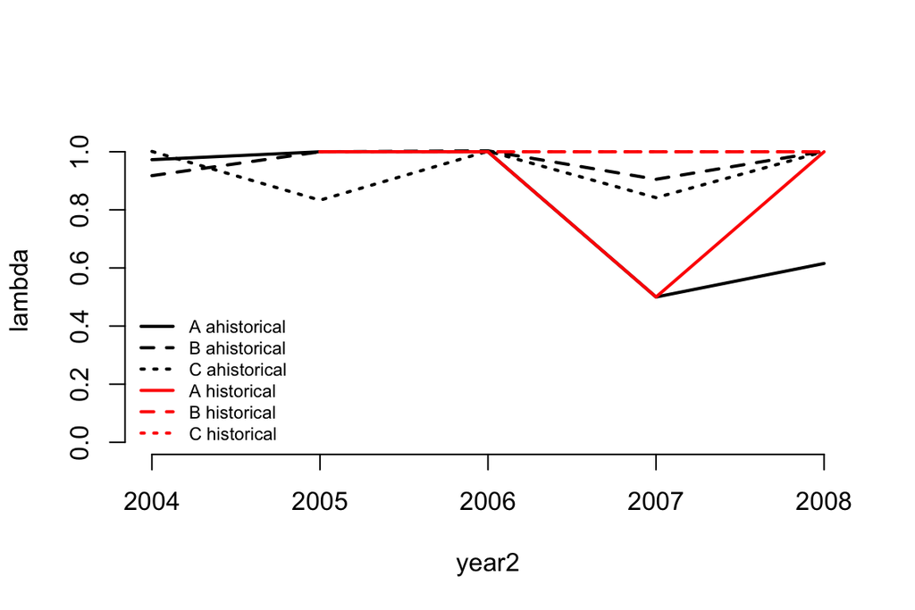

Figure 3L.7. Ahistorical vs. historical, raw lambda

```r
cyp2rp_lam <- lambda3(cypmatrix2rp)
cyp2fp_lam <- lambda3(cypmatrix2fp)
cyp3rp_lam <- lambda3(cypmatrix3rp)
cyp3fp_lam <- lambda3(cypmatrix3fp)

plot(lambda ~ year2, data = subset(cyp2rp_lam, patch == "A"),
  ylim = c(0, 1.05), type = "l", lwd = 2, bty = "n")
lines(lambda ~ year2, data = subset(cyp2rp_lam, patch == "B"), type = "l",
  lwd = 2, lty = 2)
lines(lambda ~ year2, data = subset(cyp2rp_lam, patch == "C"), type = "l",
  lwd = 2, lty = 3)
lines(lambda ~ year2, data = subset(cyp3rp_lam, patch == "A"), type = "l",
  lwd = 2, lty = 1, col = "red")
lines(lambda ~ year2, data = subset(cyp3rp_lam, patch == "B"), type = "l",
  lwd = 2, lty = 2, col = "red")
lines(lambda ~ year2, data = subset(cyp3rp_lam, patch == "C"), type = "l",
  lwd = 2, lty = 3, col = "red")
legend("bottomleft", c("A ahistorical", "B ahistorical", "C ahistorical",
    "A historical", "B historical", "C historical"), lty = c(1, 2, 3, 1, 2, 3),
  col = c("black", "black", "black", "red", "red", "red"), lwd = 2, cex = 0.7,
  bty = "n")
```

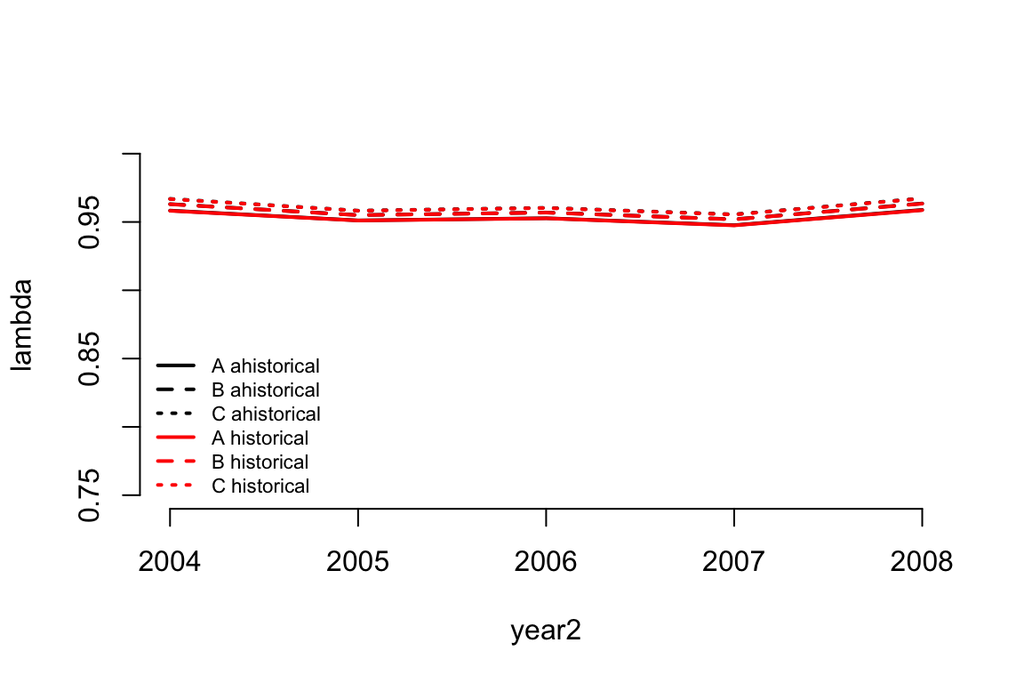

Figure 3L.8. Ahistorical vs. historical, function-based lambda

```r
plot(lambda ~ year2, data = subset(cyp2fp_lam, patch == "A"),
  ylim = c(0.75, 1.00), type = "l", lwd = 2, bty = "n")
lines(lambda ~ year2, data = subset(cyp2fp_lam, patch == "B"), type = "l",
  lwd = 2, lty = 2)
lines(lambda ~ year2, data = subset(cyp2fp_lam, patch == "C"), type = "l",
  lwd = 2, lty = 3)
lines(lambda ~ year2, data = subset(cyp3fp_lam, patch == "A"), type = "l",
  lwd = 2, lty = 1, col = "red")
lines(lambda ~ year2, data = subset(cyp3fp_lam, patch == "B"), type = "l",
  lwd = 2, lty = 2, col = "red")
lines(lambda ~ year2, data = subset(cyp3fp_lam, patch == "C"), type = "l",
  lwd = 2, lty = 3, col = "red")
legend("bottomleft", c("A ahistorical", "B ahistorical", "C ahistorical",
    "A historical", "B historical", "C historical"), lty = c(1, 2, 3, 1, 2, 3),
  col = c("black", "black", "black", "red", "red", "red"), lwd = 2, cex = 0.7,
  bty = "n")
```

Note that we see very different predictions from the function-based MPMs than from the raw MPMs here. The reason for this is that raw MPMs are parameterized by the actual transitions that were documented during the study, while the function-based MPMs are parameterized with the vital rate models, which represent process variance and exclude error that cannot be attributed to the modeled factors. In a sufficiently small dataset, many transitions will be lacking in the raw MPMs because there are too few individual to propagate all transition estimates. The function-based approach, in contrast, is parameterized by vital rate models that use the dataset as a whole to identify trends, rather than being susceptible to the seemingly random nature in which individuals contribute to transitions. Note, however, that smaller datasets will also affect function-based MPMs by yielding vital rate models that are less variable and less influenced by tested factors, as a result of lost statistical power. The literature has steadily given preference to function-based models like IPMs over the years, but which approach is more appropriate is actually a difficult question that is likely to vary by study.

Now let’s compare the overall $\lambda$ of the patch-level arithmetic mean matrices, and the stochastic log growth rate, $a = \text{log} \lambda _{S}$. To make sure that our stochastic growth rate estimates equal yours, we will use the `set.seed()` function prior to each stochastic run. We will also use the defaults, which include estimation via 10,000 time steps and equivalent time weights.

```r
writeLines("Raw ahistorical lambda:")
```

```
#> Raw ahistorical lambda:
```

```r
lambda3(cyp2rp_mean)
```

```
#>   pop patch    lambda
#> 1   1     A 0.8682549
#> 2   1     B 0.9344776
#> 3   1     C 0.9410828
#> 4   1     0 0.9006298
```

```r
writeLines("\nRaw historical lambda:")
```

```
#>
#> Raw historical lambda:
```

```r
lambda3(cyp3rp_mean)
```

```
#>   pop patch    lambda
#> 1   1     A 0.8220534
#> 2   1     B 0.8157691
#> 3   1     C 0.9050548
#> 4   1     0 0.7819680
```

```r
writeLines("\nFunction-based ahistorical lambda:")
```

```
#>
#> Function-based ahistorical lambda:
```

```r
lambda3(cyp2fp_mean)
```

```
#>   pop patch    lambda
#> 1   1     A 0.9538733
#> 2   1     B 0.9582385
#> 3   1     C 0.9618263
#> 4   1     0 0.9579628
```

```r
writeLines("\nFunction-based historical lambda:")
```

```
#>
#> Function-based historical lambda:
```

```r
lambda3(cyp3fp_mean)
```

```
#>   pop patch    lambda
#> 1   1     A 0.9536938
#> 2   1     B 0.9581121
#> 3   1     C 0.9616747
#> 4   1     0 0.9578090
```

```r
writeLines("Raw ahistorical stochastic log lambda:")
```

```
#> Raw ahistorical stochastic log lambda:
```

```r
set.seed(42)
slambda3(cypmatrix2rp)
```

```
#>   pop patch           a        var        sd          se
#> 1   1     A -0.15859951 0.04692391 0.2166193 0.002166193
#> 2   1     B -0.06894046 0.12382740 0.3518912 0.003518912
#> 3   1     C -0.06232015 0.04794901 0.2189726 0.002189726
#> 4   1     0 -0.10661148 0.03010180 0.1734987 0.001734987
```

```r
writeLines("\nRaw historical stochastic log lambda:")
```

```
#>
#> Raw historical stochastic log lambda:
```

```r
set.seed(42)
slambda3(cypmatrix3rp)
```

```
#>   pop patch          a        var        sd          se
#> 1   1     A -0.2233048 0.05568433 0.2359753 0.002359753
#> 2   1     B -0.2351821 0.15447777 0.3930366 0.003930366
#> 3   1     C -0.1237643 0.27154424 0.5210991 0.005210991
#> 4   1     0 -0.2582404 0.05270606 0.2295780 0.002295780
```

```r
writeLines("\nFunction-based ahistorical stochastic log lambda:")
```

```
#>
#> Function-based ahistorical stochastic log lambda:
```

```r
set.seed(42)
slambda3(cypmatrix2fp)
```

```
#>   pop patch           a         var         sd           se
#> 1   1     A -0.04717498 0.003996039 0.06321423 0.0006321423
#> 2   1     B -0.04263253 0.003093210 0.05561663 0.0005561663
#> 3   1     C -0.03886382 0.002057234 0.04535674 0.0004535674
#> 4   1     0 -0.04285387 0.003121392 0.05586942 0.0005586942
```

```r
writeLines("\nFunction-based historical stochastic log lambda:")
```

```
#>
#> Function-based historical stochastic log lambda:
```

```r
set.seed(42)
slambda3(cypmatrix3fp)
```

```
#>   pop patch           a         var         sd           se
#> 1   1     A -0.04736367 0.003888587 0.06235854 0.0006235854
#> 2   1     B -0.04276440 0.002966180 0.05446264 0.0005446264
#> 3   1     C -0.03902167 0.001955319 0.04421899 0.0004421899
#> 4   1     0 -0.04301555 0.003000474 0.05477658 0.0005477658
```

The $\lambda$ values for the function-based MPMs are similar to one another, but differ from the raw MPMs, the latter of which exhibit more variability and lower overall $a = \text{log} \lambda _{S}$. The increased level of temporal variability in matrix elements in the raw case led to this scenario, since the stochastic growth rate is more sensitive to temporal variability than the deterministic growth rate is.

As a comparison, we might wish to see what our growth rate estimates are when we assume the wrong distributions for size and fecundity.

```r
wrong_mean_p <- lmean(cypmatrix2fp_wrong)
lambda3(wrong_mean_p)
```

```
#>   pop patch    lambda
#> 1   1     A 0.9093268
#> 2   1     B 0.9348362
#> 3   1     C 0.9513331
#> 4   1     0 0.9321390
```

```r
set.seed(42)
slambda3(cypmatrix2fp_wrong)
```

```
#>   pop patch           a        var        sd          se
#> 1   1     A -0.09471555 0.02104845 0.1450808 0.001450808
#> 2   1     B -0.06729008 0.03963883 0.1990950 0.001990950
#> 3   1     C -0.04992092 0.02740437 0.1655427 0.001655427
#> 4   1     0 -0.07009337 0.03073990 0.1753280 0.001753280
```

Notice that our estimates are a little lower than for the other function-based MPMs. The fact that they are lower is not necessarily expected - only that they are different.

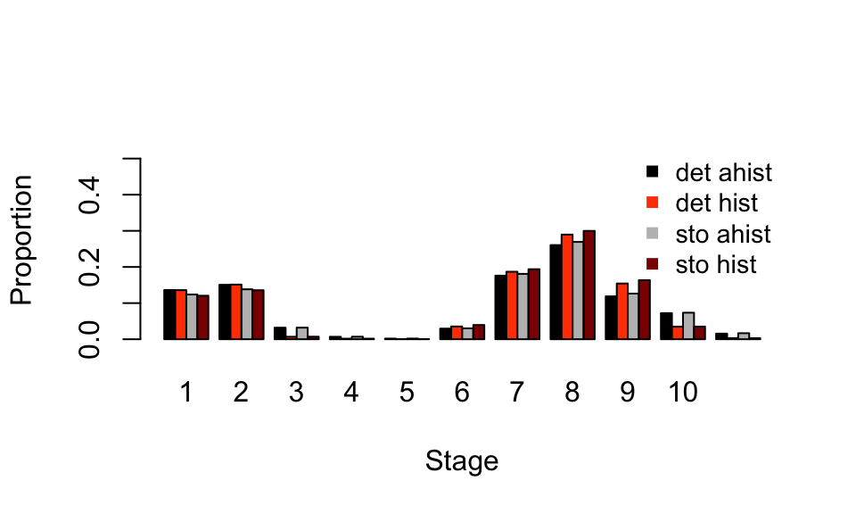

Figure 3L.9. Ahistorical vs. historically-corrected stable and long-run mean stage distribution, raw MPMs

```r
tm2ss_r <- stablestage3(cyp2r_mean)
tm3ss_r <- stablestage3(cyp3r_mean)
tm2ss_rs <- stablestage3(cypmatrix2r, stochastic = TRUE, seed = 42)
tm3ss_rs <- stablestage3(cypmatrix3r, stochastic = TRUE, seed = 42)

ss_put_together <- cbind.data.frame(tm2ss_r$ss_prop, tm3ss_r$ahist$ss_prop,
  tm2ss_rs$ss_prop, tm3ss_rs$ahist$ss_prop)
names(ss_put_together) <- c("det ahist", "det hist", "sto ahist", "sto hist")
rownames(ss_put_together) <- tm2ss_r$stage_id

barplot(t(ss_put_together), beside=T, ylab = "Proportion", xlab = "Stage",
  ylim = c(0, 0.55), col = c("black", "orangered", "grey", "darkred"), bty = "n")
legend("topright", c("det ahist", "det hist", "sto ahist", "sto hist"),
  col = c("black", "orangered", "grey", "darkred"), pch = 15, cex = 0.9, bty = "n")
```

Let’s now compare to the results from the function-based analyses.

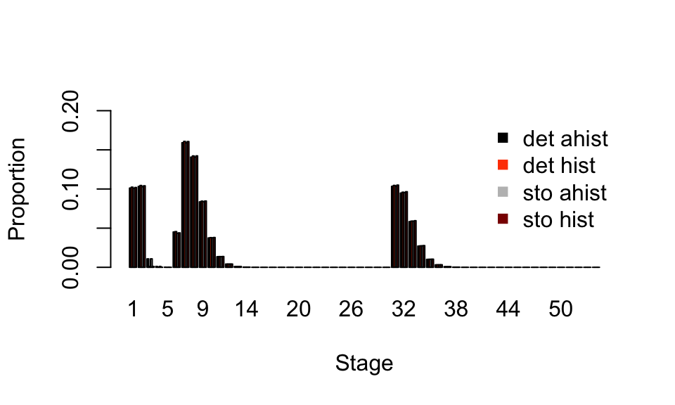

Figure 3L.10. Ahistorical vs. historically-corrected stable and long-run mean stage distribution, function-based MPMs

```r
tm2ss_f <- stablestage3(cyp2f_mean)
tm3ss_f <- stablestage3(cyp3f_mean)
tm2ss_fs <- stablestage3(cypmatrix2f, stochastic = TRUE, seed = 42)
tm3ss_fs <- stablestage3(cypmatrix3f, stochastic = TRUE, seed = 42)

ss_put_together <- cbind.data.frame(tm2ss_f$ss_prop, tm3ss_f$ahist$ss_prop,
  tm2ss_fs$ss_prop, tm3ss_fs$ahist$ss_prop)
names(ss_put_together) <- c("det ahist", "det hist", "sto ahist", "sto hist")
rownames(ss_put_together) <- tm2ss_f$stage_id

barplot(t(ss_put_together), beside=T, ylab = "Proportion", xlab = "Stage",
  ylim = c(0, 0.20), col = c("black", "orangered", "grey", "darkred"), bty = "n")
legend("topright", c("det ahist", "det hist", "sto ahist", "sto hist"),
  col = c("black", "orangered", "grey", "darkred"), pch = 15, bty = "n")
```

If we look over the stageframe used for these MPMs (see the `ahstages` element of any of the function-based MPMs), we can see that at equilibrium, the population should be composed of the same stages shown to dominate in the raw case - the smallest adults. The real differences seems to be that the function-based MPMs imply a greater proportion of the population should be composed of small non-reproductive adults, and dormant seeds and 1st year protocorms than the raw MPMs suggest.

Finally, let’s look over the predicted stable stage distribution if we use the wrong size and fecundity distributions.

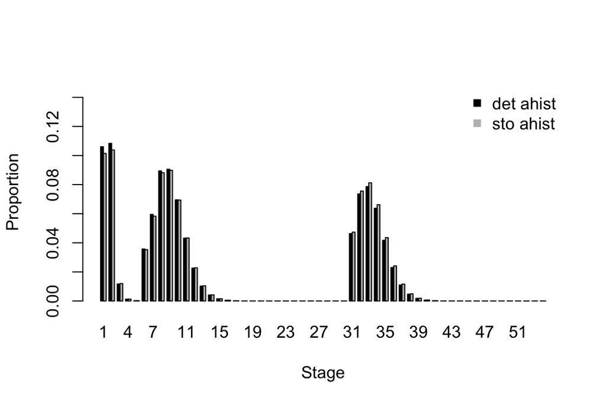

Figure 3L.11. Ahistorical stable and long-run mean stage distribution, function-based MPMs with wrong size and fecundity distributions

```r
tm2w_f <- stablestage3(lmean(cypmatrix2f_wrong))
tm2w_fs <- stablestage3(cypmatrix2f_wrong, stochastic = TRUE, seed = 42)

ss_put_together <- cbind.data.frame(tm2w_f$ss_prop, tm2w_fs$ss_prop)
names(ss_put_together) <- c("det ahist", "sto ahist")
rownames(ss_put_together) <- tm2w_f$stage_id

barplot(t(ss_put_together), beside=T, ylab = "Proportion", xlab = "Stage",
  ylim = c(0, 0.15), col = c("black", "grey"), bty = "n")
legend("topright", c("det ahist", "sto ahist"),
  col = c("black", "grey"), pch = 15, bty = "n")
```

A comparison with the previous graphs shows a prediction for stronger domination by juvenile stages, and with slightly larger adults of both reproductive and non-reproductive status predicted to be as dominant as dormant seeds and first-year protocorms.

Next let’s look at the reproductive values associated with both ahistorical and historical approaches, starting with raw MPMs. We will standardize against the maximum value in each case to make these comparable (note that this is NOT standard practice - we only do it here because of the strong difference in scale across the analyses).

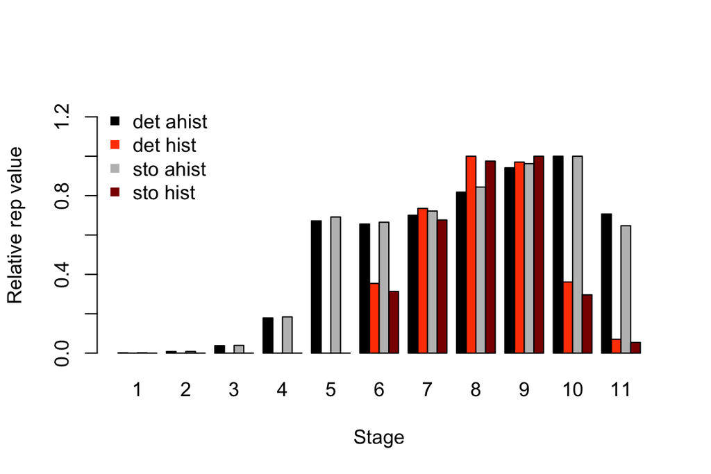

Figure 3L.12. Ahistorical vs. historically-corrected deterministic and stochastic reproductive values, raw MPMs

```r
tm2rv_r <- repvalue3(cyp2r_mean)
tm3rv_r <- repvalue3(cyp3r_mean)
tm2rv_rs <- repvalue3(cypmatrix2r, stochastic = TRUE, seed = 42)
tm3rv_rs <- repvalue3(cypmatrix3r, stochastic = TRUE, seed = 42)

rv_put_together <- cbind.data.frame((tm2rv_r$rep_value / max(tm2rv_r$rep_value)),
  (tm3rv_r$ahist$rep_value / max(tm3rv_r$ahist$rep_value)),
  (tm2rv_rs$rep_value / max(tm2rv_rs$rep_value)),
  (tm3rv_rs$ahist$rep_value / max(tm3rv_rs$ahist$rep_value)))
names(rv_put_together) <- c("det ahist", "det hist", "sto ahist", "sto hist")
rownames(rv_put_together) <- tm2rv_r$stage_id

barplot(t(rv_put_together), beside=T, ylab = "Relative rep value", xlab = "Stage",
  ylim = c(0, 1.3), col = c("black", "orangered", "grey", "darkred"), bty = "n")
legend("topleft", c("det ahist", "det hist", "sto ahist", "sto hist"),
  col = c("black", "orangered", "grey", "darkred"), pch = 15, bty = "n")
```

We see some big differences here, particularly between ahistorical and historical analyses. Indeed, in the ahistorical case, all adult stages and seedlings have roughly equivalent reproductive value. In contrast, in the historical case, the greatest reproductive values by far are associated with small and medium adults. So, history appears to have large effects here. Interesting results in need of further study!

Now let’s compare with the function-based case.

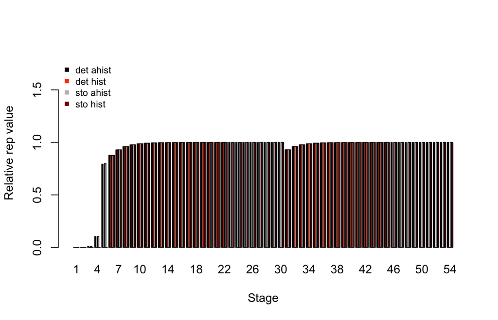

Figure 3L.13. Ahistorical vs. historically-corrected deterministic and stochastic reproductive values, function-based MPMs

```r
tm2rv_f <- repvalue3(cyp2f_mean)
tm3rv_f <- repvalue3(cyp3f_mean)
tm2rv_fs <- repvalue3(cypmatrix2f, stochastic = TRUE, seed = 42)
tm3rv_fs <- repvalue3(cypmatrix3f, stochastic = TRUE, seed = 42)

rv_put_together <- cbind.data.frame((tm2rv_f$rep_value / max(tm2rv_f$rep_value)),
  (tm3rv_f$ahist$rep_value / max(tm3rv_f$ahist$rep_value)),
  (tm2rv_fs$rep_value / max(tm2rv_fs$rep_value)),
  (tm3rv_fs$ahist$rep_value / max(tm3rv_fs$ahist$rep_value)))
names(rv_put_together) <- c("det ahist", "det hist", "sto ahist", "sto hist")
rownames(rv_put_together) <- tm2rv_f$stage_id

barplot(t(rv_put_together), beside=T, ylab = "Relative rep value", xlab = "Stage",
  ylim = c(0, 1.8), col = c("black", "orangered", "grey", "darkred"), bty = "n")
legend("topleft", c("det ahist", "det hist", "sto ahist", "sto hist"),
  col = c("black", "orangered", "grey", "darkred"), pch = 15, cex = 0.8, bty = "n")
```

Let’s now do a sensitivity analysis, again using both deterministic and stochastic approaches. First we will look at the raw ahistorical MPM.

```r
tm2sens_r <- sensitivity3(cyp2r_mean)
set.seed(42)
tm2sens_rs <- sensitivity3(cypmatrix2r, stochastic = TRUE)

writeLines("\nThe highest deterministic sensitivity value: ")
```

```
#>
#> The highest deterministic sensitivity value:
```

```r
max(tm2sens_r$ah_sensmats[[1]][which(cyp2r_mean$A[[1]] > 0)])
```

```
#> [1] 0.4689471
```

```r
writeLines("\nThis value is associated with element: ")
```

```
#>
#> This value is associated with element:
```

```r
intersect(which(tm2sens_r$ah_sensmats[[1]] == max(tm2sens_r$ah_sensmats[[1]][which(cyp2r_mean$A[[1]] > 0)])), which(cyp2r_mean$A[[1]] > 0))
```

```
#> [1] 87
```

```r
writeLines("\nThe highest stochastic sensitivity value: ")
```

```
#>
#> The highest stochastic sensitivity value:
```

```r
max(tm2sens_rs$ah_sensmats[[1]][which(cyp2r_mean$A[[1]] > 0)])
```

```
#> [1] 0.4909867
```

```r
writeLines("\nThis value is associated with element: ")
```

```
#>
#> This value is associated with element:
```

```r
intersect(which(tm2sens_rs$ah_sensmats[[1]] == max(tm2sens_rs$ah_sensmats[[1]][which(cyp2r_mean$A[[1]] > 0)])), which(cyp2r_mean$A[[1]] > 0))
```

```
#> [1] 87
```

The highest sensitivity value appears to be associated with element 87 in both deterministic and stochastic cases. Since there are 11 stages in the stageframe, this means that $\lambda$ and $log \lambda$ are most sensitive to the transition associated from the 8th stage (Small adult) to the 10th stage (Large adult). Let’s compare this to the historical case.

```r
tm3sens_r <- sensitivity3(cyp3r_mean)
set.seed(42)
tm3sens_rs <- sensitivity3(cypmatrix3r, stochastic = TRUE)

writeLines("\nThe highest deterministic sensitivity value: ")
```

```
#>
#> The highest deterministic sensitivity value:
```

```r
max(tm3sens_r$h_sensmats[[1]][which(cyp3r_mean$A[[1]] > 0)])
```

```
#> [1] 0.3033102
```

```r
writeLines("\nThis value is associated with element: ")
```

```
#>
#> This value is associated with element:
```

```r
intersect(which(tm3sens_r$h_sensmats[[1]] == max(tm3sens_r$h_sensmats[[1]][which(cyp3r_mean$A[[1]] > 0)])), which(cyp3r_mean$A[[1]] > 0))
```

```
#> [1] 10249
```

```r
writeLines("\nThe highest stochastic sensitivity value: ")
```

```
#>
#> The highest stochastic sensitivity value:
```

```r
max(tm3sens_rs$h_sensmats[[1]][which(cyp3r_mean$A[[1]] > 0)])
```

```
#> [1] 0.3408622
```

```r
writeLines("\nThis value is associated with element: ")
```

```
#>
#> This value is associated with element:
```

```r
intersect(which(tm3sens_rs$h_sensmats[[1]] == max(tm3sens_rs$h_sensmats[[1]][which(cyp3r_mean$A[[1]] > 0)])), which(cyp3r_mean$A[[1]] > 0))
```

```
#> [1] 10249
```

Here we find that $\lambda$ and $log \lambda$ are both most sensitive to element 10249. Looking over the `hstages` portion, this corresponds to the the transition from the 85th stage pair (Small adult in times *t*-1 and *t*), to the 85th stage pair (Small adult in times *t* and *t*+1). So, once again, stasis as a Small adult.

Here is some simple code to help determine the exact stages for a specific element.

```r
# For element 87 in the ahistorical case
writeLines(paste0("Element 87 in cyp2r_mean is associated with row ",
  ceiling(87 / dim(cyp2r_mean$ahstages)[1]), " and column ",
  (87 %% dim(cyp2r_mean$ahstages)[1])))
```

```
#> Element 87 in cyp2r_mean is associated with row 8 and column 10
```

```r
# For element 10249 in the historical case
writeLines(paste0("Element 87 in cyp3r_mean is associated with row ",
  ceiling(10249 / dim(cyp3r_mean$hstages)[1]), " and column ",
  (10249 %% dim(cyp3r_mean$hstages)[1])))
```

```
#> Element 87 in cyp3r_mean is associated with row 85 and column 85
```

Let’s now compare to the function-based case. We will run both ahistorical and historical portions at the same time.

```r
tm2sens_f <- sensitivity3(cyp2f_mean)
set.seed(42)
tm2sens_fs <- sensitivity3(cypmatrix2f, stochastic = TRUE)

tm3sens_f <- sensitivity3(cyp3f_mean)
set.seed(42)
tm3sens_fs <- sensitivity3(cypmatrix3f, stochastic = TRUE, steps = 500)

writeLines("\nThe highest deterministic ahistorical sensitivity value: ")
```

```
#>
#> The highest deterministic ahistorical sensitivity value:
```

```r
max(tm2sens_f$ah_sensmats[[1]][which(cyp2f_mean$A[[1]] > 0)])
```

```
#> [1] 0.2132667
```

```r
writeLines("\nThis value is associated with element: ")
```

```
#>
#> This value is associated with element:
```

```r
intersect(which(tm2sens_f$ah_sensmats[[1]] == max(tm2sens_f$ah_sensmats[[1]][which(cyp2f_mean$A[[1]] > 0)])), which(cyp2f_mean$A[[1]] > 0))
```

```
#> [1] 378
```

```r
writeLines("\nThe highest stochastic ahistorical sensitivity value: ")
```

```
#>
#> The highest stochastic ahistorical sensitivity value:
```

```r
max(tm2sens_fs$ah_sensmats[[1]][which(cyp2f_mean$A[[1]] > 0)])
```

```
#> [1] 0.2213405
```

```r
writeLines("\nThis value is associated with element: ")
```

```
#>
#> This value is associated with element:
```

```r
intersect(which(tm2sens_fs$ah_sensmats[[1]] == max(tm2sens_fs$ah_sensmats[[1]][which(cyp2f_mean$A[[1]] > 0)])), which(cyp2f_mean$A[[1]] > 0))
```

```
#> [1] 378
```

```r
writeLines("\nThe highest deterministic historical sensitivity value: ")
```

```
#>
#> The highest deterministic historical sensitivity value:
```

```r
max(tm3sens_f$h_sensmats[[1]][which(cyp3f_mean$A[[1]] > 0)])
```

```
#> [1] 0.05332836
```

```r
writeLines("\nThis value is associated with element: ")
```

```
#>
#> This value is associated with element:
```

```r
intersect(which(tm3sens_f$h_sensmats[[1]] == max(tm3sens_f$h_sensmats[[1]][which(cyp3f_mean$A[[1]] > 0)])), which(cyp3f_mean$A[[1]] > 0))
```

```
#> [1] 962634 962658
```

```r
writeLines("\nThe highest stochastic historical sensitivity value: ")
```

```
#>
#> The highest stochastic historical sensitivity value:
```

```r
max(tm3sens_fs$h_sensmats[[1]][which(cyp3f_mean$A[[1]] > 0)])
```

```
#> [1] 0.05479311
```

```r
writeLines("\nThis value is associated with element: ")
```

```
#>
#> This value is associated with element:
```

```r
intersect(which(tm3sens_fs$h_sensmats[[1]] == max(tm3sens_fs$h_sensmats[[1]][which(cyp3f_mean$A[[1]] > 0)])), which(cyp3f_mean$A[[1]] > 0))
```

```
#> [1] 962658
```

The highest sensitivity value in both deterministic and stochastic ahistorical cases appears to be associated with the transition from 1-sprouted non-flowering adult to the largest flowering adult (element 378, which is in the 7th column and 54th row). Inspecting each sensitivity matrix also shows that transitions near that element in both matrices are also associated with rather high sensitivities. Both deterministic and stochastic historical analyses suggest the strongest sensitivity in response to several elements 962634 and 962658. Element 962634 is the transition from 1-sprouted vegetative adult in times *t*-1 and *t* to 24-sprouted vegetative adult in tie *t*+1, while element 962658 is the transition from 1-sprouted vegetative adult in times *t*-1 and *t* to 24-sprouted flowering adult in time *t*+1. So, transitions from tiny adults to very large adults seem to exert strong potential influences on the population growth rate.

Let’s now assess the elasticity of $\lambda$ to matrix elements, comparing the ahistorical to the historically-corrected case in both deterministic and stochastic analyses.

```r
tm2elas_r <- elasticity3(cyp2r_mean)
tm3elas_r <- elasticity3(cyp3r_mean)

set.seed(42)
tm2elas_rs <- elasticity3(cypmatrix2r, stochastic = TRUE)
set.seed(42)
tm3elas_rs <- elasticity3(cypmatrix3r, stochastic = TRUE)

writeLines("\nThe largest ahistorical deterministic elasticity is associated with element: ")
```

```
#>
#> The largest ahistorical deterministic elasticity is associated with element:
```

```r
which(tm2elas_r$ah_elasmats[[1]] == max(tm2elas_r$ah_elasmats[[1]]))
```

```
#> [1] 85
```

```r
writeLines("\nThe largest historically-corrected deterministic elasticity is associated with element: ")
```

```
#>
#> The largest historically-corrected deterministic elasticity is associated with element:
```

```r
which(tm3elas_r$ah_elasmats[[1]] == max(tm3elas_r$ah_elasmats[[1]]))
```

```
#> [1] 85
```

```r
writeLines("\nThe largest historical deterministic elasticity is associated with element: ")
```

```
#>
#> The largest historical deterministic elasticity is associated with element:
```

```r
which(tm3elas_r$h_elasmats[[1]] == max(tm3elas_r$h_elasmats[[1]]))
```

```
#> [1] 10249
```

```r
writeLines("\nThe largest ahistorical stochastic elasticity is associated with element: ")
```

```
#>
#> The largest ahistorical stochastic elasticity is associated with element:
```

```r
which(tm2elas_rs$ah_elasmats[[1]] == max(tm2elas_rs$ah_elasmats[[1]]))
```

```
#> [1] 85
```

```r
writeLines("\nThe largest historically-corrected stochastic elasticity is associated with element: ")
```

```
#>
#> The largest historically-corrected stochastic elasticity is associated with element:
```

```r
which(tm3elas_rs$ah_elasmats[[1]] == max(tm3elas_rs$ah_elasmats[[1]]))
```

```
#> [1] 85
```

```r
writeLines("\nThe largest historical stochastic elasticity is associated with element: ")
```

```
#>
#> The largest historical stochastic elasticity is associated with element:
```

```r
which(tm3elas_rs$h_elasmats[[1]] == max(tm3elas_rs$h_elasmats[[1]]))
```

```
#> [1] 10249
```

Let’s now look at the function-based case.

```r
tm2elas_f <- elasticity3(cyp2f_mean)
tm3elas_f <- elasticity3(cyp3f_mean)

set.seed(42)
tm2elas_fs <- elasticity3(cypmatrix2f, stochastic = TRUE)
set.seed(42)
tm3elas_fs <- elasticity3(cypmatrix3f, stochastic = TRUE, steps = 500)

writeLines("\nThe largest ahistorical deterministic elasticity is associated with element: ")
```

```
#>
#> The largest ahistorical deterministic elasticity is associated with element:
```

```r
which(tm2elas_f$ah_elasmats[[1]] == max(tm2elas_f$ah_elasmats[[1]]))
```

```
#> [1] 331
```

```r
writeLines("\nThe largest historically-corrected deterministic elasticity is associated with element: ")
```

```
#>
#> The largest historically-corrected deterministic elasticity is associated with element:
```

```r
which(tm3elas_f$ah_elasmats[[1]] == max(tm3elas_f$ah_elasmats[[1]]))
```

```
#> [1] 331
```

```r
writeLines("\nThe largest historical deterministic elasticity is associated with element: ")
```

```
#>
#> The largest historical deterministic elasticity is associated with element:
```

```r
which(tm3elas_f$h_elasmats[[1]] == max(tm3elas_f$h_elasmats[[1]]))
```

```
#> [1] 962611
```

```r
writeLines("\nThe largest ahistorical stochastic elasticity is associated with element: ")
```

```
#>
#> The largest ahistorical stochastic elasticity is associated with element:
```

```r
which(tm2elas_fs$ah_elasmats[[1]] == max(tm2elas_fs$ah_elasmats[[1]]))
```

```
#> [1] 331
```

```r
writeLines("\nThe largest historically-corrected stochastic elasticity is associated with element: ")
```

```
#>
#> The largest historically-corrected stochastic elasticity is associated with element:
```

```r
which(tm3elas_fs$ah_elasmats[[1]] == max(tm3elas_fs$ah_elasmats[[1]]))
```

```
#> [1] 331
```

```r
writeLines("\nThe largest historical stochastic elasticity is associated with element: ")
```

```
#>
#> The largest historical stochastic elasticity is associated with element:
```

```r
which(tm3elas_fs$h_elasmats[[1]] == max(tm3elas_fs$h_elasmats[[1]]))
```

```
#> [1] 962611
```

Here we see a different set of elements to which population growth rate is most elastic to than predicted by sensitivity analysis. However, the transitions themselves are close to those suggested in the latter, suggesting that these results are still in line. Element 331 corresponds to the ahistorical stasis transition in one-sprouted vegetative, and element 962611 corresponds to the historical stasis transition in this stage. This is a remarkably consistent result, reinforcing the importance of this stage as seen in sensitivity analyses.

Now let’s compare the elasticity of population growth rate in relation to the core life history stages, via a barplot comparison.

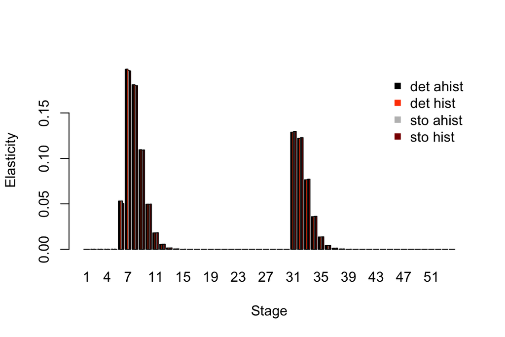

Figure 3L.14. Ahistorical vs. historically-corrected deterministic and stochastic elasticity to stage, function-based

```r
elas_put_together <- cbind.data.frame(colSums(tm2elas_f$ah_elasmats[[1]]),
  colSums(tm3elas_f$ah_elasmats[[1]]), colSums(tm2elas_fs$ah_elasmats[[1]]),
  colSums(tm3elas_fs$ah_elasmats[[1]]))
names(elas_put_together) <- c("det ahist", "det hist", "sto ahist", "sto hist")
rownames(elas_put_together) <- tm2elas_f$ah_stages$stage_id

barplot(t(elas_put_together), beside=T, ylab = "Elasticity", xlab = "Stage",
  col = c("black", "orangered", "grey", "darkred"), bty = "n")
legend("topright", c("det ahist", "det hist", "sto ahist", "sto hist"),
  col = c("black", "orangered", "grey", "darkred"), pch = 15, bty = "n")
```

Elasticity analyses in these plots look fairly similar, with most of the differences appearing to lie in elasticity of small non-flowering vs. flowering adults in the ahistorical vs. historical comparison.

Finally, let’s take a look at how the importance of different kinds of transitions changes, by looking at elasticity sums.

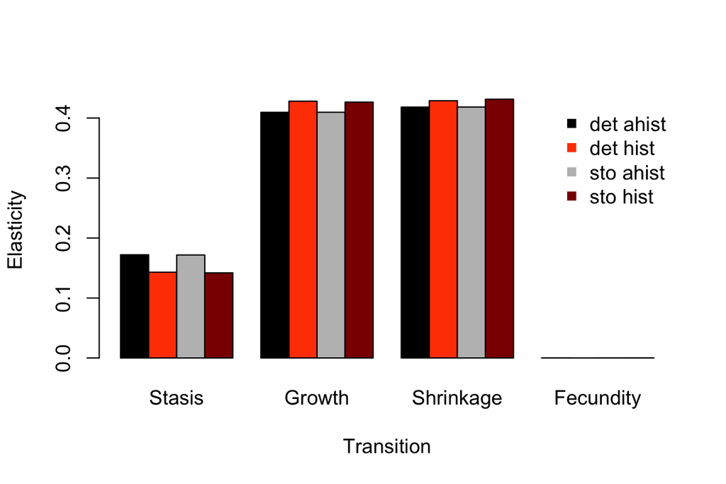

Figure 3L.15. Ahistorical vs. historically-corrected elasticity of lambda to transitions, function-based

```r
tm2elas_f_sums <- summary(tm2elas_f)
tm3elas_f_sums <- summary(tm3elas_f)
tm2elas_fs_sums <- summary(tm2elas_fs)
tm3elas_fs_sums <- summary(tm3elas_fs)

elas_sums_together <- cbind.data.frame(tm2elas_f_sums$ahist[,2],
  tm3elas_f_sums$ahist[,2], tm2elas_fs_sums$ahist[,2], tm3elas_fs_sums$ahist[,2])
names(elas_sums_together) <- c("det ahist", "det hist", "sto ahist", "sto hist")
rownames(elas_sums_together) <- tm2elas_f_sums$ahist$category

barplot(t(elas_sums_together), beside=T, ylab = "Elasticity", xlab = "Transition",
  col = c("black", "orangered", "grey", "darkred"), bty = "n")
legend("topright", c("det ahist", "det hist", "sto ahist", "sto hist"),
  col = c("black", "orangered", "grey", "darkred"), pch = 15, bty = "n")
```

Fecundity makes little difference in all cases, but the importance of stasis transitions drops a bit in historical analysis, while growth transitions increase a bit in importance. Next, we can see which historical transitions are most important.

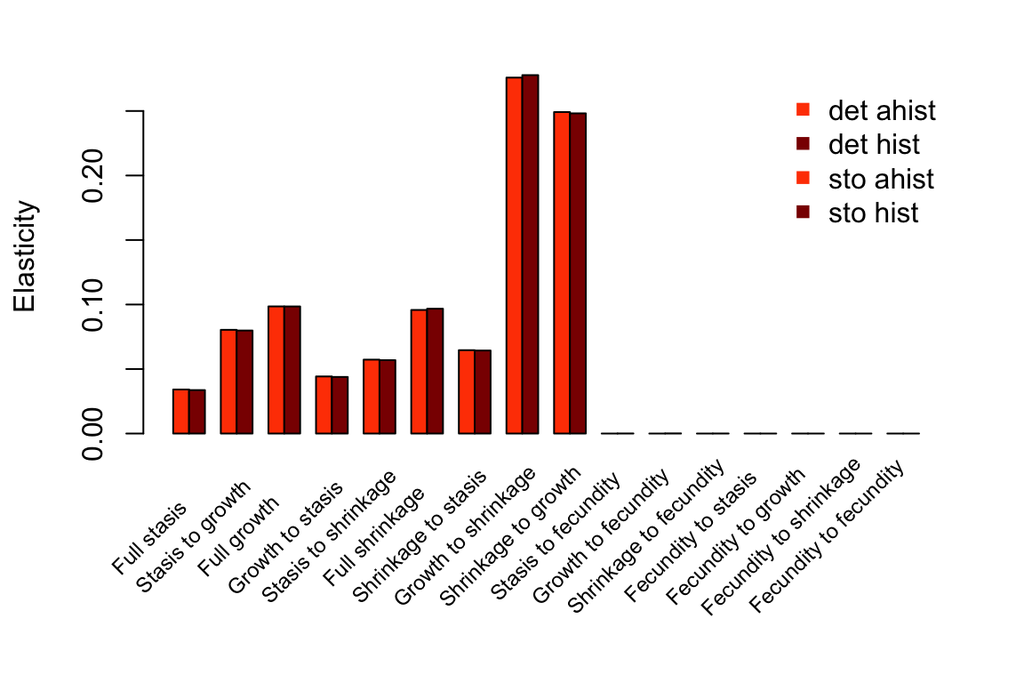

Figure 3L.16. Elasticity of lambda to historical transitions, function-based

```r
elas_hist2plot <- cbind.data.frame(tm3elas_f_sums$hist[,2],
  tm3elas_fs_sums$hist[,2])
names(elas_hist2plot) <- c("det hist", "sto hist")
rownames(elas_hist2plot) <- tm3elas_f_sums$hist$category

par(mar = c(7, 4, 2, 2) + 0.2)
barplot(t(elas_hist2plot), beside = T, ylab = "Elasticity", xlab = "", xaxt = "n",
  col = c("orangered", "darkred"), bty = "n")
text(cex=0.75, x=seq(from = -0.5, to = 2.8*length(tm3elas_f_sums$hist$category), by = 2.85),
  y=-0.08, tm3elas_f_sums$hist$category, xpd=TRUE, srt=45)
legend("topright", c("det ahist", "det hist", "sto ahist", "sto hist"),
  col = c("orangered", "darkred"), pch = 15, bty = "n")
```

We can see that growth from occasion *t*-1 to *t* followed by shrinkage to occasion *t*+1 is associated with the greatest summed elasticities, while the inverse, shrinkage from occasion *t*-1 to *t* followed by growth to occasion *t*+1 is the next most important. Transitions associated with fecundity are associated with the lowest summed elasticities.

#### Advanced and upcoming analysis

The most recent versions of lefko3 incorporate a basic projection function, projection3(). Originally, this function was developed to create simple deterministic and stochastic projections of varying lengths and complexity, with output including growth rate, stage structure, and reproductive value per time step, with a number of options designed to streamline analysis. We are adding further power to this function with each new version of lefko3(), and beginning with the development version 3.7.0.9000, we have included replication.

We will demonstrate by using this function to conduct a quasi-extinction analysis. Let’s use the function-based ahistorical MPM to illustrate this, using this function to create 100 stochastic replicates of a population projection.

```r
set.seed(42)
cypproj_2f <- projection3(cypmatrix2f, nreps = 100, stochastic = TRUE, integeronly = TRUE)
```

Now let’s take a look at the resulting object, which is a list of class `lefkoProj`. We will not output the whole object because it is quite long. Instead, let’s first look at the elements that constitute it.

```r
names(cypproj_2f)
```

```
#> [1] "projection" "labels"     "ahstages"   "hstages"    "agestages"
#> [6] "control"
```

We see 6 elements, with 4 seemingly familiar - `ahstages` is the stage frame from the input MPM, `hstages` is a data frame showing the order of historical stage pairs (only provided if an hMPM is used as input), and `agestages` is a data frame showing the order of age-stages (only provided if an age-by-stage MPM is used as input). The element named `control` is a short vector giving the number of replicates followed by the number of time steps projected. And the most important element is `projection`, which is a matrix showing the stage structure in each of the 100 replicates that we created. The dimensions of this matrix will make the matter clearer:

```r
dim(cypproj_2f$projection[[1]])
```

```
#> [1]  5400 10001
```

We see that there are 5400 rows and 10001 columns. The columns correspond to the discrete times that we have projected. The rows correspond to the 54 stages in each of the 100 replicates, with each replicate together. Thus, the first 54 rows correspond to the numbers of individuals in each stage at each time in replicate 1. Rows 55-108 correspond to the numbers of individuals in each stage at each time in replicate 2. Lets’s take a look at the first few time steps of replicate 1.

```r
cypproj_2f$projection[[1]][1:54,1:10]
```

```
#>       [,1] [,2] [,3] [,4] [,5] [,6] [,7] [,8] [,9] [,10]
#>  [1,]    1    1   10    8    3    3    1    0    0     0
#>  [2,]    1    1   10    9    3    3    2    0    0     0
#>  [3,]    1    0    0    1    0    0    0    0    0     0
#>  [4,]    1    0    0    0    0    0    0    0    0     0
#>  [5,]    1    0    0    0    0    0    0    0    0     0
#>  [6,]    1    0    0    1    0    2    0    1    0     0
#>  [7,]    1    2    2    7    3    3    3    1    0     0
#>  [8,]    1    2    2    5    3    2    2    1    0     0
#>  [9,]    1    1    1    3    2    1    1    0    0     0
#> [10,]    1    0    0    1    1    0    0    0    0     0
#> [11,]    1    0    0    0    0    0    0    0    0     0
#> [12,]    1    0    0    0    0    0    0    0    0     0
#> [13,]    1    0    0    0    0    0    0    0    0     0
#> [14,]    1    0    0    0    0    0    0    0    0     0
```

[output cut: 40 more lines]

You may notice that the population seems to be declining here. This is not a shock - all of our MPMs suggest a declining population. Let’s use the summary.lefkoProj() function to get a better handle on this.

```r
summary(cypproj_2f)
```

```
#>
#> The input lefkoProj object covers 1 population-patches.
#> It includes 10000 projected steps per replicate and 100 replicates.
#> The number of replicates with population size above the threshold size of 1 is as in the following matrix, with pop-patches given by column and milepost times given by row:
#>
#>       1 1
#> 1     100
#> 2501    0
#> 5001    0
#> 7501    0
#> 10001   0
#> NULL
```

This summary gives us some basic information about our projection, and also shows us the number of replicates with more than 1 individual projected alive at a series of projected times (times 1, 2501, 5001, 7501, and 10001). We can change these milepost times, using either proportions or explicit times.

```r
summary(cypproj_2f, milepost = c(1, 3, 5, 8, 9, 10, 100, 10001))
```

```
#>
#> The input lefkoProj object covers 1 population-patches.
#> It includes 10000 projected steps per replicate and 100 replicates.
#> The number of replicates with population size above the threshold size of 1 is as in the following matrix, with pop-patches given by column and milepost times given by row:
#>
#>       1 1
#> 1     100
#> 3     100
#> 5     100
#> 8      98
#> 9      26
#> 10      0
#> 100     0
#> 10001   0
#> NULL
```

The output above gives us a sense that the population is generally declining. The summary function can also be used to output population sizes projected under each replicate, so that we can plot the results. We can use the `sums_out` option for this purpose. Here is an example.

```r
proj_sums <- summary(cypproj_2f, sums_out = TRUE)
```

```
#>
#> The input lefkoProj object covers 1 population-patches.
#> It includes 10000 projected steps per replicate and 100 replicates.
#> The number of replicates with population size above the threshold size of 1 is as in the following matrix, with pop-patches given by column and milepost times given by row:
#>
#>       1 1
#> 1     100
#> 2501    0
#> 5001    0
#> 7501    0
#> 10001   0
```

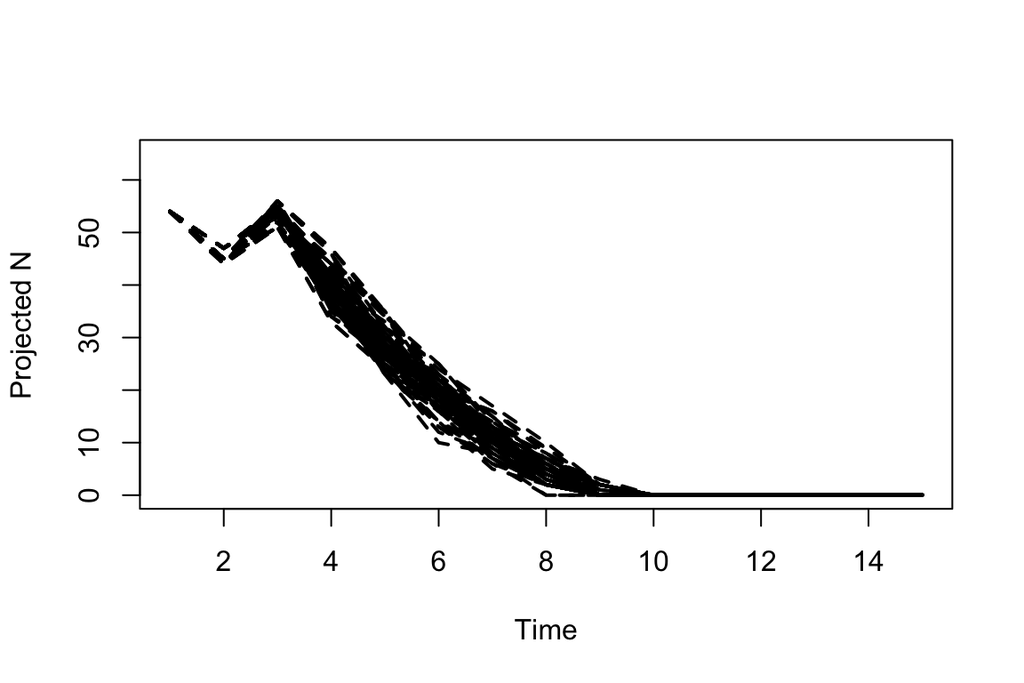

Figure 3L.17. Projected population size across time over 100 replicates and 10,000 time steps for the ahistorical function-based MPM

```r
plot(proj_sums$mat_sums[[1]][1,c(1:15)], ylim = c(0, 65), type = "l", lwd = 2,
  lty = 2, xlab = "Time", ylab = "Projected N")
apply(as.matrix(c(2:100)), 1, function(X) {
  lines(proj_sums$mat_sums[[1]][X,c(1:15)], lwd = 2, lty = 2)
})
```

In the above plot, we show the results of each population projection for the first 15 projected times. All 100 replicates go to extinction, of course. If our MPM had higher population growth rates, then we might have had only some go to extinction. In that case, we could see the number of replicates with surviving individuals at particular points in time, and estimate the time to extinction. For example, if 95% of replicates have died out by 100 times, then this analysis would suggest extinction within a hundred times. Quasi-extinction analysis would use this number against another series of replicates set up under a different set of assumptions to assess extinction. For example, we could run another analysis of data from the same population but a different patch that has been subjected to a different management regime, and compare the time to extinction in each. If the management regime is associated with increased population lifespan, then the probability of extinction is considered lower under the management scenario.

As a comparison point, let’s also look at a projection of the historical MPM and compare it. We will not project out 10,000 time steps, but only 200, to limit the amount of time needed for analysis. Then, we will plot our results as before.

```r
set.seed(42)
cypproj_3f <- projection3(cypmatrix3f, nreps = 100, times = 200,
  stochastic = TRUE, integeronly = TRUE)

proj_sums3 <- summary(cypproj_3f, sums_out = TRUE)
```

```
#>
#> The input lefkoProj object covers 1 population-patches.
#> It includes 200 projected steps per replicate and 100 replicates.
#> The number of replicates with population size above the threshold size of 1 is as in the following matrix, with pop-patches given by column and milepost times given by row:
#>
#>     1 1
#> 1   100
#> 51    0
#> 101   0
#> 151   0
#> 201   0
```

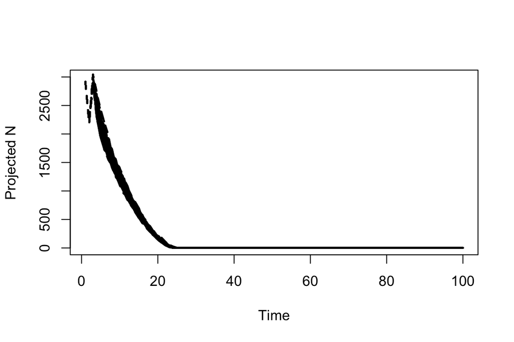

```r
plot(proj_sums3$mat_sums[[1]][1,c(1:100)], ylim = c(0, 3000), type = "l", lwd = 2,
  lty = 2, xlab = "Time", ylab = "Projected N")
apply(as.matrix(c(2:100)), 1, function(X) {
  lines(proj_sums3$mat_sums[[1]][X,c(1:100)], lwd = 2, lty = 2)
})
```

The historical analysis also suggests inevitable extinction, and quite quickly. In this case, we start with a higher number of individuals because the population projections start either with 1 individual per stage (in ahistorical analysis), or 1 individual per stage-pair (in historical analysis). So, we started with about 3,000 individuals here but only 50 or so in the ahistorical case. Nonetheless, extinction is quite quick, and leaves us to wonder how to boost the growth rate.

As a final analysis, we might try a comparison of our population under the current conditions against a scenario where we somehow boost fecundity by 50%. To do this analysis, we need to create a new set of MPMs under this new assumption. First, we will set up a new supplement table using this assumption, using the hMPM approach. Then we will take a look at it relative to the original supplement table.

```r
cypsupp3_fb_50 <- supplemental(stage3 = c("SD", "SD", "P1", "P1", "P2", "P3", "SL",
    "SL", "SL", "D", "V1", "V2", "V3", "D", "V1", "V2", "V3", "SD", "P1"),
  stage2 = c("SD", "SD", "SD", "SD", "P1", "P2", "P3", "SL", "SL", "SL", "SL",
    "SL", "SL", "SL", "SL", "SL", "SL", "rep", "rep"),
  stage1 = c("SD", "rep", "SD", "rep", "SD", "P1", "P2", "P3", "SL", "P3", "P3",
    "P3", "P3", "SL", "SL", "SL", "SL", "mat", "mat"),
  eststage3 = c(NA, NA, NA, NA, NA, NA, NA, NA, NA, "D", "V1", "V2", "V3", "D",
    "V1", "V2", "V3", NA, NA),
  eststage2 = c(NA, NA, NA, NA, NA, NA, NA, NA, NA, "D", "D", "D", "D", "D",
    "D", "D", "D", NA, NA),
  eststage1 = c(NA, NA, NA, NA, NA, NA, NA, NA, NA, "D", "D", "D", "D", "D",
    "D", "D", "D", NA, NA),
  givenrate = c(0.08, 0.08, 0.1, 0.1, 0.1, 0.1, 0.125, 0.2, 0.2, NA, NA, NA, NA,
    NA, NA, NA, NA, NA, NA),
  multiplier = c(NA, NA, NA, NA, NA, NA, NA, NA, NA, NA, NA, NA, NA, NA, NA, NA,
    NA, 0.75, 0.75),
  type = c("S", "S", "S", "S", "S", "S", "S", "S", "S", "S", "S", "S", "S", "S",
    "S", "S", "S", "R", "R"),
  type_t12 = c("S", "F", "S", "F", "S", "S", "S", "S", "S", "S", "S", "S", "S",
    "S", "S", "S", "S", "S", "S"), stageframe = cypframe_fb)

cypsupp3_fb_50
```

```
#>    stage3 stage2 stage1 eststage3 eststage2 eststage1 givenrate multiplier
#> 1      SD     SD     SD      <NA>      <NA>      <NA>     0.080         NA
#> 2      SD     SD    rep      <NA>      <NA>      <NA>     0.080         NA
#> 3      P1     SD     SD      <NA>      <NA>      <NA>     0.100         NA
#> 4      P1     SD    rep      <NA>      <NA>      <NA>     0.100         NA
#> 5      P2     P1     SD      <NA>      <NA>      <NA>     0.100         NA
#> 6      P3     P2     P1      <NA>      <NA>      <NA>     0.100         NA
#> 7      SL     P3     P2      <NA>      <NA>      <NA>     0.125         NA
#> 8      SL     SL     P3      <NA>      <NA>      <NA>     0.200         NA
#> 9      SL     SL     SL      <NA>      <NA>      <NA>     0.200         NA
#> 10      D     SL     P3         D         D         D        NA         NA
#> 11     V1     SL     P3        V1         D         D        NA         NA
#> 12     V2     SL     P3        V2         D         D        NA         NA
#> 13     V3     SL     P3        V3         D         D        NA         NA
#> 14      D     SL     SL         D         D         D        NA         NA
```

[output cut: 25 more lines]

```r
cypsupp3_fb
```

```
#>    stage3 stage2 stage1 eststage3 eststage2 eststage1 givenrate multiplier
#> 1      SD     SD     SD      <NA>      <NA>      <NA>     0.080         NA
#> 2      SD     SD    rep      <NA>      <NA>      <NA>     0.080         NA
#> 3      P1     SD     SD      <NA>      <NA>      <NA>     0.100         NA
#> 4      P1     SD    rep      <NA>      <NA>      <NA>     0.100         NA
#> 5      P2     P1     SD      <NA>      <NA>      <NA>     0.100         NA
#> 6      P3     P2     P1      <NA>      <NA>      <NA>     0.100         NA
#> 7      SL     P3     P2      <NA>      <NA>      <NA>     0.125         NA
#> 8      SL     SL     P3      <NA>      <NA>      <NA>     0.200         NA
#> 9      SL     SL     SL      <NA>      <NA>      <NA>     0.200         NA
#> 10      D     SL     P3         D         D         D        NA         NA
#> 11     V1     SL     P3        V1         D         D        NA         NA
#> 12     V2     SL     P3        V2         D         D        NA         NA
#> 13     V3     SL     P3        V3         D         D        NA         NA
#> 14      D     SL     SL         D         D         D        NA         NA
```

[output cut: 25 more lines]

The primary difference here is in the last two lines. In the original supplement table, we split fecunsdity evenly between dormant seeds and first-year protocorms. Now, we boost each of these fecundity estimators by 50%, up to 0.75 each.

Now let’s create the new hMPMs.

```r
cypmatrix3f_50 <- flefko3(stageframe = cypframe_fb, supplement = cypsupp3_fb_50,
  modelsuite = cypmodels3, data = cypfb_v1, yearcol = "year2",
  year.as.random = TRUE)

summary(cypmatrix3f_50)
```

```
#>
#> This historical lefkoMat object contains 5 matrices.
#>
#> Each matrix is a square matrix with 2916 rows and columns, and a total of 8503056 elements.
#> A total of 588560 survival transitions were estimated, with 117712 per matrix.
#> A total of 11760 fecundity transitions were estimated, with 2352 per matrix.
#>
#> Vital rate modeling quality control:
#>
#> Survival estimated with 74 individuals and 320 individual transitions.
#> Observation estimated with 70 individuals and 303 individual transitions.
#> Size estimated with 70 individuals and 288 individual transitions.
#> Reproductive status estimated with 70 individuals and 288 individual transitions.
#> Fecundity estimated with 51 individuals and 118 individual transitions.
#> Juvenile survival not estimated.
#> Juvenile observation probability not estimated.
#> Juvenile size transition not estimated.
#> Juvenile reproduction probability not estimated.
#>
#> Survival probability sum check (each matrix represented by column in order):
#>          [,1]  [,2]  [,3]  [,4]  [,5]
#> Min.    0.000 0.000 0.000 0.000 0.000
#> 1st Qu. 0.965 0.965 0.965 0.965 0.965
#> Median  1.000 1.000 1.000 1.000 1.000
#> Mean    0.819 0.819 0.819 0.819 0.819
#> 3rd Qu. 1.000 1.000 1.000 1.000 1.000
#> Max.    1.000 1.000 1.000 1.000 1.000
#> NULL
```

Let’s take a quick look at our $\lambda$ estimates to see if the population growth rare has increased.

```r
lambda3(cypmatrix3f_50)
```

```
#>   pop patch year2    lambda
#> 1   1     1  2004 0.9607525
#> 2   1     1  2005 0.9541455
#> 3   1     1  2006 0.9553577
#> 4   1     1  2007 0.9498631
#> 5   1     1  2008 0.9616651
```

Although we do see a likely increase, it does not appear to avoid extincton. In any case, let’s conduct our new projections, and then plot them against the original hMPM projections.

```r
set.seed(42)
cypproj_3f_50 <- projection3(cypmatrix3f_50, nreps = 100, times = 200,
  stochastic = TRUE, integeronly = TRUE)

proj_sums3_50 <- summary(cypproj_3f_50, sums_out = TRUE)
```

```
#>
#> The input lefkoProj object covers 1 population-patches.
#> It includes 200 projected steps per replicate and 100 replicates.
#> The number of replicates with population size above the threshold size of 1 is as in the following matrix, with pop-patches given by column and milepost times given by row:
#>
#>     1 1
#> 1   100
#> 51    0
#> 101   0
#> 151   0
#> 201   0
```

```r
plot(proj_sums3$mat_sums[[1]][1,c(1:100)], ylim = c(0, 3500), type = "l", lwd = 2,
  lty = 2, xlab = "Time", ylab = "Projected N")
apply(as.matrix(c(2:100)), 1, function(X) {
  lines(proj_sums3$mat_sums[[1]][X,c(1:100)], lwd = 2, lty = 2)
})
```

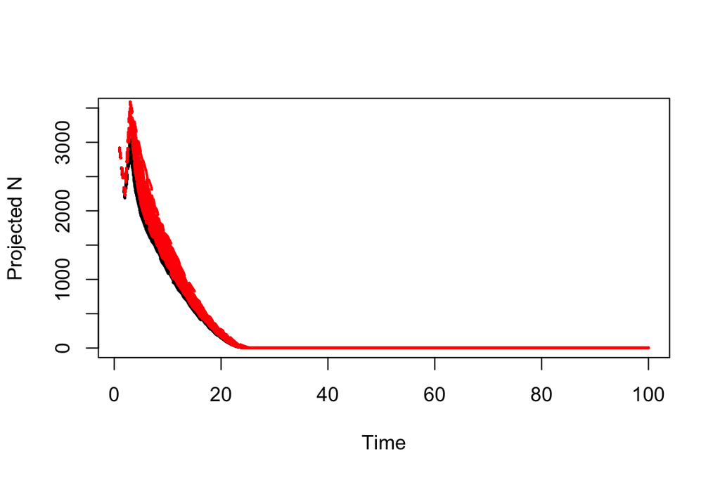

Figure 3L.19. Projected population comparison of hMPMs with original fecundity vs 50% fecundity boost

```r
apply(as.matrix(c(1:100)), 1, function(X) {
  lines(proj_sums3_50$mat_sums[[1]][X,c(1:100)], lwd = 2, lty = 2, col = "red")
})
```

We do see a small improvement in the lifespan of the population with boosted fecundity (shown in red). However, the improvement is quite small - extinction still seems nearly certain. Perhaps some of our previous results can address the question of how to save this population, or a life table response experiment (LTRE) comparing management strategies might also work. We do not include LTRE and sLTRE analysis within this vignette, but offer another vignette packaged within the official CRAN-available version of lefko3 for that purpose.

## Acknowledgements

We are grateful to two anonymous reviewers whose scrutiny improved the quality of this vignette. The project resulting in this package and this tutorial was funded by Grant-In-Aid 19H03298 from the Japan Society for the Promotion of Science.

## Literature cited

Bartoń, Kamil A. 2014. “MuMIn: Multi-Model Inference.” https://CRAN.R-project.org/package=MuMIn.

Burnham, Kenneth P., and David R. Anderson. 2002. *Model Selection and Multimodel Inference: A Practical Information-Theoretic Approach*. New York, New York, USA: Springer-Verlag New York, Inc.

Caswell, Hal. 2001. *Matrix Population Models: Construction, Analysis, and Interpretation*. Second edition. Sunderland, Massachusetts, USA: Sinauer Associates, Inc.

Ehrlén, Johan. 2000. “The Dynamics of Plant Populations: Does the History of Individuals Matter?” *Ecology* 81 (6): 1675–84. https://doi.org/10.1890/0012-9658(2000)081[1675:TDOPPD]2.0.CO;2.

Ellner, Stephen P., and Mark Rees. 2006. “Integral Projection Models for Species with Complex Demography.” *American Naturalist* 167 (3): 410–28. https://doi.org/10.1086/499438.

Jenks, George F. 1967. “The Data Model Concept in Statistical Mapping.” *International Yearbook of Cartography* 7: 186–90.

Kendall, Bruce E., Masami Fujiwara, Jasmin Diaz-Lopez, Sandra Schneider, Jakob Voigt, and Sören Wiesner. 2019. “Persistent Problems in the Construction of Matrix Population Models.” *Ecological Modelling* 406 (August): 33–43. https://doi.org/10.1016/j.ecolmodel.2019.03.011.

Shefferson, Richard P., Tiiu Kull, Michael J. Hutchings, Marc-Andre Selosse, Hans Jacquemyn, Kimberly M. Kellett, Eric S. Menges, et al. 2018. “Drivers of Vegetative Dormancy Across Herbaceous Perennial Plant Species.” *Ecology Letters* 21 (5): 724–33. https://doi.org/10.1111/ele.12940.

Shefferson, Richard P., Ryo Mizuta, and Michael J. Hutchings. 2017. “Predicting Evolution in Response to Climate Change: The Example of Sprouting Probability in Three Dormancy-Prone Orchid Species.” *Royal Society Open Science* 4 (1): 160647. https://doi.org/10.1098/rsos.160647.

Shefferson, Richard P., Brett K. Sandercock, Joyce Proper, and Steven R. Beissinger. 2001. “Estimating Dormancy and Survival of a Rare Herbaceous Perennial Using Mark-Recapture Models.” *Ecology* 82 (1): 145–56. https://doi.org/10.1890/0012-9658(2001)082[0145:EDASOA]2.0.CO;2.

Shefferson, Richard P., Robert J. Warren II, and H. Ronald Pulliam. 2014. “Life History Costs Make Perfect Sprouting Maladaptive in Two Herbaceous Perennials.” *Journal of Ecology* 102 (5): 1318–28. https://doi.org/10.1111/1365-2745.12281.

Vries, Charlotte de, and Hal Caswell. 2018. “Demography When History Matters: Construction and Analysis of Second-Order Matrix Population Models.” *Theoretical Ecology* 11 (2): 129–40. https://doi.org/10.1007/s12080-017-0353-0.